# Combine analysis_0812_rev

2026-08-18

# Does Imipenem-cilastatin less develop/worsen AKI than other carbapenems?

**__**

- Patients in MIMIC3, MIMIC4, AUMC
- Those treated with imipenem/cilastatin (I/C group) vs non-cilastatin carbapenems (NCC group)
- Primary outcome is development or progression of AKI (compare AKI stage at treatment start and after treatment start)
- Using propensity score overlap weighting to adjust patients backgrounds.
- Using random mixed effect meta-analysis to combine the results of each dataset.

__

## Results (background and outcomes)

_

### **1. Backgrounds and outcome development of the patients (before matching)**

Patient characteristics and outcome development in 7 days.

“O,” are the outcomes. **Primary outcome is “AKI development or progression”**

```r
library(cobalt) #install.packages("cobalt")
library(pROC)
library(MatchIt) #install.packages("MatchIt")
library(tidyverse)
library(gtsummary) #install.packages("tableone")
SELECTS <- c("dataset", "age_cat", "age_group", "sex", "bmi", "weight","drug_type", "Imipenem.Cilastatin", "Imipenem.Cilastatin.Relebactam", "time_switch_group", "dep_type",  "time_ICUadmit_to_abx", "pre_blood_culture", "nt_drug", "treat_van", "treat_AG", "treat_NSAIDs", "treat_RADIOC","vasopressor", "ventilation", "sofa","qsofa", "sirs", "sep3", "base_crea", "near_crea","base_KDIGO", "obs_period", "base_KDIGO_dial", "base_KDIGO_dial", "outcome_KDIGO", "outcome_new_dial", "outcome_KDIGO_inc", "death_in_7d", "outcome_KDIGO_inc_or_death",  "outcome_max_crea_ratio", "outcome_max_crea_diff", "death_in_hosp", "drug", "total_dose_ICM", "total_dose_recabrio", "total_dose_erta","total_dose_dori", "ini24h_dose_ICM", "ini24h_dose_recabrio","ini24h_dose_erta", "ini24h_dose_dori","last_drug_in_obs") #"ph_htn", "ph_dm", "ph_chf", "ph_ckd", "Meropenem", "Doripenem", "Ertapenem", "los_icu",

#combine 3 datasets
comb_DF <- rbind(
  read.csv("MDF_mimic3.csv") %>% mutate(dataset="MIMIC3", cardiac_surgery=TRUE) %>% dplyr::select(SELECTS, hadm_id) %>% rename("ID"=hadm_id),
  read.csv("MDF_aumc.csv") %>% mutate(dataset="AUMC", ph_htn=NA, ph_dm=NA, ph_chf=NA, ph_ckd=NA) %>% dplyr::select(SELECTS, icustay_id) %>% rename("ID"=icustay_id)
  ) %>%
  rbind(
  read.csv("MDF_miiv.csv") %>% mutate(dataset="miiv") %>% dplyr::select(SELECTS, hadm_id) %>% rename("ID"=hadm_id)
  )

comb_DF$base_KDIGO_dial <- ifelse(is.na(comb_DF$base_KDIGO_dial), F,
                                  ifelse(comb_DF$base_KDIGO_dial>0.5, T, F))
comb_DF$dep_type2 <- ifelse(is.na(comb_DF$dep_type), "Non-surgery", ifelse(comb_DF$dep_type=="surg", "Surgery", "Non-surgery"))
comb_DF$drug_type <- ifelse(comb_DF$drug_type=="IMI", "I/C", "NCC")
comb_DF$sep3 <- ifelse(is.na(comb_DF$sep3), FALSE, ifelse(comb_DF$sep3==TRUE, TRUE, FALSE))
comb_DF$drug01 <- ifelse(comb_DF$drug_type=="I/C", 1 , 0) #convert to 0/1 for matching
comb_DF$drug10 <- ifelse(comb_DF$drug_type=="I/C", 0 , 1)
comb_DF$drug_switch <- ifelse(comb_DF$time_switch_group<168, T, F)
comb_DF$outcome_HDD_in7d <- ifelse(comb_DF$outcome_new_dial==TRUE, TRUE,
                                   ifelse(comb_DF$death_in_7d==TRUE, TRUE, FALSE))
comb_DF$drug_name <- ifelse(grepl("relebactam", comb_DF$drug), "Imipenem/cilastatin/relebactam",
                      ifelse(grepl("rtapenem", comb_DF$drug), "Ertapenem",
                       ifelse(grepl("Doripenem", comb_DF$drug), "Doripenem",
                        ifelse(grepl("mipenem", comb_DF$drug), "Imipenem/cilastatin",
                         ifelse(grepl("eropenem", comb_DF$drug), "Meropenem", F))))) %>% factor(levels = c("Imipenem/cilastatin", "Imipenem/cilastatin/relebactam","Meropenem", "Doripenem", "Ertapenem"))

comb_DF$treat_RADIOC <- ifelse(!is.na(comb_DF$treat_RADIOC), T, F)
comb_DF$treat_NSAIDs <- ifelse(!is.na(comb_DF$treat_NSAIDs), T, F)
comb_DF$treat_AG <- ifelse(!is.na(comb_DF$treat_AG), T, F)
comb_DF$weight <- comb_DF$weight %>% as.numeric()

#calculate eGFR at treatment start (with CKD-EPI Creatinine Equation 2021)
comb_DF$eGFR_a <- ifelse(comb_DF$sex=="Female", -0.241, -0.302)
comb_DF$eGFR_k <- ifelse(comb_DF$sex=="Female", 0.7, 0.9)
comb_DF$eGFR_t <- ifelse(comb_DF$sex=="Female", 1.012, 1)
comb_DF$near_eGFR <- 142*pmin(comb_DF$near_crea/comb_DF$eGFR_k, 1)^comb_DF$eGFR_a *
                         pmax(comb_DF$near_crea/comb_DF$eGFR_k, 1)^-1.2 *
                         0.9938^comb_DF$age_cat * comb_DF$eGFR_t
#check eGFR calculation results
#ggplot(comb_DF, aes(near_eGFR, base_crea))+geom_point(size=0.5)+geom_smooth(se=T)

#Assess overdose or not and scaled dose for eGFR of each subject (according to Drugs.com)
comb_DF <- comb_DF %>%
  mutate(
    dose_status = case_when(
      # --- MEROPENEM CRITERIA ---
      drug_name == "Meropenem" & near_eGFR >= 50 & ini24h_dose_ICM > 3000 ~ "over", #1g*3
      drug_name == "Meropenem" & near_eGFR >= 25 & near_eGFR < 50 & ini24h_dose_ICM > 2000 ~ "over", #1g*2
      drug_name == "Meropenem" & near_eGFR >= 10 & near_eGFR < 25 & ini24h_dose_ICM > 1000 ~ "over", #500mg*2
      drug_name == "Meropenem" & near_eGFR <  10 & ini24h_dose_ICM > 500 ~ "over", #500mg*1
      drug_name == "Meropenem" ~ "not_over",
      # --- I/C CRITERIA
      drug_name == "Imipenem/cilastatin"  & near_eGFR >= 90  & ini24h_dose_ICM > 3000 ~ "over", #1g*3
      drug_name == "Imipenem/cilastatin"  & near_eGFR >= 60 & near_eGFR < 90 & ini24h_dose_ICM > 2000 ~ "over", #500mg*4
      drug_name == "Imipenem/cilastatin"  & near_eGFR >= 30 & near_eGFR < 60 & ini24h_dose_ICM > 1500 ~ "over", #500mg*3
      drug_name == "Imipenem/cilastatin"  & near_eGFR >= 15 & near_eGFR < 30 & ini24h_dose_ICM > 1000 ~ "over", #500mg*2
      drug_name == "Imipenem/cilastatin"  & near_eGFR < 15 & ini24h_dose_ICM > 0  ~ "over",  #not recommended
      drug_name == "Imipenem/cilastatin" ~ "not_over",
       # --- Imipenem/cilastatin/relebactam CRITERIA
      drug_name == "Imipenem/cilastatin/relebactam"  & near_eGFR >= 90  & ini24h_dose_recabrio > 5000 ~ "over", #1250mg*4
      drug_name == "Imipenem/cilastatin/relebactam"  & near_eGFR >= 60 & near_eGFR < 90 & ini24h_dose_recabrio > 4000 ~ "over",#1g*4
      drug_name == "Imipenem/cilastatin/relebactam"  & near_eGFR >= 30 & near_eGFR < 60 & ini24h_dose_recabrio > 3000 ~ "over",#750mg*4
      drug_name == "Imipenem/cilastatin/relebactam"  & near_eGFR >= 15 & near_eGFR < 30 & ini24h_dose_recabrio > 2000 ~ "over",#500mg*4
      drug_name == "Imipenem/cilastatin/relebactam"  & near_eGFR < 15 & ini24h_dose_ICM > 0  ~ "over", #not recommended
      drug_name == "Imipenem/cilastatin/relebactam" ~ "not_over",
      # --- Doripenem CRITERIA
      drug_name == "Doripenem"  & near_eGFR >= 50  & ini24h_dose_dori > 1500 ~ "over", #500mg*3
      drug_name == "Doripenem"  & near_eGFR >= 30 & near_eGFR < 50 & ini24h_dose_dori > 750 ~ "over", #250mg*3
      drug_name == "Doripenem"  & near_eGFR < 30 & ini24h_dose_dori > 500  ~ "over", #250mg*2
      drug_name == "Doripenem" ~ "not_over",
      # --- Ertapenem CRITERIA
      drug_name == "Ertapenem"  & near_eGFR >= 30  & ini24h_dose_erta > 1000 ~ "over", #1g*1
      drug_name == "Ertapenem"  & near_eGFR < 30 & ini24h_dose_erta > 500  ~ "over",  #500mg*1
      drug_name == "Ertapenem" ~ "not_over",
      # --- CATCH-ALL FOR OTHER DRUGS ---
      TRUE ~ "other"
    )) %>%
  mutate(
    dose_status2 = case_when(
      # --- MEROPENEM CRITERIA ---
      drug_name == "Meropenem" & near_eGFR >= 50 ~ ini24h_dose_ICM/3000 %>% as.numeric(),  #1g*3
      drug_name == "Meropenem" & near_eGFR >= 25 & near_eGFR < 50 ~ ini24h_dose_ICM/2000 , #1g*2
      drug_name == "Meropenem" & near_eGFR >= 10 & near_eGFR < 25 ~ ini24h_dose_ICM/1000, #500mg*2
      drug_name == "Meropenem" & near_eGFR <  10 ~ ini24h_dose_ICM/500, #500mg*1
      # --- I/C CRITERIA
      drug_name == "Imipenem/cilastatin"  & near_eGFR >= 90  ~ ini24h_dose_ICM/3000, #1g*3
      drug_name == "Imipenem/cilastatin"  & near_eGFR >= 60 & near_eGFR < 90 ~ ini24h_dose_ICM/2000, #500mg*4
      drug_name == "Imipenem/cilastatin"  & near_eGFR >= 30 & near_eGFR < 60 ~ ini24h_dose_ICM/1500, #500mg*3
      drug_name == "Imipenem/cilastatin"  & near_eGFR >= 15 & near_eGFR < 30 ~ ini24h_dose_ICM/1000, #500mg*2
      drug_name == "Imipenem/cilastatin"  & near_eGFR < 15 ~ ini24h_dose_ICM/500,  #not recommended
       # --- Imipenem/cilastatin/relebactam CRITERIA
      drug_name == "Imipenem/cilastatin/relebactam"  & near_eGFR >= 90  ~ ini24h_dose_recabrio/5000, #1250mg*4
      drug_name == "Imipenem/cilastatin/relebactam"  & near_eGFR >= 60 & near_eGFR < 90 ~ ini24h_dose_recabrio/4000, #1g*4
      drug_name == "Imipenem/cilastatin/relebactam"  & near_eGFR >= 30 & near_eGFR < 60 ~ ini24h_dose_recabrio/3000, #750mg*4
      drug_name == "Imipenem/cilastatin/relebactam"  & near_eGFR >= 15 & near_eGFR < 30 ~ ini24h_dose_recabrio/2000, #500mg*4
      drug_name == "Imipenem/cilastatin/relebactam"  & near_eGFR < 15 & ini24h_dose_ICM > 0  ~ 100, #not recommended
      # --- Doripenem CRITERIA
      drug_name == "Doripenem"  & near_eGFR >= 50  ~ ini24h_dose_dori/1500, #500mg*3
      drug_name == "Doripenem"  & near_eGFR >= 30 & near_eGFR < 50 ~ ini24h_dose_dori/750, #250mg*3
      drug_name == "Doripenem"  & near_eGFR < 30 ~ ini24h_dose_dori/500, #250mg*2
      # --- Ertapenem CRITERIA
      drug_name == "Ertapenem"  & near_eGFR >= 30 ~ ini24h_dose_erta/1000, #1g*1
      drug_name == "Ertapenem"  & near_eGFR < 30 ~ ini24h_dose_erta/500,  #500mg*1
      # --- CATCH-ALL FOR OTHER DRUGS ---
      TRUE ~ NA
    ))

VARS <-c("dataset","age_group", "sex", "bmi", "weight",  "dep_type2", "drug_name", "dose_status", "dose_status2", "sofa", "qsofa", "sirs",  "pre_blood_culture", "nt_drug", "treat_van", "treat_AG", "treat_NSAIDs", "treat_RADIOC","vasopressor", "ventilation","base_crea", "near_crea","base_KDIGO", "near_eGFR",  "obs_period", "drug_switch","base_KDIGO_dial", "outcome_KDIGO_inc", "death_in_7d", "outcome_KDIGO_inc_or_death", "outcome_new_dial", "outcome_HDD_in7d", "total_dose_ICM", "total_dose_recabrio", "total_dose_erta","total_dose_dori", "ini24h_dose_ICM", "ini24h_dose_recabrio","ini24h_dose_erta", "ini24h_dose_dori","last_drug_in_obs") #"ph_htn", "ph_dm", "ph_chf", "ph_ckd", "sep3","los_icu", "death_in_hosp", "outcome_max_crea_ratio", "outcome_max_crea_diff"
```

```r
###Ppatietns with base_KDIGO 3 is excluded.
comb_DF2 <- comb_DF %>% filter(base_KDIGO<2.9)
CONTIN <- c("weight","qsofa", "sirs", "total_dose_ICM", "total_dose_recabrio", "total_dose_erta","total_dose_dori", "ini24h_dose_ICM", "ini24h_dose_recabrio","ini24h_dose_erta", "ini24h_dose_dori", "last_drug_in_obs", "obs_period", "dose_status2")

l_list <- list(dep_type2~"ICU type", treat_van~"pre vancomycin use", treat_NSAIDs~"pre NSAIDs use", treat_RADIOC~"pre contrast agent use",treat_AG~"pre aminoglycosied use",vasopressor~"pre vasopressor use", ventilation~"pre ventilation", base_crea~"Baseline sCr", near_crea~"sCr at treatment start", base_KDIGO~"AKI stage at treatment start", obs_period~"observation time", drug_switch~"Cencsored with drug change", base_KDIGO_dial~"RRT at treatment start", outcome_KDIGO_inc~"O, AKI develop/progress", death_in_7d~"O, Death", outcome_KDIGO_inc_or_death~"O, AKI d/p or death", outcome_new_dial~"O, RRT-intervention", outcome_HDD_in7d~"O, Death or RRT-intervention", nt_drug~"pre nephrotoxic drugs use", dose_status~"Overdose in first 24h", dose_status2~"Relative initiation dose (with near eGFR)")

#MIMIC3 pts, base_KDIGO<2.9
tbl_summary(comb_DF2 %>% subset(dataset=="MIMIC3"), by=drug_type, include = VARS, type = list(CONTIN ~ "continuous"), digits = list(all_categorical()~ 1, all_continuous() ~ 1), label = l_list) %>% add_p(pvalue_fun = label_style_pvalue(digits = 2)) %>% modify_spanning_header(update = all_stat_cols() ~ "**MIMIC-III, base_KDIGO<3**")
```

| **Characteristic** | **MIMIC-III, base_KDIGO<3** **I/C** N = 77<sup>1</sup> | **MIMIC-III, base_KDIGO<3** **NCC** N = 332<sup>1</sup> | **p-value**<sup>2</sup> |  |
| --- | --- | --- | --- | --- |
| dataset |  |  |  |  |
| MIMIC3 | 77.0 (100.0%) | 332.0 (100.0%) |  |  |
| age_group |  |  | 0.77 |  |
| 18-39 | 4.0 (5.2%) | 29.0 (8.7%) |  |  |
| 40-49 | 8.0 (10.4%) | 32.0 (9.6%) |  |  |
| 50-59 | 13.0 (16.9%) | 59.0 (17.8%) |  |  |
| 60-69 | 17.0 (22.1%) | 67.0 (20.2%) |  |  |
| 70-79 | 18.0 (23.4%) | 90.0 (27.1%) |  |  |
| 80+ | 17.0 (22.1%) | 55.0 (16.6%) |  |  |
| sex |  |  | 0.39 |  |
| Female | 38.0 (49.4%) | 146.0 (44.0%) |  |  |
| Male | 39.0 (50.6%) | 186.0 (56.0%) |  |  |
| bmi | 27.5 (24.7, 30.6) | 27.7 (23.5, 33.0) | 0.86 |  |
| Unknown | 36 | 176 |  |  |
| weight | 75.8 (66.3, 90.0) | 76.8 (63.9, 94.6) | 0.98 |  |
| Unknown | 10 | 52 |  |  |
| ICU type |  |  | 0.10 |  |
| Non-surgery | 45.0 (58.4%) | 227.0 (68.4%) |  |  |
| Surgery | 32.0 (41.6%) | 105.0 (31.6%) |  |  |
| drug_name |  |  | <0.001 |  |
| Imipenem/cilastatin | 77.0 (100.0%) | 0.0 (0.0%) |  |  |
| Imipenem/cilastatin/relebactam | 0.0 (0.0%) | 0.0 (0.0%) |  |  |
| Meropenem | 0.0 (0.0%) | 332.0 (100.0%) |  |  |
| Doripenem | 0.0 (0.0%) | 0.0 (0.0%) |  |  |
| Ertapenem | 0.0 (0.0%) | 0.0 (0.0%) |  |  |
| Overdose in first 24h |  |  | >0.99 |  |
| not_over | 76.0 (98.7%) | 327.0 (98.5%) |  |  |
| over | 1.0 (1.3%) | 5.0 (1.5%) |  |  |
| Relative initiation dose (with near eGFR) | 0.3 (0.2, 0.5) | 0.3 (0.3, 0.5) | 0.18 |  |
| sofa | 5.0 (3.0, 8.0) | 4.0 (3.0, 7.0) | 0.87 |  |
| qsofa | 1.0 (0.0, 1.0) | 1.0 (0.0, 1.0) | 0.52 |  |
| Unknown | 0 | 8 |  |  |
| sirs | 2.0 (1.0, 3.0) | 2.0 (1.0, 3.0) | 0.86 |  |
| pre_blood_culture | 60.0 (77.9%) | 284.0 (85.5%) | 0.10 |  |
| pre nephrotoxic drugs use | 43.0 (55.8%) | 252.0 (75.9%) | <0.001 |  |
| pre vancomycin use | 37.0 (48.1%) | 229.0 (69.0%) | <0.001 |  |
| pre aminoglycosied use | 8.0 (10.4%) | 33.0 (9.9%) | 0.91 |  |
| pre NSAIDs use | 7.0 (9.1%) | 48.0 (14.5%) | 0.21 |  |
| pre contrast agent use | 0.0 (0.0%) | 0.0 (0.0%) |  |  |
| pre vasopressor use | 30.0 (39.0%) | 154.0 (46.4%) | 0.24 |  |
| pre ventilation | 52.0 (67.5%) | 229.0 (69.0%) | 0.81 |  |
| Baseline sCr | 0.9 (0.6, 1.4) | 0.9 (0.6, 1.4) | 0.43 |  |
| sCr at treatment start | 1.1 (0.8, 1.7) | 1.0 (0.7, 1.7) | 0.50 |  |
| AKI stage at treatment start |  |  | 0.91 |  |
| 0 | 58.0 (75.3%) | 240.0 (72.3%) |  |  |
| 1 | 17.0 (22.1%) | 80.0 (24.1%) |  |  |
| 2 | 2.0 (2.6%) | 12.0 (3.6%) |  |  |
| near_eGFR | 62.5 (36.1, 92.3) | 65.8 (40.6, 100.7) | 0.30 |  |
| observation time | 168.0 (168.0, 168.0) | 168.0 (168.0, 168.0) | 0.34 |  |
| Cencsored with drug change | 3.0 (3.9%) | 1.0 (0.3%) | 0.022 |  |
| RRT at treatment start | 0.0 (0.0%) | 0.0 (0.0%) |  |  |
| O, AKI develop/progress | 19.0 (24.7%) | 131.0 (39.5%) | 0.015 |  |
| O, Death | 10.0 (13.0%) | 55.0 (16.6%) | 0.44 |  |
| O, AKI d/p or death | 24.0 (31.2%) | 149.0 (44.9%) | 0.028 |  |
| O, RRT-intervention | 2.0 (2.6%) | 17.0 (5.1%) | 0.55 |  |
| O, Death or RRT-intervention | 11.0 (14.3%) | 68.0 (20.5%) | 0.21 |  |
| total_dose_ICM | 2,500.0 (1,500.0, 3,500.0) | 4,000.0 (2,364.5, 7,000.0) | <0.001 |  |
| total_dose_recabrio | NA (NA, NA) | NA (NA, NA) |  |  |
| Unknown | 77 | 332 |  |  |
| total_dose_erta | NA (NA, NA) | NA (NA, NA) |  |  |
| Unknown | 77 | 332 |  |  |
| total_dose_dori | NA (NA, NA) | NA (NA, NA) |  |  |
| Unknown | 77 | 332 |  |  |
| ini24h_dose_ICM | 500.0 (500.0, 750.0) | 1,000.0 (500.0, 1,000.0) | <0.001 |  |
| ini24h_dose_recabrio | NA (NA, NA) | NA (NA, NA) |  |  |
| Unknown | 77 | 332 |  |  |
| ini24h_dose_erta | NA (NA, NA) | NA (NA, NA) |  |  |
| Unknown | 77 | 332 |  |  |
| ini24h_dose_dori | NA (NA, NA) | NA (NA, NA) |  |  |
| Unknown | 77 | 332 |  |  |
| last_drug_in_obs | 120.0 (48.0, 168.0) | 168.0 (72.8, 168.0) | 0.013 |  |

<sup>1</sup> n (%); Median (Q1, Q3)  
<sup>2</sup> NA; Pearson’s Chi-squared test; Wilcoxon rank sum test; Fisher’s exact test

```r
#MIMIC4 treat_AG#MIMIC4 pts, base_KDIGO<2.9
tbl_summary(comb_DF2 %>% subset(dataset=="miiv"), by=drug_type, include = VARS, type = list(CONTIN~ "continuous"), digits = list(all_categorical()~ 1, all_continuous() ~ 1), label = l_list) %>% add_p(pvalue_fun = label_style_pvalue(digits = 2)) %>% modify_spanning_header(update = all_stat_cols() ~ "**MIMIC-IV, base_KDIGO<3**")
```

| **Characteristic** | **MIMIC-IV, base_KDIGO<3** **I/C** N = 88<sup>1</sup> | **MIMIC-IV, base_KDIGO<3** **NCC** N = 2,743<sup>1</sup> | **p-value**<sup>2</sup> |  |
| --- | --- | --- | --- | --- |
| dataset |  |  |  |  |
| miiv | 88.0 (100.0%) | 2,743.0 (100.0%) |  |  |
| age_group |  |  | 0.56 |  |
| 18-39 | 8.0 (9.1%) | 276.0 (10.1%) |  |  |
| 40-49 | 10.0 (11.4%) | 282.0 (10.3%) |  |  |
| 50-59 | 11.0 (12.5%) | 565.0 (20.6%) |  |  |
| 60-69 | 25.0 (28.4%) | 713.0 (26.0%) |  |  |
| 70-79 | 19.0 (21.6%) | 520.0 (19.0%) |  |  |
| 80+ | 15.0 (17.0%) | 387.0 (14.1%) |  |  |
| sex |  |  | 0.75 |  |
| Female | 38.0 (43.2%) | 1,232.0 (44.9%) |  |  |
| Male | 50.0 (56.8%) | 1,511.0 (55.1%) |  |  |
| bmi | 27.7 (25.1, 32.6) | 27.6 (23.7, 33.6) | 0.63 |  |
| Unknown | 44 | 1,000 |  |  |
| weight | 81.2 (70.4, 98.7) | 78.8 (65.2, 95.6) | 0.25 |  |
| Unknown | 6 | 224 |  |  |
| ICU type |  |  | 0.16 |  |
| Non-surgery | 73.0 (83.0%) | 2,099.0 (76.5%) |  |  |
| Surgery | 15.0 (17.0%) | 644.0 (23.5%) |  |  |
| drug_name |  |  | <0.001 |  |
| Imipenem/cilastatin | 87.0 (98.9%) | 0.0 (0.0%) |  |  |
| Imipenem/cilastatin/relebactam | 1.0 (1.1%) | 0.0 (0.0%) |  |  |
| Meropenem | 0.0 (0.0%) | 2,726.0 (99.4%) |  |  |
| Doripenem | 0.0 (0.0%) | 5.0 (0.2%) |  |  |
| Ertapenem | 0.0 (0.0%) | 12.0 (0.4%) |  |  |
| Overdose in first 24h |  |  | >0.99 |  |
| not_over | 87.0 (98.9%) | 2,712.0 (98.9%) |  |  |
| over | 1.0 (1.1%) | 31.0 (1.1%) |  |  |
| Relative initiation dose (with near eGFR) | 0.3 (0.2, 0.3) | 0.3 (0.3, 0.5) | <0.001 |  |
| sofa | 4.5 (3.0, 8.0) | 5.0 (3.0, 8.0) | 0.16 |  |
| qsofa | 1.0 (0.0, 1.0) | 1.0 (0.0, 1.0) | 0.68 |  |
| Unknown | 0 | 8 |  |  |
| sirs | 2.0 (1.0, 3.0) | 2.0 (1.0, 3.0) | 0.78 |  |
| pre_blood_culture | 68.0 (77.3%) | 2,154.0 (78.5%) | 0.78 |  |
| pre nephrotoxic drugs use | 69.0 (78.4%) | 2,223.0 (81.0%) | 0.54 |  |
| pre vancomycin use | 63.0 (71.6%) | 2,138.0 (77.9%) | 0.16 |  |
| pre aminoglycosied use | 9.0 (10.2%) | 233.0 (8.5%) | 0.57 |  |
| pre NSAIDs use | 6.0 (6.8%) | 225.0 (8.2%) | 0.64 |  |
| pre contrast agent use | 1.0 (1.1%) | 36.0 (1.3%) | >0.99 |  |
| pre vasopressor use | 8.0 (9.1%) | 233.0 (8.5%) | 0.84 |  |
| pre ventilation | 12.0 (13.6%) | 227.0 (8.3%) | 0.075 |  |
| Baseline sCr | 1.0 (0.6, 1.5) | 1.0 (0.6, 1.5) | 0.96 |  |
| sCr at treatment start | 1.1 (0.7, 2.0) | 1.1 (0.7, 1.8) | 0.72 |  |
| AKI stage at treatment start |  |  | 0.66 |  |
| 0 | 67.0 (76.1%) | 1,966.0 (71.7%) |  |  |
| 1 | 16.0 (18.2%) | 587.0 (21.4%) |  |  |
| 2 | 5.0 (5.7%) | 190.0 (6.9%) |  |  |
| near_eGFR | 64.5 (35.3, 99.5) | 64.9 (35.6, 98.2) | 0.76 |  |
| observation time | 168.0 (125.4, 168.0) | 168.0 (159.0, 168.0) | 0.20 |  |
| Cencsored with drug change | 4.0 (4.5%) | 0.0 (0.0%) | <0.001 |  |
| RRT at treatment start | 0.0 (0.0%) | 0.0 (0.0%) |  |  |
| O, AKI develop/progress | 32.0 (36.4%) | 894.0 (32.6%) | 0.46 |  |
| O, Death | 14.0 (15.9%) | 386.0 (14.1%) | 0.63 |  |
| O, AKI d/p or death | 34.0 (38.6%) | 1,056.0 (38.5%) | 0.98 |  |
| O, RRT-intervention | 3.0 (3.4%) | 206.0 (7.5%) | 0.15 |  |
| O, Death or RRT-intervention | 15.0 (17.0%) | 525.0 (19.1%) | 0.62 |  |
| total_dose_ICM | 1,770.8 (479.2, 3,479.2) | 2,604.2 (1,208.3, 3,958.3) | <0.001 |  |
| Unknown | 1 | 17 |  |  |
| total_dose_recabrio | 1,395.8 (1,395.8, 1,395.8) | NA (NA, NA) |  |  |
| Unknown | 87 | 2,743 |  |  |
| total_dose_erta | NA (NA, NA) | 1,312.5 (333.3, 2,418.8) |  |  |
| Unknown | 88 | 2,731 |  |  |
| total_dose_dori | NA (NA, NA) | 3,013.5 (959.0, 3,979.2) |  |  |
| Unknown | 88 | 2,738 |  |  |
| ini24h_dose_ICM | 500.0 (500.0, 500.0) | 1,000.0 (500.0, 1,000.0) | <0.001 |  |
| Unknown | 1 | 17 |  |  |
| ini24h_dose_recabrio | 750.0 (750.0, 750.0) | NA (NA, NA) |  |  |
| Unknown | 87 | 2,743 |  |  |
| ini24h_dose_erta | NA (NA, NA) | 1,000.0 (1,000.0, 1,000.0) |  |  |
| Unknown | 88 | 2,731 |  |  |
| ini24h_dose_dori | NA (NA, NA) | 500.0 (500.0, 500.0) |  |  |
| Unknown | 88 | 2,738 |  |  |
| last_drug_in_obs | 63.6 (25.0, 168.0) | 97.0 (37.0, 168.0) | 0.051 |  |

<sup>1</sup> n (%); Median (Q1, Q3)  
<sup>2</sup> NA; Pearson’s Chi-squared test; Wilcoxon rank sum test; Fisher’s exact test

```r
#AUMC pts, base_KDIGO<2.9
tbl_summary(comb_DF2 %>% subset(dataset=="AUMC"), by=drug_type, include = VARS, type = list(CONTIN ~ "continuous"), digits = list(all_categorical()~ 1, all_continuous() ~ 1), label = l_list) %>% modify_spanning_header(update = all_stat_cols() ~ "**AUMC, base_KDIGO<2.9**") %>% add_p(pvalue_fun = label_style_pvalue(digits = 2))
```

| **Characteristic** | **AUMC, base_KDIGO<2.9** **I/C** N = 480<sup>1</sup> | **AUMC, base_KDIGO<2.9** **NCC** N = 212<sup>1</sup> | **p-value**<sup>2</sup> |  |
| --- | --- | --- | --- | --- |
| dataset |  |  |  |  |
| AUMC | 480.0 (100.0%) | 212.0 (100.0%) |  |  |
| age_group |  |  | 0.58 |  |
| 18-39 | 51.0 (10.6%) | 30.0 (14.2%) |  |  |
| 40-49 | 51.0 (10.6%) | 22.0 (10.4%) |  |  |
| 50-59 | 104.0 (21.7%) | 38.0 (17.9%) |  |  |
| 60-69 | 152.0 (31.7%) | 61.0 (28.8%) |  |  |
| 70-79 | 101.0 (21.0%) | 52.0 (24.5%) |  |  |
| 80+ | 21.0 (4.4%) | 9.0 (4.2%) |  |  |
| sex |  |  | 0.24 |  |
| Female | 161.0 (33.5%) | 81.0 (38.2%) |  |  |
| Male | 319.0 (66.5%) | 131.0 (61.8%) |  |  |
| bmi | 24.5 (21.9, 27.8) | 24.5 (21.9, 27.8) | 0.61 |  |
| Unknown | 28 | 5 |  |  |
| weight | 75.0 (65.0, 85.0) | 75.0 (65.0, 95.0) | 0.52 |  |
| Unknown | 20 | 5 |  |  |
| ICU type |  |  | 0.56 |  |
| Non-surgery | 292.0 (60.8%) | 124.0 (58.5%) |  |  |
| Surgery | 188.0 (39.2%) | 88.0 (41.5%) |  |  |
| drug_name |  |  | <0.001 |  |
| Imipenem/cilastatin | 480.0 (100.0%) | 0.0 (0.0%) |  |  |
| Imipenem/cilastatin/relebactam | 0.0 (0.0%) | 0.0 (0.0%) |  |  |
| Meropenem | 0.0 (0.0%) | 212.0 (100.0%) |  |  |
| Doripenem | 0.0 (0.0%) | 0.0 (0.0%) |  |  |
| Ertapenem | 0.0 (0.0%) | 0.0 (0.0%) |  |  |
| Overdose in first 24h |  |  | >0.99 |  |
| not_over | 477.0 (99.4%) | 211.0 (99.5%) |  |  |
| over | 3.0 (0.6%) | 1.0 (0.5%) |  |  |
| Relative initiation dose (with near eGFR) | 0.3 (0.2, 0.3) | 0.3 (0.3, 0.7) | <0.001 |  |
| sofa | 7.0 (5.0, 10.0) | 7.0 (4.0, 9.0) | 0.36 |  |
| Unknown | 67 | 37 |  |  |
| qsofa | 1.0 (0.0, 1.0) | 1.0 (0.0, 1.0) | 0.98 |  |
| Unknown | 1 | 0 |  |  |
| sirs | 2.0 (1.0, 3.0) | 2.0 (1.0, 3.0) | 0.75 |  |
| pre_blood_culture | 67.0 (14.0%) | 32.0 (15.1%) | 0.69 |  |
| pre nephrotoxic drugs use | 283.0 (59.0%) | 121.0 (57.1%) | 0.64 |  |
| pre vancomycin use | 240.0 (50.0%) | 107.0 (50.5%) | 0.91 |  |
| pre aminoglycosied use | 72.0 (15.0%) | 17.0 (8.0%) | 0.011 |  |
| pre NSAIDs use | 10.0 (2.1%) | 15.0 (7.1%) | 0.001 |  |
| pre contrast agent use | 8.0 (1.7%) | 0.0 (0.0%) | 0.11 |  |
| pre vasopressor use | 303.0 (63.1%) | 135.0 (63.7%) | 0.89 |  |
| pre ventilation | 321.0 (66.9%) | 126.0 (59.4%) | 0.059 |  |
| Baseline sCr | 0.9 (0.6, 1.3) | 0.7 (0.6, 1.1) | <0.001 |  |
| sCr at treatment start | 1.1 (0.8, 1.6) | 0.9 (0.6, 1.5) | 0.001 |  |
| AKI stage at treatment start |  |  | 0.45 |  |
| 0 | 351.0 (73.1%) | 156.0 (73.6%) |  |  |
| 1 | 105.0 (21.9%) | 41.0 (19.3%) |  |  |
| 2 | 24.0 (5.0%) | 15.0 (7.1%) |  |  |
| near_eGFR | 69.1 (43.7, 99.0) | 88.1 (46.9, 108.2) | 0.004 |  |
| observation time | 168.0 (64.6, 168.0) | 165.6 (62.1, 168.0) | 0.71 |  |
| Cencsored with drug change | 15.0 (3.1%) | 2.0 (0.9%) | 0.087 |  |
| RRT at treatment start | 0.0 (0.0%) | 0.0 (0.0%) |  |  |
| O, AKI develop/progress | 145.0 (30.2%) | 60.0 (28.3%) | 0.61 |  |
| O, Death | 67.0 (14.0%) | 28.0 (13.2%) | 0.79 |  |
| O, AKI d/p or death | 171.0 (35.6%) | 74.0 (34.9%) | 0.86 |  |
| O, RRT-intervention | 50.0 (10.4%) | 23.0 (10.8%) | 0.86 |  |
| O, Death or RRT-intervention | 100.0 (20.8%) | 41.0 (19.3%) | 0.65 |  |
| total_dose_ICM | 8,000.0 (3,000.0, 16,000.0) | 12,000.0 (5,500.0, 24,500.0) | <0.001 |  |
| total_dose_recabrio | NA (NA, NA) | NA (NA, NA) |  |  |
| Unknown | 480 | 212 |  |  |
| total_dose_erta | NA (NA, NA) | NA (NA, NA) |  |  |
| Unknown | 480 | 212 |  |  |
| total_dose_dori | NA (NA, NA) | NA (NA, NA) |  |  |
| Unknown | 480 | 212 |  |  |
| ini24h_dose_ICM | 500.0 (500.0, 500.0) | 1,000.0 (1,000.0, 2,000.0) | <0.001 |  |
| ini24h_dose_recabrio | NA (NA, NA) | NA (NA, NA) |  |  |
| Unknown | 480 | 212 |  |  |
| ini24h_dose_erta | NA (NA, NA) | NA (NA, NA) |  |  |
| Unknown | 480 | 212 |  |  |
| ini24h_dose_dori | NA (NA, NA) | NA (NA, NA) |  |  |
| Unknown | 480 | 212 |  |  |
| last_drug_in_obs | 104.0 (37.2, 168.0) | 84.8 (32.0, 168.0) | 0.21 |  |

<sup>1</sup> n (%); Median (Q1, Q3)  
<sup>2</sup> NA; Pearson’s Chi-squared test; Wilcoxon rank sum test; Fisher’s exact test

__

### 2. Matching by normal matching (Not used -> Hidden)

Next, backgrounds are adjusted using (normal) propensity score matching. Since normal matching cannot adjust the backgrounds enough in some datasets, **results with such normal matching were not used for the manuscript.**

#### 2a. Backgourns and outcome with (normal) propensity score matching (Hidden)

#### 2b. Visualize the quality of matching (Hidden. ROC were around 0.6, total SMD were fine with MIMIC3&4 but 0.18 with AUMC)

#### 2c. check creatinine change before and after matching (Hidden)

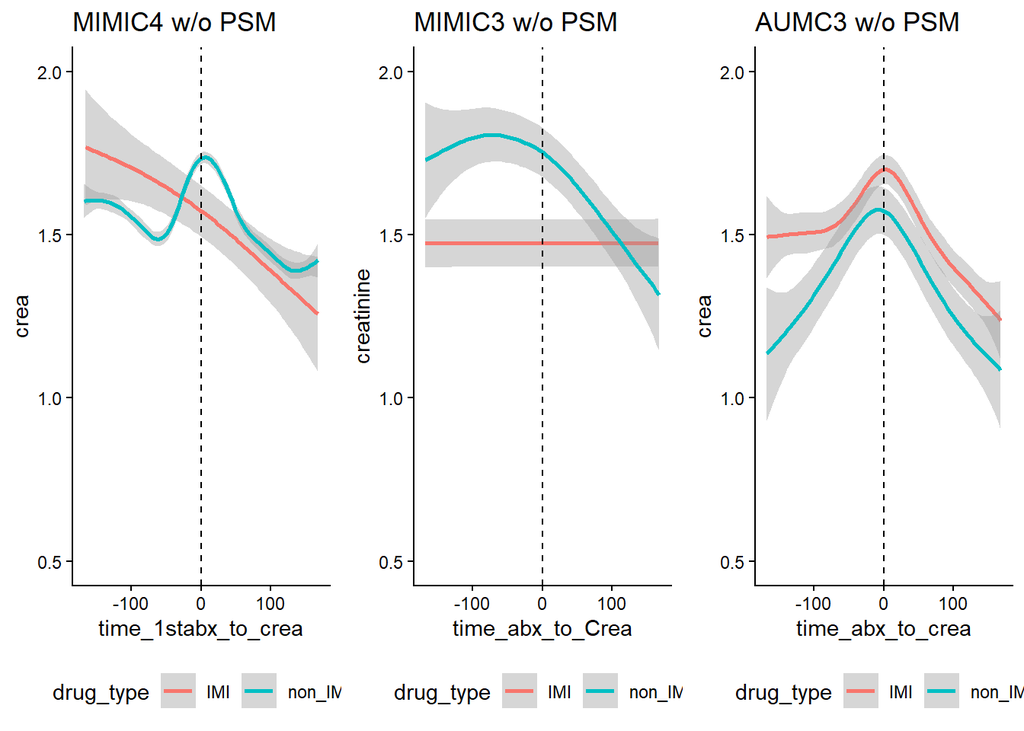

```r
#creatinine change from 1st-penem (before PSM)
creatinine_c <- readRDS("creatinine_c.rds")
m4_crea4 <- readRDS("m4_crea4.rds")
aumc_crea44 <- read_rds("aumc_crea4.rds") %>% left_join(., read.csv("MDF_aumc.csv") %>% dplyr::select(icustay_id, drug_type) %>% rename("admissionid"=icustay_id), by="admissionid")

c0 <- ggplot(m4_crea4, aes(time_1stabx_to_crea, crea, color=drug_type))+theme_classic()+
  geom_smooth()+xlim(c(-168, 168))+theme(legend.position = "bottom")+coord_cartesian(ylim = c(0.5, 2))+geom_vline(xintercept=0, linetype="dashed")+ggtitle("MIMIC4 w/o PSM")
c1 <- ggplot(creatinine_c, aes(time_abx_to_Crea, creatinine, color=drug_type))+theme_classic()+
  geom_smooth()+xlim(c(-168, 168))+theme(legend.position = "bottom")+coord_cartesian(ylim = c(0.5, 2))+geom_vline(xintercept=0, linetype="dashed")+ggtitle("MIMIC3 w/o PSM")
c2 <- ggplot(aumc_crea44 %>% subset(!is.na(drug_type)),
       aes(time_abx_to_crea, crea, color=drug_type))+ theme_classic()+
  geom_smooth()+xlim(c(-168, 168))+theme(legend.position = "bottom")+coord_cartesian(ylim = c(0.5, 2))+geom_vline(xintercept=0, linetype="dashed")+ggtitle("AUMC3 w/o PSM")
gridExtra::grid.arrange(c0, c1, c2, nrow=1)
```

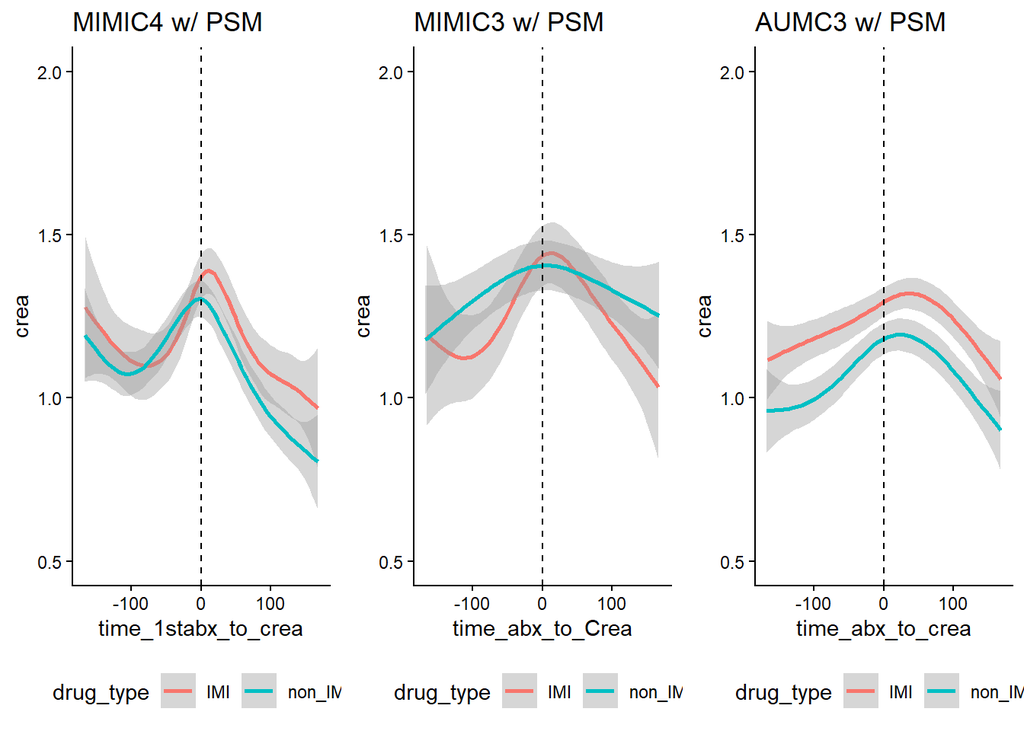

```r
#creatinine change from 1st-penem (after PSM)
c3 <- ggplot(m4_crea4 %>% subset(hadm_id %in% matched_MIMIC4_DF$ID), aes(time_1stabx_to_crea, crea, color=drug_type))+theme_classic()+
  geom_smooth()+xlim(c(-168, 168))+theme(legend.position = "bottom")+coord_cartesian(ylim = c(0.5, 2))+geom_vline(xintercept=0, linetype="dashed")+ggtitle("MIMIC4 w/ PSM")

c4 <- ggplot(creatinine_c %>% subset(hadm_id %in% matched_MIMIC3_DF$ID) %>% rename("crea"=creatinine), aes(time_abx_to_Crea, crea, color=drug_type))+theme_classic()+geom_smooth()+xlim(c(-168, 168))+theme(legend.position = "bottom")+coord_cartesian(ylim = c(0.5, 2))+geom_vline(xintercept=0, linetype="dashed")+ggtitle("MIMIC3 w/ PSM")

c5 <- ggplot(aumc_crea44 %>% subset(admissionid %in% matched_AUMC_DF$ID) %>% subset(!is.na(drug_type)),
       aes(time_abx_to_crea, crea, color=drug_type))+theme_classic()+
  geom_smooth()+xlim(c(-168, 168))+theme(legend.position = "bottom")+coord_cartesian(ylim = c(0.5, 2))+geom_vline(xintercept=0, linetype="dashed")+ggtitle("AUMC3 w/ PSM")
gridExtra::grid.arrange(c3, c4, c5, nrow=1)
```

####check some eGFR change for notes

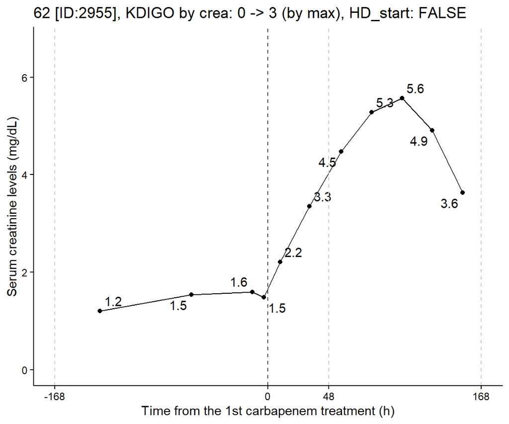

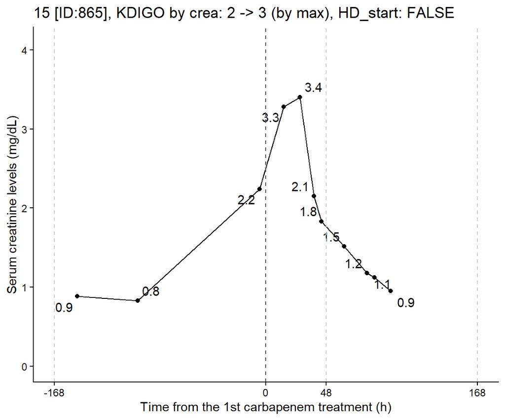

```r
library(ggrepel)
for (i in c(62,15)) {
data_n6 <- aumc_crea44 %>% group_by(admissionid) %>% summarise("count"=n()) %>% filter(count>5)
data <- aumc_crea44 %>% subset(admissionid %in% data_n6$admissionid) %>% subset(admissionid %in% matched_AUMC_DF$ID)
data_one_subject <- data %>% subset(admissionid == data$admissionid %>% unique() %>% .[i])
ID <- data_one_subject$admissionid %>% unique()
g<-ggplot(data_one_subject, aes(time_abx_to_crea, crea))+
  theme_classic()+
  geom_point()+geom_line()+
  geom_text_repel(aes(label = round(crea, digits=1)))+
  xlim(c(-180, 180))+scale_x_continuous(breaks=c(-168,0,48,168))+
  labs(x="Time from the 1st carbapenem treatment (h)", y="Serum creatinine levels (mg/dL)")+
  theme(legend.position = "none", axis.text.x =  element_text("ccc"))+
  coord_cartesian(ylim = c(0, max(data_one_subject$crea)*1.2))+
    geom_vline(xintercept=0, linetype="dashed", color="gray30")+
    geom_vline(xintercept=-168, linetype="dashed", color="gray80")+
      geom_vline(xintercept=48, linetype="dashed", color="gray80")+
      geom_vline(xintercept=168, linetype="dashed", color="gray80")+
  ggtitle(paste0(i," [ID:",ID, "], KDIGO by crea: ", data_one_subject$base_KDIGO_crea, " -> ",
                 max(data_one_subject %>% subset(time_abx_to_crea>0) %>% .$outcome_KDIGO_crea, na.rm = T), " (by max), HD_start: ", comb_DF2 %>% subset(ID %in% 3034) %>% .$outcome_new_dial %>% unique()))
  print(g)
  data_n6
}
```

__

### **3. Overlap weighting**

__

#### 3a. backgrounds and outcome development after overlap weighting

```r
#OVERLAP_PSM
library(WeightIt) #install.packages("WeightIt")
library(PSweight) #install.packages("PSweight")
library(survey) #install.packages("survey")
comb_DF2ovl <- comb_DF2 %>% as.data.frame()# %>% subset(data=="MIMIC3")

FORMULA_ovl <- drug01 ~ age_cat + sex  + dep_type2 + sirs + pre_blood_culture+ nt_drug + vasopressor + base_crea + near_crea + base_KDIGO
FORMULA_ovl2 <- drug01 ~  age_cat + sex + dep_type2 + sirs + pre_blood_culture + nt_drug + vasopressor + base_crea + near_crea +  base_KDIGO
#dig2s <- c("outcome_max_crea_ratio", "outcome_max_crea_diff","base_crea", "near_crea")

#Create function to do calculating PS, weighing, and showing table.
OVLP<-function(DF0, FORM, TITLE, TITLE2){
DF<-DF0
bal_ovlp <- PSweight::SumStat(ps.formula = FORM, data = DF, weight="overlap")
ps_man <- glm(formula = FORM, data=DF, family = binomial) %>% .$fitted.values
wgt_man <- DF %>% mutate(ps_for_IMI = ps_man, ovlp_wgt = case_when(drug01 == 1 ~ (1-ps_man), drug01 == 0 ~ ps_man))
saveRDS(bal_ovlp, paste0("bal_ovlp", TITLE, ".rds"))
saveRDS(wgt_man, paste0("wgt_man_", TITLE, ".rds"))

svydesign(~1, data = wgt_man %>% as.data.frame(), weights = wgt_man$ovlp_wgt) %>% tbl_svysummary(include = VARS, by=drug_type, type = list(CONTIN ~ "continuous"), digits = list(all_categorical() ~ 1, all_continuous() ~ 1), label = l_list) %>%
  add_p(pvalue_fun = label_style_pvalue(digits = 2)) %>%
  modify_header(all_stat_cols() ~ "**{level}** N={style_number(n, scale = 1, digits = 1)}") %>%
  modify_spanning_header(update = all_stat_cols() ~ TITLE2)
}
```

```r
#1. overlap-PSM using MIMIC3
OVLP(comb_DF2ovl %>% subset(dataset=="MIMIC3"), FORMULA_ovl2, "Ovlp_MIMIC3", "**Ovlp, MIMIC-III, base_KDIGO<3**")
```

| **Characteristic** | **Ovlp, MIMIC-III, base_KDIGO<3** **I/C** N=59.6<sup>1</sup> | **Ovlp, MIMIC-III, base_KDIGO<3** **NCC** N=59.6<sup>1</sup> | **p-value**<sup>2</sup> |  |
| --- | --- | --- | --- | --- |
| dataset |  |  |  |  |
| MIMIC3 | 59.6 (100.0%) | 59.6 (100.0%) |  |  |
| age_group |  |  | 0.91 |  |
| 18-39 | 3.3 (5.6%) | 4.4 (7.4%) |  |  |
| 40-49 | 6.2 (10.4%) | 4.9 (8.2%) |  |  |
| 50-59 | 10.6 (17.9%) | 9.9 (16.5%) |  |  |
| 60-69 | 13.1 (22.0%) | 12.3 (20.7%) |  |  |
| 70-79 | 14.0 (23.5%) | 17.1 (28.7%) |  |  |
| 80+ | 12.3 (20.6%) | 11.0 (18.5%) |  |  |
| sex |  |  | >0.99 |  |
| Female | 29.0 (48.7%) | 29.0 (48.7%) |  |  |
| Male | 30.6 (51.3%) | 30.6 (51.3%) |  |  |
| bmi | 27.5 (24.7, 30.6) | 27.8 (23.4, 33.5) | 0.98 |  |
| Unknown | 28 | 31 |  |  |
| weight | 75.8 (66.3, 90.0) | 76.9 (62.5, 95.3) | 0.89 |  |
| Unknown | 8 | 10 |  |  |
| ICU type |  |  | >0.99 |  |
| Non-surgery | 36.3 (60.9%) | 36.3 (60.9%) |  |  |
| Surgery | 23.3 (39.1%) | 23.3 (39.1%) |  |  |
| drug_name |  |  |  |  |
| Imipenem/cilastatin | 59.6 (100.0%) | 0.0 (0.0%) |  |  |
| Imipenem/cilastatin/relebactam | 0.0 (0.0%) | 0.0 (0.0%) |  |  |
| Meropenem | 0.0 (0.0%) | 59.6 (100.0%) |  |  |
| Doripenem | 0.0 (0.0%) | 0.0 (0.0%) |  |  |
| Ertapenem | 0.0 (0.0%) | 0.0 (0.0%) |  |  |
| Overdose in first 24h |  |  | 0.75 |  |
| not_over | 58.8 (98.7%) | 58.5 (98.1%) |  |  |
| over | 0.8 (1.3%) | 1.1 (1.9%) |  |  |
| Relative initiation dose (with near eGFR) | 0.3 (0.2, 0.5) | 0.3 (0.3, 0.5) | 0.055 |  |
| sofa | 5.0 (3.0, 8.0) | 4.0 (2.0, 7.0) | 0.31 |  |
| qsofa | 1.0 (0.0, 1.0) | 1.0 (0.0, 1.0) | 0.85 |  |
| Unknown | 0 | 2 |  |  |
| sirs | 2.0 (1.0, 3.0) | 2.0 (1.0, 3.0) | 0.84 |  |
| pre_blood_culture | 47.7 (80.1%) | 47.7 (80.1%) | >0.99 |  |
| pre nephrotoxic drugs use | 36.2 (60.8%) | 36.2 (60.8%) | >0.99 |  |
| pre vancomycin use | 31.2 (52.4%) | 32.6 (54.8%) | 0.71 |  |
| pre aminoglycosied use | 6.7 (11.3%) | 4.8 (8.1%) | 0.38 |  |
| pre NSAIDs use | 5.9 (9.9%) | 6.8 (11.3%) | 0.72 |  |
| pre contrast agent use | 0.0 (0.0%) | 0.0 (0.0%) |  |  |
| pre vasopressor use | 24.7 (41.4%) | 24.7 (41.4%) | >0.99 |  |
| pre ventilation | 40.5 (67.9%) | 40.3 (67.6%) | 0.95 |  |
| Baseline sCr | 0.9 (0.6, 1.4) | 0.9 (0.6, 1.4) | 0.90 |  |
| sCr at treatment start | 1.1 (0.8, 1.7) | 1.1 (0.7, 1.7) | 0.77 |  |
| AKI stage at treatment start |  |  | >0.99 |  |
| 0 | 44.4 (74.6%) | 44.4 (74.6%) |  |  |
| 1 | 13.5 (22.7%) | 13.5 (22.7%) |  |  |
| 2 | 1.6 (2.7%) | 1.6 (2.7%) |  |  |
| near_eGFR | 63.2 (36.1, 92.3) | 63.1 (38.4, 95.9) | 0.81 |  |
| observation time | 168.0 (168.0, 168.0) | 168.0 (168.0, 168.0) | 0.46 |  |
| Cencsored with drug change | 2.4 (4.0%) | 0.1 (0.2%) | <0.001 |  |
| RRT at treatment start | 0.0 (0.0%) | 0.0 (0.0%) |  |  |
| O, AKI develop/progress | 15.1 (25.4%) | 23.7 (39.8%) | 0.023 |  |
| O, Death | 7.7 (12.9%) | 9.2 (15.4%) | 0.59 |  |
| O, AKI d/p or death | 19.0 (31.9%) | 27.0 (45.3%) | 0.039 |  |
| O, RRT-intervention | 1.5 (2.5%) | 2.9 (4.9%) | 0.37 |  |
| O, Death or RRT-intervention | 8.6 (14.4%) | 11.5 (19.3%) | 0.32 |  |
| total_dose_ICM | 2,500.0 (1,104.6, 3,500.0) | 4,000.0 (2,871.8, 7,000.0) | <0.001 |  |
| total_dose_recabrio | NA (NA, NA) | NA (NA, NA) |  |  |
| Unknown | 60 | 60 |  |  |
| total_dose_erta | NA (NA, NA) | NA (NA, NA) |  |  |
| Unknown | 60 | 60 |  |  |
| total_dose_dori | NA (NA, NA) | NA (NA, NA) |  |  |
| Unknown | 60 | 60 |  |  |
| ini24h_dose_ICM | 500.0 (500.0, 750.0) | 1,000.0 (500.0, 1,000.0) | <0.001 |  |
| ini24h_dose_recabrio | NA (NA, NA) | NA (NA, NA) |  |  |
| Unknown | 60 | 60 |  |  |
| ini24h_dose_erta | NA (NA, NA) | NA (NA, NA) |  |  |
| Unknown | 60 | 60 |  |  |
| ini24h_dose_dori | NA (NA, NA) | NA (NA, NA) |  |  |
| Unknown | 60 | 60 |  |  |
| last_drug_in_obs | 120.0 (48.0, 168.0) | 168.0 (76.4, 168.0) | 0.009 |  |

<sup>1</sup> n (%); Median (Q1, Q3)  
<sup>2</sup> NA; Pearson’s X^2: Rao & Scott adjustment; Design-based KruskalWallis test

```r
#2. overlap-PSM using MIMIC4
OVLP(comb_DF2ovl %>% subset(dataset=="miiv"), FORMULA_ovl2, "Ovlp_MIMIC4", "**Ovlp, MIMIC-IV, base_KDIGO<3**")
```

| **Characteristic** | **Ovlp, MIMIC-IV, base_KDIGO<3** **I/C** N=85.1<sup>1</sup> | **Ovlp, MIMIC-IV, base_KDIGO<3** **NCC** N=85.1<sup>1</sup> | **p-value**<sup>2</sup> |  |
| --- | --- | --- | --- | --- |
| dataset |  |  |  |  |
| miiv | 85.1 (100.0%) | 85.1 (100.0%) |  |  |
| age_group |  |  | 0.61 |  |
| 18-39 | 7.8 (9.1%) | 6.8 (8.0%) |  |  |
| 40-49 | 9.7 (11.4%) | 7.7 (9.1%) |  |  |
| 50-59 | 10.7 (12.5%) | 16.8 (19.7%) |  |  |
| 60-69 | 24.2 (28.4%) | 22.3 (26.2%) |  |  |
| 70-79 | 18.3 (21.5%) | 17.4 (20.4%) |  |  |
| 80+ | 14.4 (17.0%) | 14.2 (16.7%) |  |  |
| sex |  |  | >0.99 |  |
| Female | 36.8 (43.2%) | 36.8 (43.2%) |  |  |
| Male | 48.4 (56.8%) | 48.4 (56.8%) |  |  |
| bmi | 28.1 (25.1, 33.6) | 27.4 (23.5, 33.1) | 0.44 |  |
| Unknown | 43 | 32 |  |  |
| weight | 81.3 (70.4, 98.7) | 78.2 (65.0, 95.0) | 0.16 |  |
| Unknown | 6 | 7 |  |  |
| ICU type |  |  | >0.99 |  |
| Non-surgery | 70.5 (82.8%) | 70.5 (82.8%) |  |  |
| Surgery | 14.7 (17.2%) | 14.7 (17.2%) |  |  |
| drug_name |  |  | <0.001 |  |
| Imipenem/cilastatin | 84.1 (98.9%) | 0.0 (0.0%) |  |  |
| Imipenem/cilastatin/relebactam | 1.0 (1.1%) | 0.0 (0.0%) |  |  |
| Meropenem | 0.0 (0.0%) | 84.6 (99.3%) |  |  |
| Doripenem | 0.0 (0.0%) | 0.2 (0.2%) |  |  |
| Ertapenem | 0.0 (0.0%) | 0.4 (0.5%) |  |  |
| Overdose in first 24h |  |  | 0.99 |  |
| not_over | 84.1 (98.9%) | 84.2 (98.9%) |  |  |
| over | 1.0 (1.1%) | 1.0 (1.1%) |  |  |
| Relative initiation dose (with near eGFR) | 0.3 (0.2, 0.3) | 0.3 (0.3, 0.5) | <0.001 |  |
| sofa | 4.0 (3.0, 8.0) | 5.0 (3.0, 8.0) | 0.22 |  |
| qsofa | 1.0 (0.0, 1.0) | 1.0 (0.0, 1.0) | 0.68 |  |
| Unknown | 0 | 0 |  |  |
| sirs | 2.0 (1.0, 3.0) | 2.0 (1.0, 3.0) | 0.95 |  |
| pre_blood_culture | 65.8 (77.3%) | 65.8 (77.3%) | >0.99 |  |
| pre nephrotoxic drugs use | 66.8 (78.5%) | 66.8 (78.5%) | >0.99 |  |
| pre vancomycin use | 61.0 (71.7%) | 64.2 (75.4%) | 0.42 |  |
| pre aminoglycosied use | 8.7 (10.2%) | 6.9 (8.1%) | 0.48 |  |
| pre NSAIDs use | 5.8 (6.8%) | 6.9 (8.2%) | 0.65 |  |
| pre contrast agent use | 1.0 (1.1%) | 0.9 (1.1%) | 0.99 |  |
| pre vasopressor use | 7.7 (9.1%) | 7.7 (9.1%) | >0.99 |  |
| pre ventilation | 11.6 (13.6%) | 7.3 (8.6%) | 0.10 |  |
| Baseline sCr | 1.0 (0.6, 1.5) | 1.0 (0.6, 1.5) | >0.99 |  |
| sCr at treatment start | 1.1 (0.7, 2.0) | 1.1 (0.7, 1.8) | 0.91 |  |
| AKI stage at treatment start |  |  | 0.98 |  |
| 0 | 64.7 (76.0%) | 64.4 (75.7%) |  |  |
| 1 | 15.5 (18.2%) | 16.1 (19.0%) |  |  |
| 2 | 4.9 (5.7%) | 4.6 (5.4%) |  |  |
| near_eGFR | 62.5 (34.1, 99.5) | 65.8 (36.4, 97.7) | 0.83 |  |
| observation time | 168.0 (122.5, 168.0) | 168.0 (151.6, 168.0) | 0.40 |  |
| Cencsored with drug change | 3.9 (4.5%) | 0.0 (0.0%) | 0.040 |  |
| RRT at treatment start | 0.0 (0.0%) | 0.0 (0.0%) |  |  |
| O, AKI develop/progress | 30.9 (36.3%) | 27.0 (31.7%) | 0.37 |  |
| O, Death | 13.5 (15.9%) | 12.5 (14.6%) | 0.74 |  |
| O, AKI d/p or death | 32.8 (38.5%) | 32.3 (37.9%) | 0.91 |  |
| O, RRT-intervention | 2.9 (3.4%) | 5.7 (6.7%) | 0.22 |  |
| O, Death or RRT-intervention | 14.5 (17.0%) | 16.2 (19.1%) | 0.63 |  |
| total_dose_ICM | 1,770.8 (479.2, 3,479.2) | 2,520.8 (1,187.5, 3,895.8) | <0.001 |  |
| Unknown | 1 | 1 |  |  |
| total_dose_recabrio | NA (NA, NA) | NA (NA, NA) |  |  |
| Unknown | 84 | 85 |  |  |
| total_dose_erta | NA (NA, NA) | NA (NA, NA) |  |  |
| Unknown | 85 | 85 |  |  |
| total_dose_dori | NA (NA, NA) | NA (NA, NA) |  |  |
| Unknown | 85 | 85 |  |  |
| ini24h_dose_ICM | 500.0 (500.0, 500.0) | 1,000.0 (500.0, 1,000.0) | <0.001 |  |
| Unknown | 1 | 1 |  |  |
| ini24h_dose_recabrio | NA (NA, NA) | NA (NA, NA) |  |  |
| Unknown | 84 | 85 |  |  |
| ini24h_dose_erta | NA (NA, NA) | NA (NA, NA) |  |  |
| Unknown | 85 | 85 |  |  |
| ini24h_dose_dori | NA (NA, NA) | NA (NA, NA) |  |  |
| Unknown | 85 | 85 |  |  |
| last_drug_in_obs | 61.0 (25.0, 168.0) | 94.0 (36.0, 168.0) | 0.088 |  |

<sup>1</sup> n (%); Median (Q1, Q3)  
<sup>2</sup> NA; Pearson’s X^2: Rao & Scott adjustment; Design-based KruskalWallis test

```r
#3. overlap-PSM using AUMC
OVLP(comb_DF2ovl %>% subset(dataset=="AUMC"), FORMULA_ovl2, "Ovlp_AUMC", "**Ovlp, AUMC, base_KDIGO<3**")
```

| **Characteristic** | **Ovlp, AUMC, base_KDIGO<3** **I/C** N=144.1<sup>1</sup> | **Ovlp, AUMC, base_KDIGO<3** **NCC** N=144.1<sup>1</sup> | **p-value**<sup>2</sup> |  |
| --- | --- | --- | --- | --- |
| dataset |  |  |  |  |
| AUMC | 144.1 (100.0%) | 144.1 (100.0%) |  |  |
| age_group |  |  | 0.54 |  |
| 18-39 | 16.0 (11.1%) | 20.1 (13.9%) |  |  |
| 40-49 | 15.5 (10.7%) | 15.0 (10.4%) |  |  |
| 50-59 | 32.0 (22.2%) | 25.5 (17.7%) |  |  |
| 60-69 | 45.1 (31.3%) | 41.3 (28.6%) |  |  |
| 70-79 | 29.8 (20.6%) | 36.2 (25.1%) |  |  |
| 80+ | 5.9 (4.1%) | 6.1 (4.2%) |  |  |
| sex |  |  | >0.99 |  |
| Female | 52.5 (36.4%) | 52.5 (36.4%) |  |  |
| Male | 91.6 (63.6%) | 91.6 (63.6%) |  |  |
| bmi | 24.5 (21.9, 27.8) | 24.5 (21.9, 27.8) | 0.41 |  |
| Unknown | 8 | 3 |  |  |
| weight | 75.0 (65.0, 85.0) | 75.0 (65.0, 95.0) | 0.21 |  |
| Unknown | 6 | 3 |  |  |
| ICU type |  |  | >0.99 |  |
| Non-surgery | 85.4 (59.3%) | 85.4 (59.3%) |  |  |
| Surgery | 58.7 (40.7%) | 58.7 (40.7%) |  |  |
| drug_name |  |  |  |  |
| Imipenem/cilastatin | 144.1 (100.0%) | 0.0 (0.0%) |  |  |
| Imipenem/cilastatin/relebactam | 0.0 (0.0%) | 0.0 (0.0%) |  |  |
| Meropenem | 0.0 (0.0%) | 144.1 (100.0%) |  |  |
| Doripenem | 0.0 (0.0%) | 0.0 (0.0%) |  |  |
| Ertapenem | 0.0 (0.0%) | 0.0 (0.0%) |  |  |
| Overdose in first 24h |  |  | 0.92 |  |
| not_over | 143.1 (99.3%) | 143.2 (99.4%) |  |  |
| over | 1.0 (0.7%) | 0.9 (0.6%) |  |  |
| Relative initiation dose (with near eGFR) | 0.3 (0.2, 0.3) | 0.5 (0.3, 0.7) | <0.001 |  |
| sofa | 7.0 (5.0, 9.0) | 7.0 (4.0, 9.0) | 0.67 |  |
| Unknown | 20 | 25 |  |  |
| qsofa | 1.0 (0.0, 1.0) | 1.0 (0.0, 1.0) | 0.87 |  |
| Unknown | 0 | 0 |  |  |
| sirs | 2.0 (2.0, 3.0) | 2.0 (1.0, 3.0) | 0.95 |  |
| pre_blood_culture | 21.3 (14.8%) | 21.3 (14.8%) | >0.99 |  |
| pre nephrotoxic drugs use | 83.0 (57.6%) | 83.0 (57.6%) | >0.99 |  |
| pre vancomycin use | 70.0 (48.5%) | 72.9 (50.6%) | 0.62 |  |
| pre aminoglycosied use | 21.7 (15.0%) | 11.5 (8.0%) | 0.011 |  |
| pre NSAIDs use | 3.0 (2.1%) | 11.0 (7.6%) | <0.001 |  |
| pre contrast agent use | 2.5 (1.8%) | 0.0 (0.0%) | 0.005 |  |
| pre vasopressor use | 91.3 (63.3%) | 91.3 (63.3%) | >0.99 |  |
| pre ventilation | 96.0 (66.6%) | 85.7 (59.5%) | 0.076 |  |
| Baseline sCr | 0.8 (0.6, 1.2) | 0.7 (0.6, 1.1) | 0.21 |  |
| sCr at treatment start | 1.0 (0.7, 1.5) | 0.9 (0.6, 1.5) | 0.27 |  |
| AKI stage at treatment start |  |  | 0.89 |  |
| 0 | 105.2 (73.0%) | 106.1 (73.6%) |  |  |
| 1 | 30.5 (21.2%) | 28.7 (19.9%) |  |  |
| 2 | 8.4 (5.8%) | 9.4 (6.5%) |  |  |
| near_eGFR | 76.6 (48.5, 102.2) | 82.6 (46.1, 107.9) | 0.30 |  |
| observation time | 168.0 (63.7, 168.0) | 162.0 (61.0, 168.0) | 0.75 |  |
| Cencsored with drug change | 4.5 (3.1%) | 1.4 (1.0%) | 0.10 |  |
| RRT at treatment start | 0.0 (0.0%) | 0.0 (0.0%) |  |  |
| O, AKI develop/progress | 43.5 (30.1%) | 41.7 (28.9%) | 0.75 |  |
| O, Death | 19.6 (13.6%) | 19.0 (13.2%) | 0.88 |  |
| O, AKI d/p or death | 50.6 (35.1%) | 50.8 (35.3%) | 0.97 |  |
| O, RRT-intervention | 14.0 (9.7%) | 16.2 (11.3%) | 0.54 |  |
| O, Death or RRT-intervention | 28.6 (19.8%) | 28.1 (19.5%) | 0.91 |  |
| total_dose_ICM | 7,500.0 (3,000.0, 16,000.0) | 11,500.0 (5,000.0, 24,000.0) | <0.001 |  |
| total_dose_recabrio | NA (NA, NA) | NA (NA, NA) |  |  |
| Unknown | 144 | 144 |  |  |
| total_dose_erta | NA (NA, NA) | NA (NA, NA) |  |  |
| Unknown | 144 | 144 |  |  |
| total_dose_dori | NA (NA, NA) | NA (NA, NA) |  |  |
| Unknown | 144 | 144 |  |  |
| ini24h_dose_ICM | 500.0 (500.0, 500.0) | 1,000.0 (1,000.0, 2,000.0) | <0.001 |  |
| ini24h_dose_recabrio | NA (NA, NA) | NA (NA, NA) |  |  |
| Unknown | 144 | 144 |  |  |
| ini24h_dose_erta | NA (NA, NA) | NA (NA, NA) |  |  |
| Unknown | 144 | 144 |  |  |
| ini24h_dose_dori | NA (NA, NA) | NA (NA, NA) |  |  |
| Unknown | 144 | 144 |  |  |
| last_drug_in_obs | 96.0 (36.0, 168.0) | 84.0 (32.0, 168.0) | 0.23 |  |

<sup>1</sup> n (%); Median (Q1, Q3)  
<sup>2</sup> NA; Pearson’s X^2: Rao & Scott adjustment; Design-based KruskalWallis test

```r
#check smd using CreateTableOne package
library(tableone)
library(survey)
library(dplyr)
CreateTableOne(strata = "drug_type", data = readRDS("wgt_man_Ovlp_MIMIC3.rds")) %>% print(smd=T)
```

```
##                                             Stratified by drug_type
##                                              I/C
##   n                                                 77
##   dataset = MIMIC3 (%)                              77 (100.0)
##   age_cat (mean (SD))                            66.17 (15.34)
##   age_group (%)
##      18-39                                           4 (  5.2)
##      40-49                                           8 ( 10.4)
##      50-59                                          13 ( 16.9)
##      60-69                                          17 ( 22.1)
##      70-79                                          18 ( 23.4)
##      80+                                            17 ( 22.1)
##   sex = Male (%)                                    39 ( 50.6)
##   bmi (mean (SD))                                29.20 (7.65)
##   weight (mean (SD))                             81.66 (27.25)
##   drug_type = NCC (%)                                0 (  0.0)
##   Imipenem.Cilastatin (mean (SD))                 1.66 (0.90)
##   Imipenem.Cilastatin.Relebactam (mean (SD))      0.00 (0.00)
##   time_switch_group (mean (SD))                 163.95 (20.38)
##   dep_type = surg (%)                               32 ( 41.6)
##   time_ICUadmit_to_abx (mean (SD))              140.60 (209.49)
##   pre_blood_culture = TRUE (%)                      60 ( 77.9)
##   nt_drug = TRUE (%)                                43 ( 55.8)
##   treat_van = TRUE (%)                              37 ( 48.1)
##   treat_AG = TRUE (%)                                8 ( 10.4)
##   treat_NSAIDs = TRUE (%)                            7 (  9.1)
##   treat_RADIOC = FALSE (%)                          77 (100.0)
##   vasopressor = TRUE (%)                            30 ( 39.0)
##   ventilation = TRUE (%)                            52 ( 67.5)
##   sofa (mean (SD))                                5.38 (3.57)
##   qsofa (mean (SD))                               0.71 (0.67)
##   sirs (mean (SD))                                1.90 (1.07)
##   sep3 = TRUE (%)                                   41 ( 53.2)
##   base_crea (mean (SD))                           1.16 (0.77)
##   near_crea (mean (SD))                           1.36 (0.84)
##   base_KDIGO (mean (SD))                          0.27 (0.50)
##   obs_period (mean (SD))                        149.68 (37.93)
##   base_KDIGO_dial = FALSE (%)                       77 (100.0)
##   outcome_KDIGO (mean (SD))                       0.43 (0.85)
##   outcome_new_dial = TRUE (%)                        2 (  2.6)
```

[output cut: 155 more lines]

```
##   outcome_HDD_in7d = TRUE (%)                 0.164
##   drug_name (%)                                 NaN
##      Imipenem/cilastatin
##      Imipenem/cilastatin/relebactam
##      Meropenem
##      Doripenem
##      Ertapenem
##   eGFR_a (mean (SD))                          0.107
##   eGFR_k (mean (SD))                          0.107
##   eGFR_t (mean (SD))                          0.107
##   near_eGFR (mean (SD))                       0.156
##   dose_status = over (%)                      0.018
##   dose_status2 (mean (SD))                    0.118
##   ps_for_IMI (mean (SD))                      0.522
##   ovlp_wgt (mean (SD))                        6.621
```

__

#### 3b. checking matching/weighting quality

```r
#Checking ROC
#roc(readRDS("wgt_man_Ovlp_MIMIC3.rds")$treat, readRDS("wgt_man_Ovlp_MIMIC3.rds")$ps_for_IMI)%>%auc()%>%round(.,digits = 2)%>%paste0("ovlp_AUC (MIMIC-III) = ", .)
#roc(readRDS("wgt_man_Ovlp_MIMIC4.rds")$treat, readRDS("wgt_man_Ovlp_MIMIC4.rds")$ps_for_IMI)%>%auc()%>%round(.,digits = 2)%>%paste0("ovlp_AUC (MIMIC-IV) = ", .)
#roc(readRDS("wgt_man_Ovlp_AUMC.rds")$treat, readRDS("wgt_man_Ovlp_AUMC.rds")$ps_for_IMI) %>%auc()%>%round(., digits = 2)%>%paste0("ovlp_AUC (AUMC) = ", .)

#Checking histogram of propensity score
HISTO <- function(DF, TITLE, MARK){
ggplot(DF, aes(ps_for_IMI, group = drug_type, fill=drug_type))+
    geom_histogram(color="black", data = DF %>% subset(drug_type=="I/C"), aes(y=..count..))+
    geom_histogram(color="black", data = DF %>% subset(drug_type!="I/C"), aes(y=-..count..))+
    theme_classic()+
    labs(title =  TITLE, x="Propensity score for I/C group", y="Counts")+
    theme(plot.title = element_text(size = 14, hjust = 0), axis.title.x = element_text(size=10.5))}

tiff("eFigure 1 (histogram).tif", res = 300, width = 8, height = 6, units = "in", compression = "lzw")
gridExtra::grid.arrange(
  HISTO(readRDS("wgt_man_Ovlp_MIMIC3.rds"), "(a) MIMIC-III"),
  HISTO(readRDS("wgt_man_Ovlp_MIMIC4.rds"), "(b) MIMIC-IV"),
  HISTO(readRDS("wgt_man_Ovlp_AUMC.rds"), "(c) AUMC"), nrow=2)
dev.off()
```

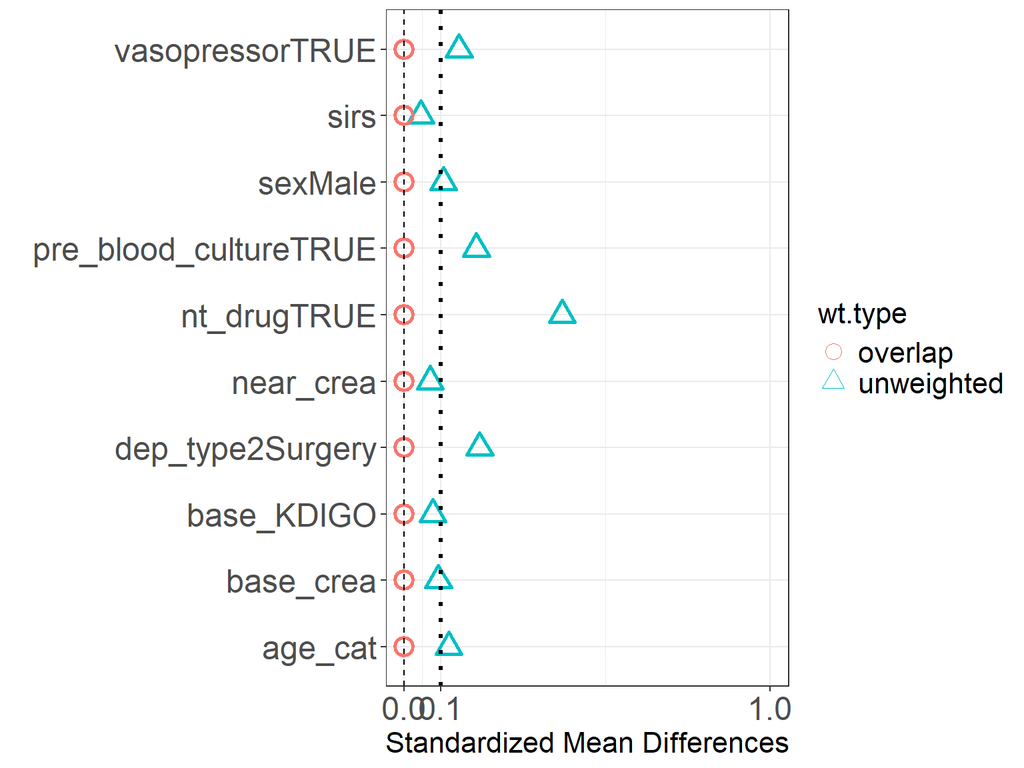

```r
#Checking SMD
plot(readRDS("bal_ovlpOvlp_MIMIC3.rds"), type="balance", threshold=0.1)
```

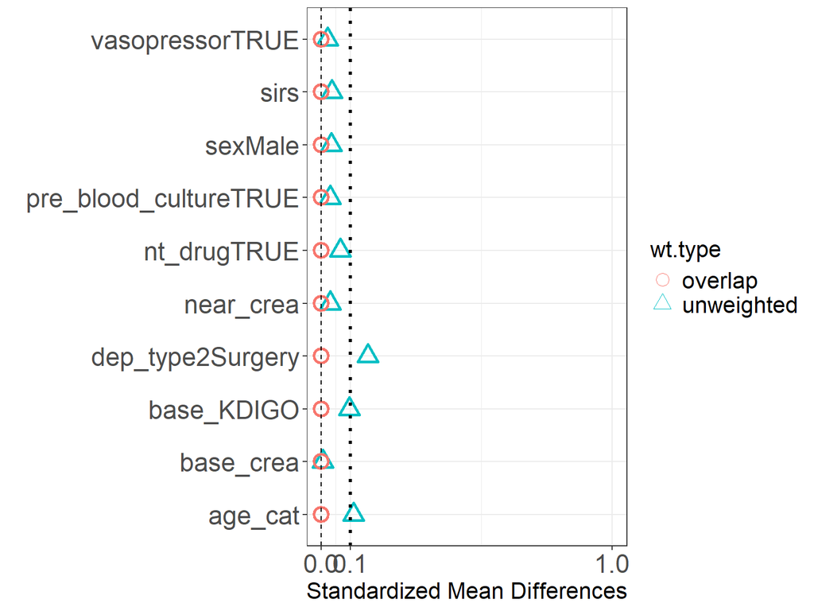

```r
plot(readRDS("bal_ovlpOvlp_MIMIC4.rds"), type="balance")
```

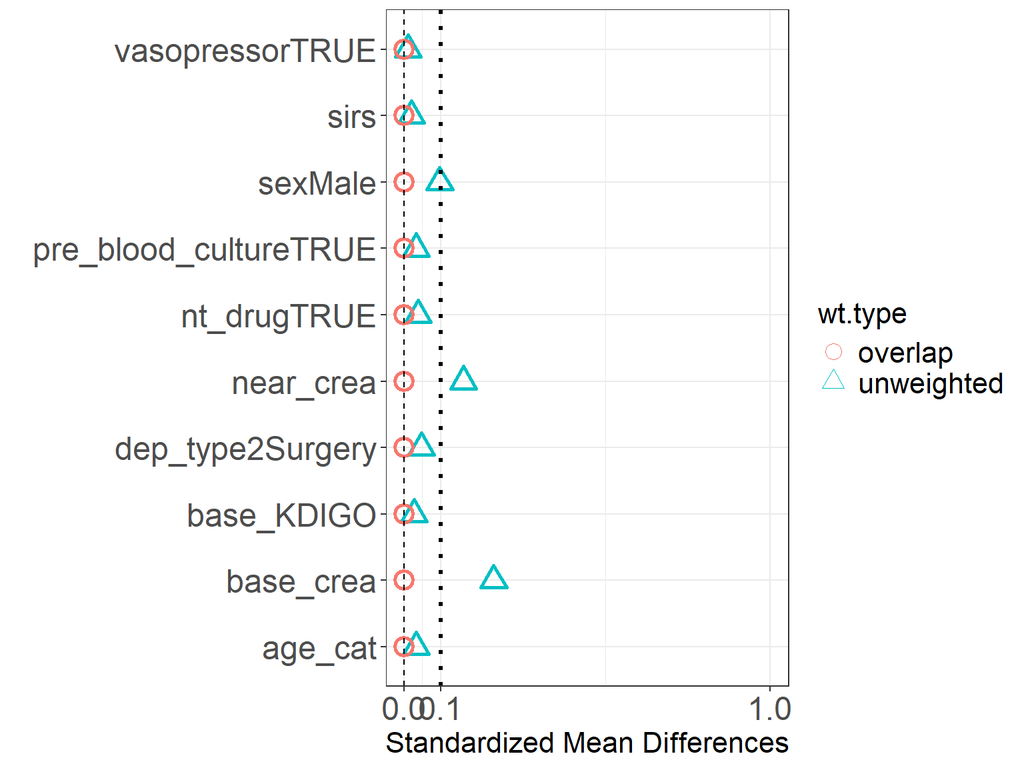

```r
plot(readRDS("bal_ovlpOvlp_AUMC.rds"), type="balance")
```

_

#### 3c. Forest plot of the primary outcomes in each dataset and of overall result

_

```r
#calculating Odds ratio of I/C group in each dataset (not needed)
library(forestplot)
OVLP_OR <- function(DF, FORM, OUTCOME, TITLE){
est_ovlp <- PSweight(ps.formula = FORM, yname = OUTCOME, data = DF, weight = "overlap")
summary1 <- est_ovlp %>% summary(type="OR") %>% .$estimates %>% as.data.frame() %>%
  mutate(
      OR = exp(Estimate),
      LCI = exp(lwr),
      UCI = exp(upr),
      study = TITLE,
      outcome = OUTCOME
  )
svy_design <- svydesign(~1, data = DF %>% as.data.frame(), weights = DF$ovlp_wgt)
fmla <- as.formula(paste("~", OUTCOME))
summary1 <- summary1 %>% mutate("pts"= svytable(fmla, svy_design) %>% as.data.frame() %>% .$Freq %>% sum(),
                                "events"=svytable(fmla, svy_design) %>% as.data.frame() %>% filter(.data[[OUTCOME]]==T) %>% .$Freq %>% sum())
summary1
}
```

```r
#calculating Odds ratio of I/C group in each dataset
FP2 <- function(RDS, FORM){
OR_RES <- rbind(
  OVLP_OR(readRDS(RDS), FORM, "outcome_KDIGO_inc_or_death", "AKI progression or death"),
  OVLP_OR(readRDS(RDS), FORM, "outcome_KDIGO_inc", "AKI progression"),
  OVLP_OR(readRDS(RDS), FORM, "outcome_new_dial", "Hemodialysis"),
  OVLP_OR(readRDS(RDS), FORM, "death_in_7d", "Death"),
  OVLP_OR(readRDS(RDS), FORM, "outcome_HDD_in7d", "Hemodialysis or death")) %>%
  mutate("events_percentage"=events/sum(.$event), "pts_percentage"=pts/sum(.$pts))
saveRDS(OR_RES, paste0("ORRES_",RDS))
}

FP2("wgt_man_Ovlp_MIMIC4.rds", FORMULA_ovl2)
FP2("wgt_man_Ovlp_MIMIC3.rds", FORMULA_ovl2)
FP2("wgt_man_Ovlp_AUMC.rds", FORMULA_ovl2)
```

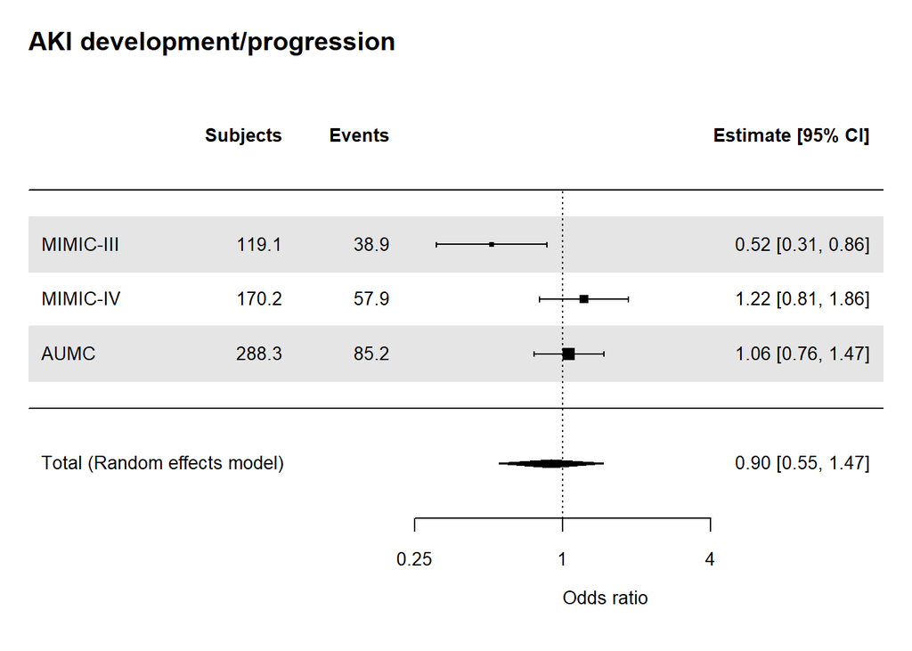

```r
#Pool the results of each dataset with Random Mixed effect meta-analysis
METADF0 <- rbind(
  readRDS("ORRES_wgt_man_Ovlp_MIMIC3.rds") %>% mutate("dataset"="MIMIC-III"),
  readRDS("ORRES_wgt_man_Ovlp_MIMIC4.rds") %>% mutate("dataset"="MIMIC-IV"),
  readRDS("ORRES_wgt_man_Ovlp_AUMC.rds") %>% mutate("dataset"="AUMC"))
METADF_AKID <- METADF0 %>% subset(outcome=="outcome_KDIGO_inc_or_death")
METADF_AKI <- METADF0 %>% subset(outcome=="outcome_KDIGO_inc")
METADF_HD <- METADF0 %>% subset(outcome=="outcome_new_dial")
METADF_D <- METADF0 %>% subset(outcome=="death_in_7d")
METADF_HDD <- METADF0 %>% subset(outcome=="outcome_HDD_in7d")


library(metafor)
METARES_AKID <- rma(yi = Estimate, sei = Std.Error, method = "REML", data = METADF_AKID)
METARES_AKI <-rma(yi = Estimate, sei = Std.Error, method = "REML", data = METADF_AKI)
METARES_HD <-rma(yi = Estimate, sei = Std.Error, method = "REML", data = METADF_HD)
METARES_D <-rma(yi = Estimate, sei = Std.Error, method = "REML", data = METADF_D)
METARES_HDD <-rma(yi = Estimate, sei = Std.Error, method = "REML", data = METADF_HDD)

METAF <- function(METARES, AAA, BBB, CCC, TITLE){
metafor::forest(METARES,  atransf=exp, at=log(AAA), slab = dataset,
       xlim=BBB,
       ilab=cbind(round(pts, digits=1), round(events, digits=1)),
       ilab.lab=c("Subjects","Events"), ilab.pos = 2, ilab.xpos=CCC,
       cex=0.85, header="", xlab="Odds ratio", mlab="Total (Random effects model)", shade=TRUE,
       main=TITLE, adj=0)
}
SCALEA1<-c(0.25, 1, 4)
SCALEB1 <- c(-5,3)
SCALEC1 <- c(-2.5,-1.5)
#
METAF(METARES_AKI, SCALEA1, SCALEB1, SCALEC1, "AKI development/progression")
```

```r
METARES_AKI #details of the overall analysis results
```

```
##
## Random-Effects Model (k = 3; tau^2 estimator: REML)
##
## tau^2 (estimated amount of total heterogeneity): 0.1417 (SE = 0.1882)
## tau (square root of estimated tau^2 value):      0.3764
## I^2 (total heterogeneity / total variability):   76.07%
## H^2 (total variability / sampling variability):  4.18
##
## Test for Heterogeneity:
## Q(df = 2) = 7.2086, p-val = 0.0272
##
## Model Results:
##
## estimate      se     zval    pval    ci.lb   ci.ub
##  -0.1071  0.2502  -0.4281  0.6686  -0.5975  0.3833
##
## ---
## Signif. codes:  0 '***' 0.001 '**' 0.01 '*' 0.05 '.' 0.1 ' ' 1
```

```r
METADF_AKI %>% dplyr::select(dataset, OR, LCI, UCI, 'Pr(>|z|)') %>% remove_rownames()
```

```
##     dataset       OR       LCI       UCI   Pr(>|z|)
## 1 MIMIC-III 0.515187 0.3069850 0.8645951 0.01204724
## 2  MIMIC-IV 1.224240 0.8067443 1.8577913 0.34171671
## 3      AUMC 1.059972 0.7638726 1.4708470 0.72749894
```

```r
tiff("Figure 2 (primary).tif", res = 300, width = 6, height = 4, units = "in", compression = "lzw")
METAF(METARES_AKI, SCALEA1, SCALEB1, SCALEC1, "AKI development/progression")
dev.off()
```

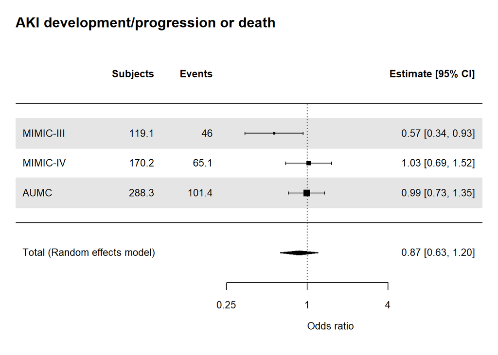

```r
METAF(METARES_AKID, SCALEA1, SCALEB1, SCALEC1, "AKI development/progression or death")
```

```r
tiff("eFigure 3 (sensitivity).tif", res = 300, width = 6, height = 4, units = "in", compression = "lzw")
METAF(METARES_AKID, SCALEA1, SCALEB1, SCALEC1, "AKI development/progression or death")
dev.off()
```

```r
METARES_AKID
```

```
##
## Random-Effects Model (k = 3; tau^2 estimator: REML)
##
## tau^2 (estimated amount of total heterogeneity): 0.0423 (SE = 0.0834)
## tau (square root of estimated tau^2 value):      0.2057
## I^2 (total heterogeneity / total variability):   51.25%
## H^2 (total variability / sampling variability):  2.05
##
## Test for Heterogeneity:
## Q(df = 2) = 4.0956, p-val = 0.1290
##
## Model Results:
##
## estimate      se     zval    pval    ci.lb   ci.ub
##  -0.1401  0.1660  -0.8444  0.3984  -0.4654  0.1851
##
## ---
## Signif. codes:  0 '***' 0.001 '**' 0.01 '*' 0.05 '.' 0.1 ' ' 1
```

```r
METADF_AKID %>% dplyr::select(dataset, OR, LCI, UCI, 'Pr(>|z|)') %>% remove_rownames()
```

```
##     dataset        OR       LCI       UCI   Pr(>|z|)
## 1 MIMIC-III 0.5668421 0.3437958 0.9345952 0.02607469
## 2  MIMIC-IV 1.0256741 0.6905343 1.5234688 0.90006273
## 3      AUMC 0.9927838 0.7304083 1.3494091 0.96311021
```

#### 3d. Forest plot of the secondary outcomes

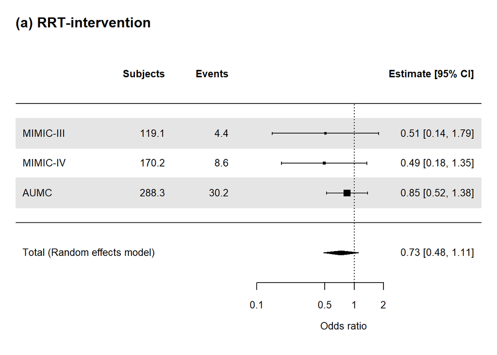

```r
SCALEA2<-c(0.1, 0.5, 1, 2)
SCALEB2 <- c(-8,3)
SCALEC2 <- c(-4.3,-2.8)
METAF(METARES_HD, SCALEA2, SCALEB2, SCALEC2, "(a) RRT-intervention")
```

```r
METARES_HD
```

```
##
## Random-Effects Model (k = 3; tau^2 estimator: REML)
##
## tau^2 (estimated amount of total heterogeneity): 0 (SE = 0.1895)
## tau (square root of estimated tau^2 value):      0
## I^2 (total heterogeneity / total variability):   0.00%
## H^2 (total variability / sampling variability):  1.00
##
## Test for Heterogeneity:
## Q(df = 2) = 1.2574, p-val = 0.5333
##
## Model Results:
##
## estimate      se     zval    pval    ci.lb   ci.ub
##  -0.3130  0.2111  -1.4823  0.1383  -0.7268  0.1008
##
## ---
## Signif. codes:  0 '***' 0.001 '**' 0.01 '*' 0.05 '.' 0.1 ' ' 1
```

```r
METADF_HD %>% dplyr::select(dataset, OR, LCI, UCI, 'Pr(>|z|)') %>% remove_rownames()
```

```
##     dataset        OR       LCI      UCI  Pr(>|z|)
## 1 MIMIC-III 0.5071989 0.1438790 1.787966 0.2909541
## 2  MIMIC-IV 0.4922443 0.1789575 1.353978 0.1697691
## 3      AUMC 0.8460419 0.5203555 1.375573 0.5002105
```

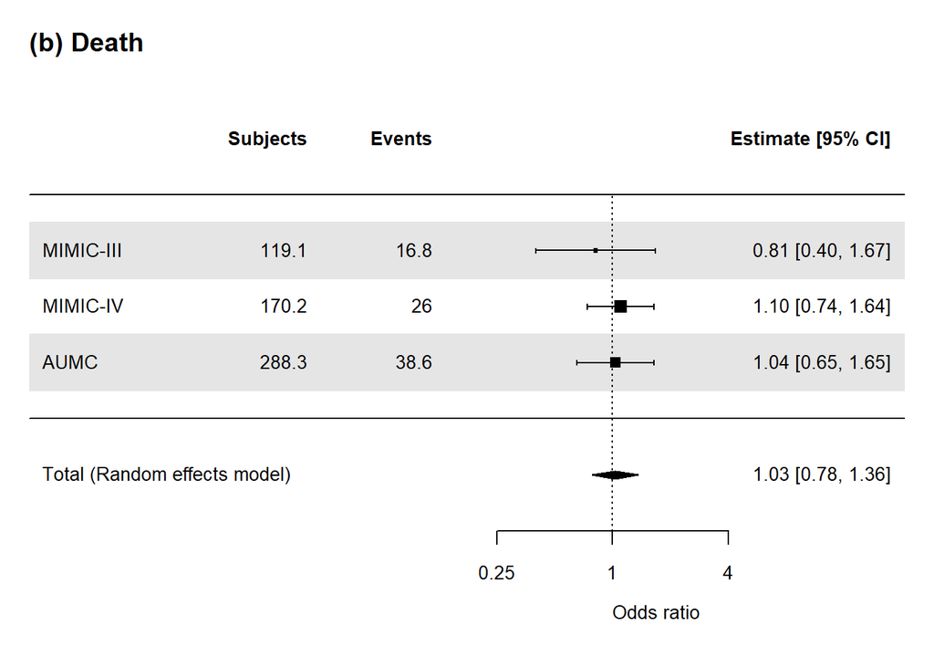

```r
SCALEA3<-c(0.25, 1, 4)
SCALEB3 <- c(-7,3.5)
SCALEC3 <- c(-3.5,-2)
METAF(METARES_D, SCALEA3, SCALEB3, SCALEC3, "(b) Death")
```

```r
METARES_D
```

```
##
## Random-Effects Model (k = 3; tau^2 estimator: REML)
##
## tau^2 (estimated amount of total heterogeneity): 0 (SE = 0.0619)
## tau (square root of estimated tau^2 value):      0
## I^2 (total heterogeneity / total variability):   0.00%
## H^2 (total variability / sampling variability):  1.00
##
## Test for Heterogeneity:
## Q(df = 2) = 0.5230, p-val = 0.7699
##
## Model Results:
##
## estimate      se    zval    pval    ci.lb   ci.ub
##   0.0294  0.1418  0.2075  0.8356  -0.2486  0.3074
##
## ---
## Signif. codes:  0 '***' 0.001 '**' 0.01 '*' 0.05 '.' 0.1 ' ' 1
```

```r
METADF_D %>% dplyr::select(dataset, OR, LCI, UCI, 'Pr(>|z|)') %>% remove_rownames()
```

```
##     dataset        OR       LCI      UCI  Pr(>|z|)
## 1 MIMIC-III 0.8147272 0.3980643 1.667520 0.5749974
## 2  MIMIC-IV 1.1019697 0.7402329 1.640480 0.6324361
## 3      AUMC 1.0363539 0.6525531 1.645888 0.8797380
```

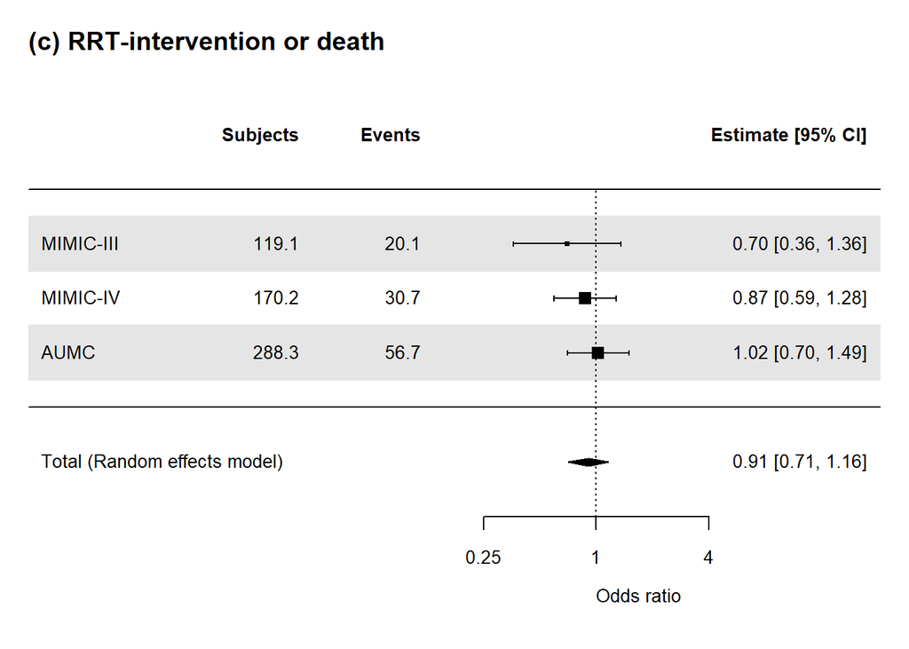

```r
SCALEA3<-c(0.25, 1, 4)
SCALEB3 <- c(-7,3.5)
SCALEC3 <- c(-3.5,-2)
METAF(METARES_HDD, SCALEA3, SCALEB3, SCALEC3, "(c) RRT-intervention or death")
```

```r
METARES_HDD
```

```
##
## Random-Effects Model (k = 3; tau^2 estimator: REML)
##
## tau^2 (estimated amount of total heterogeneity): 0 (SE = 0.0490)
## tau (square root of estimated tau^2 value):      0
## I^2 (total heterogeneity / total variability):   0.00%
## H^2 (total variability / sampling variability):  1.00
##
## Test for Heterogeneity:
## Q(df = 2) = 1.0271, p-val = 0.5984
##
## Model Results:
##
## estimate      se     zval    pval    ci.lb   ci.ub
##  -0.0988  0.1271  -0.7772  0.4370  -0.3479  0.1503
##
## ---
## Signif. codes:  0 '***' 0.001 '**' 0.01 '*' 0.05 '.' 0.1 ' ' 1
```

```r
METADF_HDD %>% dplyr::select(dataset, OR, LCI, UCI, 'Pr(>|z|)') %>% remove_rownames()
```

```
##     dataset        OR       LCI      UCI  Pr(>|z|)
## 1 MIMIC-III 0.6989876 0.3597543 1.358104 0.2906251
## 2  MIMIC-IV 0.8713250 0.5947290 1.276560 0.4796381
## 3      AUMC 1.0237346 0.7014237 1.494150 0.9032191
```

```r
#export
tiff("Figure 3 (secondary).tif",
     width = 5,
     height = 7,     # Tall file to fit 3 plots vertically
     units = "in",
     res = 300,
     compression = "lzw")
par(mfrow = c(3, 1))
METAF(METARES_HD, SCALEA2, SCALEB2, SCALEC2, "(a) RRT-intervention")
METAF(METARES_D, SCALEA3, SCALEB3, SCALEC3, "(b) Death")
METAF(METARES_HDD, SCALEA3, SCALEB3, SCALEC3, "(c) RRT-intervention or death")
dev.off()
```

__

__

### **4. Stratified analysis**

**Stratified by AKI stage at treatment start (stage 0 vs stage 1or2)**

Stratify first, then calculate propensity score and perform overlap weighting.

__

#### 4a. Background and outcome in subgroups before matching.

```r
###base_KDIGO=0 before PSOW
#MIMIC3
#tbl_summary(comb_DF2 %>% subset(dataset=="MIMIC3"&base_KDIGO==0), by=drug_type, include = c(VARS, outcome_KDIGO_inc), type = list(qsofa ~ "continuous", sirs~ "continuous")) %>% add_p(pvalue_fun = label_style_pvalue(digits = 2)) %>% modify_spanning_header(update = all_stat_cols() ~ "**MIMIC-III, base_KDIGO=0**")
#MIMIC4
#tbl_summary(comb_DF2 %>% subset(dataset=="miiv"&base_KDIGO==0), by=drug_type, include = c(VARS, outcome_KDIGO_inc), type = list(qsofa ~ "continuous", sirs~ "continuous")) %>% add_p(pvalue_fun = label_style_pvalue(digits = 2)) %>% modify_spanning_header(update = all_stat_cols() ~ "**MIMIC-IV, base_KDIGO=0**")
#AUMC
#tbl_summary(comb_DF2 %>% subset(dataset=="AUMC"&base_KDIGO==0), by=drug_type, include = c(VARS, outcome_KDIGO_inc), type = list(qsofa ~ "continuous", sirs~ "continuous")) %>% modify_spanning_header(update = all_stat_cols() ~ "**AUMC, base_KDIGO=0**") %>% add_p(pvalue_fun = label_style_pvalue(digits = 2))
```

__

#### 4b. Background and outcome among those with AKI at treatment start before matching (Hidden).

```r
###base_KDIGO=1or2 before PSOW
#MIMIC3
#tbl_summary(comb_DF2 %>% subset(dataset=="MIMIC3"&base_KDIGO!=0), by=drug_type, include = c(VARS, outcome_KDIGO_inc), type = list(qsofa ~ "continuous", sirs~ "continuous")) %>% add_p(pvalue_fun = label_style_pvalue(digits = 2)) %>% modify_spanning_header(update = all_stat_cols() ~ "**MIMIC-III, base_KDIGO=1,2**")
#MIMIC4
#tbl_summary(comb_DF2 %>% subset(dataset=="miiv"&base_KDIGO!=0), by=drug_type, include = c(VARS, outcome_KDIGO_inc), type = list(qsofa ~ "continuous", sirs~ "continuous")) %>% add_p(pvalue_fun = label_style_pvalue(digits = 2)) %>% modify_spanning_header(update = all_stat_cols() ~ "**MIMIC-IV, base_KDIGO=1,2**")
#AUMC
#tbl_summary(comb_DF2 %>% subset(dataset=="AUMC"&base_KDIGO!=0), by=drug_type, include = c(VARS, outcome_KDIGO_inc), type = list(qsofa ~ "continuous", sirs~ "continuous")) %>% modify_spanning_header(update = all_stat_cols() ~ "**AUMC, base_KDIGO=1,2**") %>% add_p(pvalue_fun = label_style_pvalue(digits = 2))
```

__

#### 4c. Backgrounds, outcomes, matching quality, and forrest plot among those without AKI at treatment start.

```r
#3. overlap-PSM using MIMIC3, base KDIGO=0
OVLP(comb_DF2ovl %>% subset(dataset=="MIMIC3"&base_KDIGO==0), FORMULA_ovl2, "Ovlp_MIMIC3_base0", "**Ovlp, MIMIC-III, base_KDIGO=0**")
```

| **Characteristic** | **Ovlp, MIMIC-III, base_KDIGO=0** **I/C** N=44.2<sup>1</sup> | **Ovlp, MIMIC-III, base_KDIGO=0** **NCC** N=44.2<sup>1</sup> | **p-value**<sup>2</sup> |  |
| --- | --- | --- | --- | --- |
| dataset |  |  |  |  |
| MIMIC3 | 44.2 (100.0%) | 44.2 (100.0%) |  |  |
| age_group |  |  | 0.71 |  |
| 18-39 | 2.5 (5.7%) | 3.6 (8.1%) |  |  |
| 40-49 | 5.4 (12.2%) | 3.5 (7.9%) |  |  |
| 50-59 | 8.0 (18.1%) | 7.5 (17.0%) |  |  |
| 60-69 | 9.1 (20.5%) | 8.9 (20.1%) |  |  |
| 70-79 | 9.1 (20.7%) | 12.8 (28.9%) |  |  |
| 80+ | 10.1 (22.8%) | 8.0 (18.1%) |  |  |
| sex |  |  | >0.99 |  |
| Female | 20.2 (45.6%) | 20.2 (45.6%) |  |  |
| Male | 24.0 (54.4%) | 24.0 (54.4%) |  |  |
| bmi | 27.6 (24.5, 31.6) | 27.5 (23.1, 32.9) | 0.56 |  |
| Unknown | 20 | 21 |  |  |
| weight | 78.7 (69.0, 92.0) | 75.0 (61.7, 93.0) | 0.26 |  |
| Unknown | 5 | 6 |  |  |
| ICU type |  |  | >0.99 |  |
| Non-surgery | 23.7 (53.6%) | 23.7 (53.6%) |  |  |
| Surgery | 20.5 (46.4%) | 20.5 (46.4%) |  |  |
| drug_name |  |  |  |  |
| Imipenem/cilastatin | 44.2 (100.0%) | 0.0 (0.0%) |  |  |
| Imipenem/cilastatin/relebactam | 0.0 (0.0%) | 0.0 (0.0%) |  |  |
| Meropenem | 0.0 (0.0%) | 44.2 (100.0%) |  |  |
| Doripenem | 0.0 (0.0%) | 0.0 (0.0%) |  |  |
| Ertapenem | 0.0 (0.0%) | 0.0 (0.0%) |  |  |
| Overdose in first 24h |  |  | 0.091 |  |
| not_over | 44.2 (100.0%) | 43.5 (98.4%) |  |  |
| over | 0.0 (0.0%) | 0.7 (1.6%) |  |  |
| Relative initiation dose (with near eGFR) | 0.3 (0.2, 0.5) | 0.3 (0.3, 0.5) | 0.077 |  |
| sofa | 4.0 (3.0, 8.0) | 4.0 (2.0, 7.0) | 0.62 |  |
| qsofa | 1.0 (0.0, 1.0) | 1.0 (0.0, 1.0) | 0.54 |  |
| Unknown | 0 | 1 |  |  |
| sirs | 2.0 (1.0, 3.0) | 2.0 (1.0, 3.0) | 0.94 |  |
| pre_blood_culture | 35.1 (79.5%) | 35.1 (79.5%) | >0.99 |  |
| pre nephrotoxic drugs use | 27.4 (61.9%) | 27.4 (61.9%) | >0.99 |  |
| pre vancomycin use | 22.3 (50.5%) | 25.0 (56.6%) | 0.41 |  |
| pre aminoglycosied use | 6.6 (14.9%) | 3.6 (8.1%) | 0.12 |  |
| pre NSAIDs use | 4.1 (9.4%) | 4.7 (10.7%) | 0.77 |  |
| pre contrast agent use | 0.0 (0.0%) | 0.0 (0.0%) |  |  |
| pre vasopressor use | 18.7 (42.4%) | 18.7 (42.4%) | >0.99 |  |
| pre ventilation | 29.7 (67.1%) | 30.2 (68.2%) | 0.87 |  |
| Baseline sCr | 1.0 (0.6, 1.4) | 0.9 (0.6, 1.5) | 0.64 |  |
| sCr at treatment start | 1.0 (0.8, 1.6) | 1.0 (0.7, 1.6) | 0.59 |  |
| AKI stage at treatment start |  |  |  |  |
| 0 | 44.2 (100.0%) | 44.2 (100.0%) |  |  |
| near_eGFR | 67.1 (45.6, 97.7) | 78.5 (41.5, 100.7) | 0.66 |  |
| observation time | 168.0 (168.0, 168.0) | 168.0 (168.0, 168.0) | 0.71 |  |
| Cencsored with drug change | 1.7 (3.9%) | 0.2 (0.4%) | 0.015 |  |
| RRT at treatment start | 0.0 (0.0%) | 0.0 (0.0%) |  |  |
| O, AKI develop/progress | 14.8 (33.5%) | 22.0 (49.9%) | 0.032 |  |
| O, Death | 5.2 (11.8%) | 7.2 (16.4%) | 0.39 |  |
| O, AKI d/p or death | 16.4 (37.0%) | 24.0 (54.3%) | 0.023 |  |
| O, RRT-intervention | 1.4 (3.2%) | 2.5 (5.7%) | 0.45 |  |
| O, Death or RRT-intervention | 6.1 (13.7%) | 9.2 (20.9%) | 0.23 |  |
| total_dose_ICM | 2,500.0 (1,500.0, 3,500.0) | 4,000.0 (3,000.0, 7,000.0) | <0.001 |  |
| total_dose_recabrio | NA (NA, NA) | NA (NA, NA) |  |  |
| Unknown | 44 | 44 |  |  |
| total_dose_erta | NA (NA, NA) | NA (NA, NA) |  |  |
| Unknown | 44 | 44 |  |  |
| total_dose_dori | NA (NA, NA) | NA (NA, NA) |  |  |
| Unknown | 44 | 44 |  |  |
| ini24h_dose_ICM | 500.0 (500.0, 750.0) | 1,000.0 (500.0, 1,000.0) | <0.001 |  |
| ini24h_dose_recabrio | NA (NA, NA) | NA (NA, NA) |  |  |
| Unknown | 44 | 44 |  |  |
| ini24h_dose_erta | NA (NA, NA) | NA (NA, NA) |  |  |
| Unknown | 44 | 44 |  |  |
| ini24h_dose_dori | NA (NA, NA) | NA (NA, NA) |  |  |
| Unknown | 44 | 44 |  |  |
| last_drug_in_obs | 120.0 (48.0, 168.0) | 168.0 (73.5, 168.0) | 0.011 |  |

<sup>1</sup> n (%); Median (Q1, Q3)  
<sup>2</sup> NA; Pearson’s X^2: Rao & Scott adjustment; Design-based KruskalWallis test

```r
#2. overlap-PSM using MIMIC4, base KDIGO=0
OVLP(comb_DF2ovl %>% subset(dataset=="miiv"&base_KDIGO==0), FORMULA_ovl2, "Ovlp_MIMIC4_base0", "**Ovlp, MIMIC-IV, base_KDIGO=0**")
```

| **Characteristic** | **Ovlp, MIMIC-IV, base_KDIGO=0** **I/C** N=64.7<sup>1</sup> | **Ovlp, MIMIC-IV, base_KDIGO=0** **NCC** N=64.7<sup>1</sup> | **p-value**<sup>2</sup> |  |
| --- | --- | --- | --- | --- |
| dataset |  |  |  |  |
| miiv | 64.7 (100.0%) | 64.7 (100.0%) |  |  |
| age_group |  |  | 0.88 |  |
| 18-39 | 7.7 (12.0%) | 6.8 (10.6%) |  |  |
| 40-49 | 7.7 (12.0%) | 6.5 (10.1%) |  |  |
| 50-59 | 9.7 (14.9%) | 13.5 (20.9%) |  |  |
| 60-69 | 17.4 (26.9%) | 16.3 (25.3%) |  |  |
| 70-79 | 11.6 (17.9%) | 11.8 (18.2%) |  |  |
| 80+ | 10.6 (16.4%) | 9.6 (14.9%) |  |  |
| sex |  |  | >0.99 |  |
| Female | 28.9 (44.7%) | 28.9 (44.7%) |  |  |
| Male | 35.8 (55.3%) | 35.8 (55.3%) |  |  |
| bmi | 27.1 (24.7, 31.6) | 27.0 (23.3, 32.9) | 0.56 |  |
| Unknown | 32 | 25 |  |  |
| weight | 83.0 (70.4, 99.6) | 77.0 (64.0, 93.6) | 0.031 |  |
| Unknown | 4 | 4 |  |  |
| ICU type |  |  | >0.99 |  |
| Non-surgery | 54.9 (84.9%) | 54.9 (84.9%) |  |  |
| Surgery | 9.8 (15.1%) | 9.8 (15.1%) |  |  |
| drug_name |  |  | <0.001 |  |
| Imipenem/cilastatin | 63.7 (98.5%) | 0.0 (0.0%) |  |  |
| Imipenem/cilastatin/relebactam | 1.0 (1.5%) | 0.0 (0.0%) |  |  |
| Meropenem | 0.0 (0.0%) | 64.1 (99.2%) |  |  |
| Doripenem | 0.0 (0.0%) | 0.2 (0.3%) |  |  |
| Ertapenem | 0.0 (0.0%) | 0.4 (0.6%) |  |  |
| Overdose in first 24h |  |  | 0.64 |  |
| not_over | 63.7 (98.5%) | 64.1 (99.1%) |  |  |
| over | 1.0 (1.5%) | 0.6 (0.9%) |  |  |
| Relative initiation dose (with near eGFR) | 0.3 (0.2, 0.3) | 0.3 (0.2, 0.5) | <0.001 |  |
| sofa | 4.0 (3.0, 6.0) | 5.0 (3.0, 7.0) | 0.54 |  |
| qsofa | 1.0 (0.0, 1.0) | 1.0 (0.0, 1.0) | 0.49 |  |
| Unknown | 0 | 0 |  |  |
| sirs | 2.0 (1.0, 3.0) | 2.0 (1.0, 3.0) | 0.97 |  |
| pre_blood_culture | 49.2 (76.0%) | 49.2 (76.0%) | >0.99 |  |
| pre nephrotoxic drugs use | 51.2 (79.2%) | 51.2 (79.2%) | >0.99 |  |
| pre vancomycin use | 46.4 (71.7%) | 49.0 (75.7%) | 0.45 |  |
| pre aminoglycosied use | 3.9 (6.0%) | 5.9 (9.1%) | 0.38 |  |
| pre NSAIDs use | 3.9 (6.0%) | 5.7 (8.9%) | 0.41 |  |
| pre contrast agent use | 1.0 (1.5%) | 0.5 (0.8%) | 0.57 |  |
| pre vasopressor use | 3.8 (5.9%) | 3.8 (5.9%) | >0.99 |  |
| pre ventilation | 6.7 (10.4%) | 3.7 (5.8%) | 0.12 |  |
| Baseline sCr | 0.9 (0.6, 1.5) | 0.9 (0.6, 1.4) | 0.92 |  |
| sCr at treatment start | 1.0 (0.6, 1.5) | 0.9 (0.6, 1.4) | 0.90 |  |
| AKI stage at treatment start |  |  |  |  |
| 0 | 64.7 (100.0%) | 64.7 (100.0%) |  |  |
| near_eGFR | 84.4 (47.0, 107.3) | 81.7 (48.2, 104.5) | 0.88 |  |
| observation time | 168.0 (122.5, 168.0) | 168.0 (142.7, 168.0) | 0.44 |  |
| Cencsored with drug change | 3.9 (6.0%) | 0.0 (0.0%) | 0.038 |  |
| RRT at treatment start | 0.0 (0.0%) | 0.0 (0.0%) |  |  |
| O, AKI develop/progress | 22.2 (34.3%) | 17.1 (26.5%) | 0.16 |  |
| O, Death | 6.7 (10.4%) | 6.5 (10.0%) | 0.91 |  |
| O, AKI d/p or death | 23.2 (35.8%) | 19.8 (30.6%) | 0.37 |  |
| O, RRT-intervention | 0.0 (0.0%) | 2.4 (3.7%) | <0.001 |  |
| O, Death or RRT-intervention | 6.7 (10.4%) | 8.1 (12.5%) | 0.61 |  |
| total_dose_ICM | 1,770.8 (479.2, 3,458.3) | 2,541.7 (1,250.0, 3,937.5) | <0.001 |  |
| Unknown | 1 | 1 |  |  |
| total_dose_recabrio | NA (NA, NA) | NA (NA, NA) |  |  |
| Unknown | 64 | 65 |  |  |
| total_dose_erta | NA (NA, NA) | NA (NA, NA) |  |  |
| Unknown | 65 | 64 |  |  |
| total_dose_dori | NA (NA, NA) | NA (NA, NA) |  |  |
| Unknown | 65 | 65 |  |  |
| ini24h_dose_ICM | 500.0 (500.0, 500.0) | 1,000.0 (500.0, 1,000.0) | <0.001 |  |
| Unknown | 1 | 1 |  |  |
| ini24h_dose_recabrio | NA (NA, NA) | NA (NA, NA) |  |  |
| Unknown | 64 | 65 |  |  |
| ini24h_dose_erta | NA (NA, NA) | NA (NA, NA) |  |  |
| Unknown | 65 | 64 |  |  |
| ini24h_dose_dori | NA (NA, NA) | NA (NA, NA) |  |  |
| Unknown | 65 | 65 |  |  |
| last_drug_in_obs | 61.0 (23.0, 163.0) | 94.0 (37.0, 168.0) | 0.046 |  |

<sup>1</sup> n (%); Median (Q1, Q3)  
<sup>2</sup> NA; Pearson’s X^2: Rao & Scott adjustment; Design-based KruskalWallis test

```r
#3. overlap-PSM using AUMC, base KDIGO=0
OVLP(comb_DF2ovl %>% subset(dataset=="AUMC"&base_KDIGO==0), FORMULA_ovl2, "Ovlp_AUMC_base0", paste0("**Ovlp, AUMC", ", base_KDIGO=0**"))
```

| **Characteristic** | **Ovlp, AUMC, base_KDIGO=0** **I/C** N=104.1<sup>1</sup> | **Ovlp, AUMC, base_KDIGO=0** **NCC** N=104.1<sup>1</sup> | **p-value**<sup>2</sup> |  |
| --- | --- | --- | --- | --- |
| dataset |  |  |  |  |
| AUMC | 104.1 (100.0%) | 104.1 (100.0%) |  |  |
| age_group |  |  | 0.58 |  |
| 18-39 | 11.6 (11.1%) | 15.4 (14.8%) |  |  |
| 40-49 | 12.6 (12.1%) | 11.8 (11.3%) |  |  |
| 50-59 | 24.1 (23.2%) | 19.5 (18.7%) |  |  |
| 60-69 | 32.1 (30.9%) | 28.8 (27.7%) |  |  |
| 70-79 | 20.0 (19.2%) | 23.1 (22.2%) |  |  |
| 80+ | 3.7 (3.5%) | 5.6 (5.4%) |  |  |
| sex |  |  | >0.99 |  |
| Female | 37.5 (36.0%) | 37.5 (36.0%) |  |  |
| Male | 66.6 (64.0%) | 66.6 (64.0%) |  |  |
| bmi | 24.5 (21.9, 27.8) | 24.5 (21.3, 27.8) | 0.97 |  |
| Unknown | 6 | 3 |  |  |
| weight | 75.0 (65.0, 85.0) | 75.0 (65.0, 85.0) | 0.61 |  |
| Unknown | 4 | 3 |  |  |
| ICU type |  |  | >0.99 |  |
| Non-surgery | 63.2 (60.7%) | 63.2 (60.7%) |  |  |
| Surgery | 41.0 (39.3%) | 41.0 (39.3%) |  |  |
| drug_name |  |  |  |  |
| Imipenem/cilastatin | 104.1 (100.0%) | 0.0 (0.0%) |  |  |
| Imipenem/cilastatin/relebactam | 0.0 (0.0%) | 0.0 (0.0%) |  |  |
| Meropenem | 0.0 (0.0%) | 104.1 (100.0%) |  |  |
| Doripenem | 0.0 (0.0%) | 0.0 (0.0%) |  |  |
| Ertapenem | 0.0 (0.0%) | 0.0 (0.0%) |  |  |
| Overdose in first 24h |  |  | 0.31 |  |
| not_over | 104.1 (100.0%) | 103.2 (99.1%) |  |  |
| over | 0.0 (0.0%) | 0.9 (0.9%) |  |  |
| Relative initiation dose (with near eGFR) | 0.2 (0.2, 0.3) | 0.3 (0.3, 0.7) | <0.001 |  |
| sofa | 7.0 (4.0, 9.0) | 6.0 (4.0, 9.0) | 0.36 |  |
| Unknown | 14 | 20 |  |  |
| qsofa | 1.0 (0.0, 1.0) | 1.0 (0.0, 1.0) | 0.84 |  |
| Unknown | 0 | 0 |  |  |
| sirs | 2.0 (1.0, 3.0) | 2.0 (1.0, 3.0) | 0.95 |  |
| pre_blood_culture | 15.8 (15.2%) | 15.8 (15.2%) | >0.99 |  |
| pre nephrotoxic drugs use | 60.6 (58.3%) | 60.6 (58.3%) | >0.99 |  |
| pre vancomycin use | 49.7 (47.7%) | 53.3 (51.2%) | 0.48 |  |
| pre aminoglycosied use | 16.5 (15.9%) | 8.8 (8.5%) | 0.025 |  |
| pre NSAIDs use | 2.9 (2.8%) | 6.5 (6.2%) | 0.079 |  |
| pre contrast agent use | 2.4 (2.3%) | 0.0 (0.0%) | 0.011 |  |
| pre vasopressor use | 64.3 (61.7%) | 64.3 (61.7%) | >0.99 |  |
| pre ventilation | 68.7 (66.0%) | 62.4 (60.0%) | 0.20 |  |
| Baseline sCr | 0.8 (0.6, 1.1) | 0.7 (0.5, 1.1) | 0.10 |  |
| sCr at treatment start | 0.9 (0.6, 1.2) | 0.8 (0.6, 1.1) | 0.14 |  |
| AKI stage at treatment start |  |  |  |  |
| 0 | 104.1 (100.0%) | 104.1 (100.0%) |  |  |
| near_eGFR | 91.1 (63.6, 106.5) | 96.3 (68.7, 111.4) | 0.19 |  |
| observation time | 168.0 (59.8, 168.0) | 168.0 (63.3, 168.0) | 0.86 |  |
| Cencsored with drug change | 2.8 (2.6%) | 1.4 (1.3%) | 0.37 |  |
| RRT at treatment start | 0.0 (0.0%) | 0.0 (0.0%) |  |  |
| O, AKI develop/progress | 27.7 (26.6%) | 23.8 (22.9%) | 0.39 |  |
| O, Death | 12.2 (11.7%) | 8.7 (8.3%) | 0.26 |  |
| O, AKI d/p or death | 32.6 (31.3%) | 29.6 (28.4%) | 0.52 |  |
| O, RRT-intervention | 5.9 (5.6%) | 6.0 (5.8%) | 0.94 |  |
| O, Death or RRT-intervention | 15.7 (15.1%) | 13.2 (12.7%) | 0.48 |  |
| total_dose_ICM | 7,500.0 (3,500.0, 16,000.0) | 12,000.0 (6,000.0, 26,000.0) | <0.001 |  |
| total_dose_recabrio | NA (NA, NA) | NA (NA, NA) |  |  |
| Unknown | 104 | 104 |  |  |
| total_dose_erta | NA (NA, NA) | NA (NA, NA) |  |  |
| Unknown | 104 | 104 |  |  |
| total_dose_dori | NA (NA, NA) | NA (NA, NA) |  |  |
| Unknown | 104 | 104 |  |  |
| ini24h_dose_ICM | 500.0 (500.0, 500.0) | 1,000.0 (1,000.0, 2,000.0) | <0.001 |  |
| ini24h_dose_recabrio | NA (NA, NA) | NA (NA, NA) |  |  |
| Unknown | 104 | 104 |  |  |
| ini24h_dose_erta | NA (NA, NA) | NA (NA, NA) |  |  |
| Unknown | 104 | 104 |  |  |
| ini24h_dose_dori | NA (NA, NA) | NA (NA, NA) |  |  |
| Unknown | 104 | 104 |  |  |
| last_drug_in_obs | 92.0 (36.0, 168.0) | 84.0 (32.0, 168.0) | 0.41 |  |

<sup>1</sup> n (%); Median (Q1, Q3)  
<sup>2</sup> NA; Pearson’s X^2: Rao & Scott adjustment; Design-based KruskalWallis test

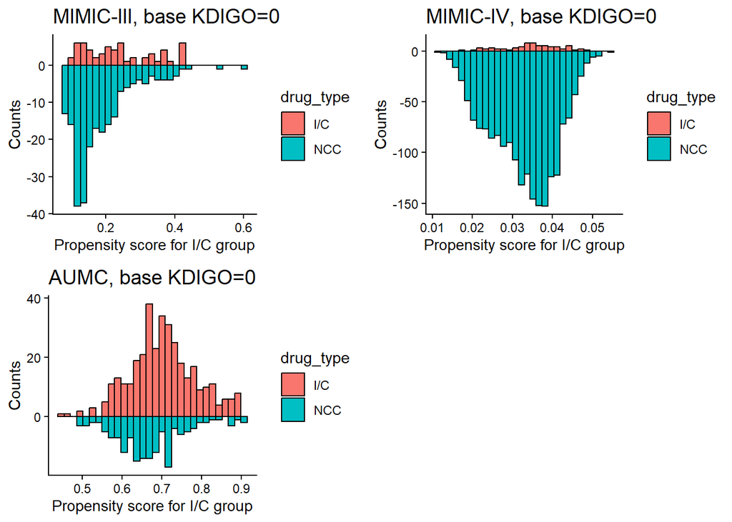

```r
#ROC
#roc(readRDS("wgt_man_Ovlp_MIMIC3_base0.rds")$treat, readRDS("wgt_man_Ovlp_MIMIC3_base0.rds")$ps_for_IMI)%>%auc()%>%round(.,digits = 2)%>%paste0("ovlp_AUC base 0 (MIMIC3) = ", .)
#roc(readRDS("wgt_man_Ovlp_MIMIC4_base0.rds")$treat, readRDS("wgt_man_Ovlp_MIMIC4_base0.rds")$ps_for_IMI)%>%auc()%>%round(.,digits = 2)%>%paste0("ovlp_AUC base 0 (MIMIC4) = ", .)
#roc(readRDS("wgt_man_Ovlp_AUMC_base0.rds")$treat, readRDS("wgt_man_Ovlp_AUMC_base0.rds")$ps_for_IMI) %>%auc()%>%round(., digits = 2)%>%paste0("ovlp_AUC base 0 (AUMC) = ", .)

#histogram
gridExtra::grid.arrange(
HISTO(readRDS("wgt_man_Ovlp_MIMIC3_base0.rds"), "MIMIC-III, base KDIGO=0"),
HISTO(readRDS("wgt_man_Ovlp_MIMIC4_base0.rds"), "MIMIC-IV, base KDIGO=0"),
HISTO(readRDS("wgt_man_Ovlp_AUMC_base0.rds"), "AUMC, base KDIGO=0"), nrow=2)
```

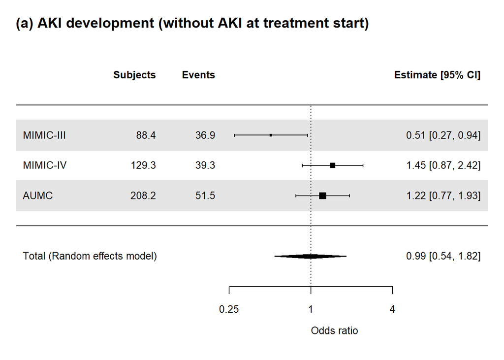

```r
#Forrestplot
FP2("wgt_man_Ovlp_MIMIC3_base0.rds", FORMULA_ovl2)
FP2("wgt_man_Ovlp_MIMIC4_base0.rds", FORMULA_ovl2)
FP2("wgt_man_Ovlp_AUMC_base0.rds", FORMULA_ovl2)



#
base0_METADF0 <- rbind(
  readRDS("ORRES_wgt_man_Ovlp_MIMIC3_base0.rds") %>% mutate("dataset"="MIMIC-III"),
  readRDS("ORRES_wgt_man_Ovlp_MIMIC4_base0.rds") %>% mutate("dataset"="MIMIC-IV"),
  readRDS("ORRES_wgt_man_Ovlp_AUMC_base0.rds") %>% mutate("dataset"="AUMC"))
base0_METADF_AKID <- base0_METADF0 %>% subset(outcome=="outcome_KDIGO_inc_or_death")
base0_METADF_AKI <- base0_METADF0 %>% subset(outcome=="outcome_KDIGO_inc")
base0_METADF_HD <- base0_METADF0 %>% subset(outcome=="outcome_new_dial")
base0_METADF_D <- base0_METADF0 %>% subset(outcome=="death_in_7d")
base0_METADF_HDD <- base0_METADF0 %>% subset(outcome=="outcome_HDD_in7d")
base0_METARES_AKID <- rma(yi = Estimate, sei = Std.Error, method = "REML", data = base0_METADF_AKID)
base0_METARES_AKI<-rma(yi = Estimate, sei = Std.Error, method = "REML", data = base0_METADF_AKI)
base0_METARES_HD<-rma(yi = Estimate, sei = Std.Error, method = "REML", data = base0_METADF_HD)
base0_METARES_D<-rma(yi = Estimate, sei = Std.Error, method = "REML", data = base0_METADF_D)
base0_METARES_HDD<-rma(yi = Estimate, sei = Std.Error, method = "REML", data = base0_METADF_HDD)

METAF(base0_METARES_AKI, SCALEA1, SCALEB1, SCALEC1, "(a) AKI development (without AKI at treatment start)")
```

```r
base0_METARES_AKI
```

```
##
## Random-Effects Model (k = 3; tau^2 estimator: REML)
##
## tau^2 (estimated amount of total heterogeneity): 0.2145 (SE = 0.2879)
## tau (square root of estimated tau^2 value):      0.4632
## I^2 (total heterogeneity / total variability):   74.89%
## H^2 (total variability / sampling variability):  3.98
##
## Test for Heterogeneity:
## Q(df = 2) = 7.2220, p-val = 0.0270
##
## Model Results:
##
## estimate      se     zval    pval    ci.lb   ci.ub
##  -0.0098  0.3097  -0.0316  0.9748  -0.6167  0.5971
##
## ---
## Signif. codes:  0 '***' 0.001 '**' 0.01 '*' 0.05 '.' 0.1 ' ' 1
```

```r
base0_METADF_AKI %>% dplyr::select(dataset, OR, LCI, UCI, 'Pr(>|z|)') %>% remove_rownames()
```

```
##     dataset        OR       LCI       UCI   Pr(>|z|)
## 1 MIMIC-III 0.5073762 0.2730463 0.9428093 0.03185305
## 2  MIMIC-IV 1.4485243 0.8659679 2.4229799 0.15803690
## 3      AUMC 1.2227252 0.7746372 1.9300092 0.38789205
```

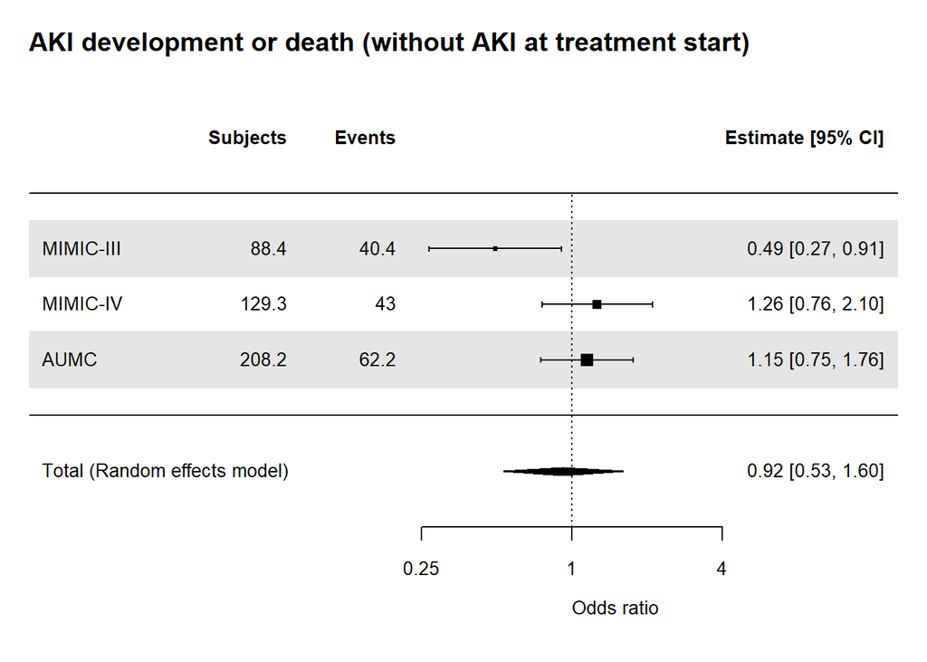

```r
METAF(base0_METARES_AKID, SCALEA1, SCALEB1, SCALEC1, "AKI development or death (without AKI at treatment start)")
```

```r
base0_METARES_AKID
```

```
##
## Random-Effects Model (k = 3; tau^2 estimator: REML)
##
## tau^2 (estimated amount of total heterogeneity): 0.1673 (SE = 0.2363)
## tau (square root of estimated tau^2 value):      0.4091
## I^2 (total heterogeneity / total variability):   71.30%
## H^2 (total variability / sampling variability):  3.48
##
## Test for Heterogeneity:
## Q(df = 2) = 6.3603, p-val = 0.0416
##
## Model Results:
##
## estimate      se     zval    pval    ci.lb   ci.ub
##  -0.0813  0.2804  -0.2900  0.7718  -0.6309  0.4683
##
## ---
## Signif. codes:  0 '***' 0.001 '**' 0.01 '*' 0.05 '.' 0.1 ' ' 1
```

```r
base0_METADF_AKID %>% dplyr::select(dataset, OR, LCI, UCI, 'Pr(>|z|)') %>% remove_rownames()
```

```
##     dataset        OR       LCI       UCI   Pr(>|z|)
## 1 MIMIC-III 0.4939646 0.2688167 0.9076855 0.02308815
## 2  MIMIC-IV 1.2628639 0.7591916 2.1006885 0.36872119
## 3      AUMC 1.1485737 0.7509750 1.7566785 0.52284986
```

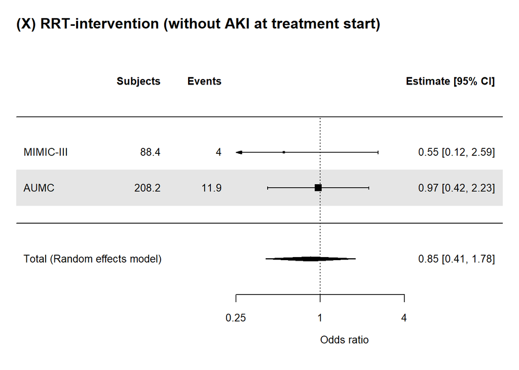

```r
METAF(base0_METARES_HD, SCALEA1, SCALEB1, SCALEC1, "(X) RRT-intervention (without AKI at treatment start)")
```

```r
base0_METARES_HD
```

```
##
## Random-Effects Model (k = 2; tau^2 estimator: REML)
##
## tau^2 (estimated amount of total heterogeneity): 0 (SE = 0.5695)
## tau (square root of estimated tau^2 value):      0
## I^2 (total heterogeneity / total variability):   0.00%
## H^2 (total variability / sampling variability):  1.00
##
## Test for Heterogeneity:
## Q(df = 1) = 0.3949, p-val = 0.5297
##
## Model Results:
##
## estimate      se     zval    pval    ci.lb   ci.ub
##  -0.1586  0.3745  -0.4235  0.6719  -0.8927  0.5755
##
## ---
## Signif. codes:  0 '***' 0.001 '**' 0.01 '*' 0.05 '.' 0.1 ' ' 1
```

```r
base0_METADF_HD %>% dplyr::select(dataset, OR, LCI, UCI, 'Pr(>|z|)') %>% remove_rownames()
```

```
##     dataset        OR       LCI      UCI  Pr(>|z|)
## 1 MIMIC-III 0.5510640 0.1170947 2.593384 0.4508086
## 2  MIMIC-IV 0.0000000       NaN      NaN       NaN
## 3      AUMC 0.9685851 0.4207955 2.229484 0.9401829
```

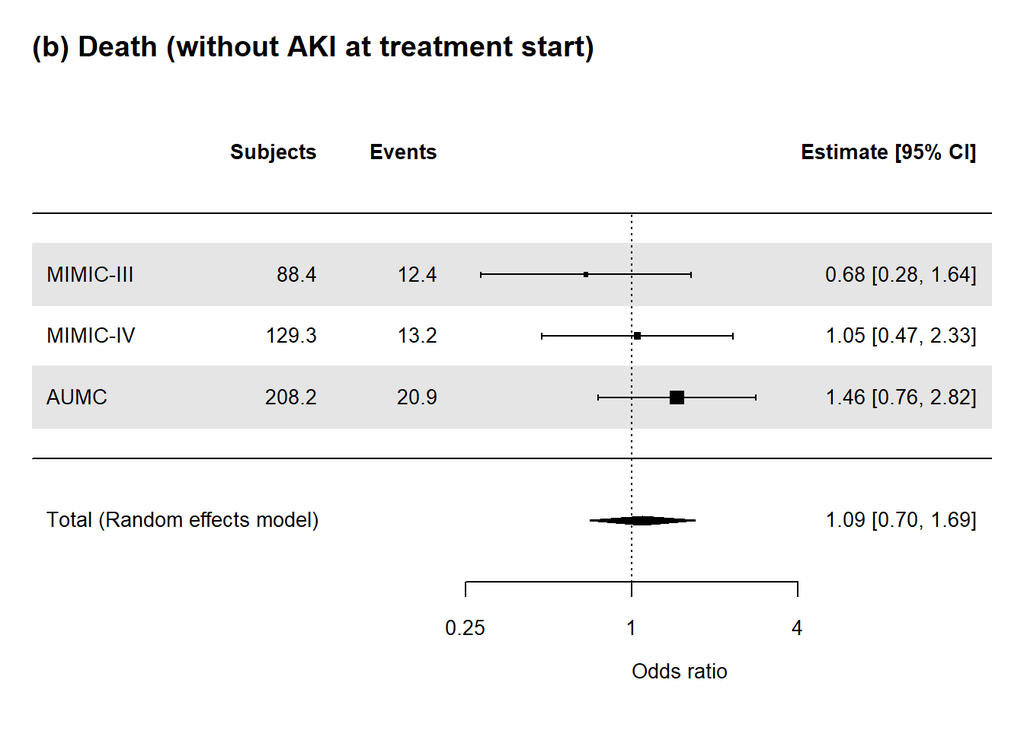

```r
METAF(base0_METARES_D, SCALEA1, SCALEB1, SCALEC1, "(b) Death (without AKI at treatment start)")
```

```r
base0_METARES_D
```

```
##
## Random-Effects Model (k = 3; tau^2 estimator: REML)
##
## tau^2 (estimated amount of total heterogeneity): 0 (SE = 0.1535)
## tau (square root of estimated tau^2 value):      0
## I^2 (total heterogeneity / total variability):   0.00%
## H^2 (total variability / sampling variability):  1.00
##
## Test for Heterogeneity:
## Q(df = 2) = 1.8567, p-val = 0.3952
##
## Model Results:
##
## estimate      se    zval    pval    ci.lb   ci.ub
##   0.0872  0.2241  0.3893  0.6971  -0.3520  0.5265
##
## ---
## Signif. codes:  0 '***' 0.001 '**' 0.01 '*' 0.05 '.' 0.1 ' ' 1
```

```r
base0_METADF_D %>% dplyr::select(dataset, OR, LCI, UCI, 'Pr(>|z|)') %>% remove_rownames()
```

```
##     dataset        OR       LCI      UCI  Pr(>|z|)
## 1 MIMIC-III 0.6825325 0.2838415 1.641235 0.3935447
## 2  MIMIC-IV 1.0490231 0.4724314 2.329331 0.9063941
## 3      AUMC 1.4587741 0.7557510 2.815771 0.2604404
```

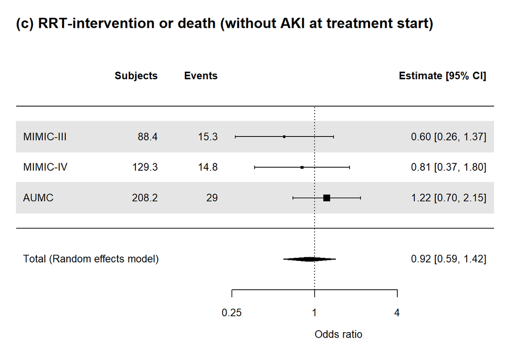

```r
METAF(base0_METARES_HDD, SCALEA1, SCALEB1, SCALEC1, "(c) RRT-intervention or death (without AKI at treatment start)")
```

```r
base0_METARES_HDD
```

```
##
## Random-Effects Model (k = 3; tau^2 estimator: REML)
##
## tau^2 (estimated amount of total heterogeneity): 0.0205 (SE = 0.1539)
## tau (square root of estimated tau^2 value):      0.1431
## I^2 (total heterogeneity / total variability):   13.16%
## H^2 (total variability / sampling variability):  1.15
##
## Test for Heterogeneity:
## Q(df = 2) = 2.0906, p-val = 0.3516
##
## Model Results:
##
## estimate      se     zval    pval    ci.lb   ci.ub
##  -0.0860  0.2227  -0.3861  0.6994  -0.5225  0.3505
##
## ---
## Signif. codes:  0 '***' 0.001 '**' 0.01 '*' 0.05 '.' 0.1 ' ' 1
```

```r
base0_METADF_HDD %>% dplyr::select(dataset, OR, LCI, UCI, 'Pr(>|z|)') %>% remove_rownames()
```

```
##     dataset        OR       LCI      UCI  Pr(>|z|)
## 1 MIMIC-III 0.6028789 0.2645042 1.374130 0.2286406
## 2  MIMIC-IV 0.8116237 0.3666083 1.796831 0.6067393
## 3      AUMC 1.2246677 0.6966819 2.152792 0.4813207
```

__

#### 4d. Backgrounds, outcomes, matching quality, and forest plot among those **with AKI** at treatment start.

```r
#1. overlap-PSM using MIMIC3, base KDIGO=0
OVLP(comb_DF2ovl %>% subset(dataset=="MIMIC3"&base_KDIGO>0.1&base_KDIGO<3), FORMULA_ovl2, "Ovlp_MIMIC3_base12", "**Ovlp, MIMIC-III, base_KDIGO 1,2**")
```

| **Characteristic** | **Ovlp, MIMIC-III, base_KDIGO 1,2** **I/C** N=14.2<sup>1</sup> | **Ovlp, MIMIC-III, base_KDIGO 1,2** **NCC** N=14.2<sup>1</sup> | **p-value**<sup>2</sup> |  |
| --- | --- | --- | --- | --- |
| dataset |  |  |  |  |
| MIMIC3 | 14.2 (100.0%) | 14.2 (100.0%) |  |  |
| age_group |  |  | >0.99 |  |
| 18-39 | 0.8 (5.5%) | 0.6 (3.9%) |  |  |
| 40-49 | 0.8 (5.7%) | 1.4 (9.7%) |  |  |
| 50-59 | 2.4 (16.6%) | 2.3 (16.1%) |  |  |
| 60-69 | 3.7 (25.7%) | 3.3 (23.2%) |  |  |
| 70-79 | 4.4 (31.3%) | 4.3 (30.0%) |  |  |
| 80+ | 2.2 (15.2%) | 2.4 (17.0%) |  |  |
| sex |  |  | >0.99 |  |
| Female | 8.1 (56.8%) | 8.1 (56.8%) |  |  |
| Male | 6.1 (43.2%) | 6.1 (43.2%) |  |  |
| bmi | 26.0 (25.4, 29.2) | 27.8 (24.9, 36.6) | 0.50 |  |
| Unknown | 7 | 10 |  |  |
| weight | 75.0 (62.0, 83.0) | 78.8 (63.0, 102.2) | 0.19 |  |
| Unknown | 2 | 4 |  |  |
| ICU type |  |  | >0.99 |  |
| Non-surgery | 11.8 (83.0%) | 11.8 (83.0%) |  |  |
| Surgery | 2.4 (17.0%) | 2.4 (17.0%) |  |  |
| drug_name |  |  |  |  |
| Imipenem/cilastatin | 14.2 (100.0%) | 0.0 (0.0%) |  |  |
| Imipenem/cilastatin/relebactam | 0.0 (0.0%) | 0.0 (0.0%) |  |  |
| Meropenem | 0.0 (0.0%) | 14.2 (100.0%) |  |  |
| Doripenem | 0.0 (0.0%) | 0.0 (0.0%) |  |  |
| Ertapenem | 0.0 (0.0%) | 0.0 (0.0%) |  |  |
| Overdose in first 24h |  |  | 0.69 |  |
| not_over | 13.4 (94.1%) | 13.7 (96.4%) |  |  |
| over | 0.8 (5.9%) | 0.5 (3.6%) |  |  |
| Relative initiation dose (with near eGFR) | 0.3 (0.3, 0.7) | 0.5 (0.3, 0.5) | 0.67 |  |
| sofa | 6.0 (4.0, 8.0) | 5.0 (3.0, 7.0) | 0.22 |  |
| qsofa | 1.0 (0.0, 1.0) | 1.0 (0.0, 1.0) | 0.64 |  |
| Unknown | 0 | 1 |  |  |
| sirs | 2.0 (2.0, 2.0) | 2.0 (1.0, 2.0) | 0.65 |  |
| pre_blood_culture | 11.7 (82.7%) | 11.7 (82.7%) | >0.99 |  |
| pre nephrotoxic drugs use | 8.0 (56.6%) | 8.0 (56.6%) | >0.99 |  |
| pre vancomycin use | 8.0 (56.6%) | 7.1 (50.4%) | 0.64 |  |
| pre aminoglycosied use | 0.0 (0.0%) | 1.2 (8.4%) | 0.021 |  |
| pre NSAIDs use | 1.8 (12.7%) | 1.9 (13.7%) | 0.92 |  |
| pre contrast agent use | 0.0 (0.0%) | 0.0 (0.0%) |  |  |
| pre vasopressor use | 5.3 (37.1%) | 5.3 (37.1%) | >0.99 |  |
| pre ventilation | 9.6 (67.8%) | 8.8 (61.7%) | 0.64 |  |
| Baseline sCr | 0.8 (0.5, 1.4) | 1.0 (0.6, 1.4) | 0.74 |  |
| sCr at treatment start | 1.3 (1.0, 1.9) | 1.5 (1.1, 2.2) | 0.72 |  |
| AKI stage at treatment start |  |  | >0.99 |  |
| 1 | 12.6 (89.0%) | 12.6 (89.0%) |  |  |
| 2 | 1.6 (11.0%) | 1.6 (11.0%) |  |  |
| near_eGFR | 52.4 (30.9, 75.8) | 44.2 (24.1, 70.0) | 0.75 |  |
| observation time | 168.0 (153.8, 168.0) | 168.0 (168.0, 168.0) | 0.56 |  |
| Cencsored with drug change | 0.8 (5.7%) | 0.0 (0.0%) | 0.30 |  |
| RRT at treatment start | 0.0 (0.0%) | 0.0 (0.0%) |  |  |
| O, AKI develop/progress | 0.0 (0.0%) | 2.1 (14.9%) | 0.002 |  |
| O, Death | 2.0 (14.3%) | 1.7 (11.7%) | 0.76 |  |
| O, AKI d/p or death | 2.0 (14.3%) | 3.3 (23.0%) | 0.41 |  |
| O, RRT-intervention | 0.0 (0.0%) | 0.5 (3.6%) | 0.11 |  |
| O, Death or RRT-intervention | 2.0 (14.3%) | 2.0 (14.0%) | 0.98 |  |
| total_dose_ICM | 2,500.0 (1,000.0, 4,500.0) | 3,500.0 (2,000.0, 7,000.0) | 0.031 |  |
| total_dose_recabrio | NA (NA, NA) | NA (NA, NA) |  |  |
| Unknown | 14 | 14 |  |  |
| total_dose_erta | NA (NA, NA) | NA (NA, NA) |  |  |
| Unknown | 14 | 14 |  |  |
| total_dose_dori | NA (NA, NA) | NA (NA, NA) |  |  |
| Unknown | 14 | 14 |  |  |
| ini24h_dose_ICM | 500.0 (500.0, 1,000.0) | 1,000.0 (500.0, 1,000.0) | 0.013 |  |
| ini24h_dose_recabrio | NA (NA, NA) | NA (NA, NA) |  |  |
| Unknown | 14 | 14 |  |  |
| ini24h_dose_erta | NA (NA, NA) | NA (NA, NA) |  |  |
| Unknown | 14 | 14 |  |  |
| ini24h_dose_dori | NA (NA, NA) | NA (NA, NA) |  |  |
| Unknown | 14 | 14 |  |  |
| last_drug_in_obs | 96.0 (48.0, 168.0) | 148.0 (85.0, 168.0) | 0.42 |  |

<sup>1</sup> n (%); Median (Q1, Q3)  
<sup>2</sup> NA; Pearson’s X^2: Rao & Scott adjustment; Design-based KruskalWallis test

```r
#2. overlap-PSM using MIMIC4, base KDIGO=0
OVLP(comb_DF2ovl %>% subset(dataset=="miiv"&base_KDIGO>0.1&base_KDIGO<3), FORMULA_ovl2, "Ovlp_MIMIC4_base12", "**Ovlp, MIMIC-IV, base_KDIGO 1,2**")
```

| **Characteristic** | **Ovlp, MIMIC-IV, base_KDIGO 1,2** **I/C** N=20.2<sup>1</sup> | **Ovlp, MIMIC-IV, base_KDIGO 1,2** **NCC** N=20.2<sup>1</sup> | **p-value**<sup>2</sup> |  |
| --- | --- | --- | --- | --- |
| dataset |  |  |  |  |
| miiv | 20.2 (100.0%) | 20.2 (100.0%) |  |  |
| age_group |  |  | 0.36 |  |
| 18-39 | 0.0 (0.0%) | 0.5 (2.5%) |  |  |
| 40-49 | 2.0 (9.8%) | 1.0 (5.1%) |  |  |
| 50-59 | 1.0 (4.8%) | 2.8 (13.7%) |  |  |
| 60-69 | 6.8 (33.5%) | 5.2 (26.0%) |  |  |
| 70-79 | 6.7 (33.4%) | 5.4 (26.9%) |  |  |
| 80+ | 3.7 (18.5%) | 5.2 (25.9%) |  |  |
| sex |  |  | >0.99 |  |
| Female | 7.8 (38.4%) | 7.8 (38.4%) |  |  |
| Male | 12.4 (61.6%) | 12.4 (61.6%) |  |  |
| bmi | 29.9 (25.4, 33.6) | 28.0 (23.9, 33.1) | 0.38 |  |
| Unknown | 11 | 6 |  |  |
| weight | 76.7 (67.0, 86.1) | 79.5 (66.3, 97.2) | 0.54 |  |
| Unknown | 2 | 2 |  |  |
| ICU type |  |  | >0.99 |  |
| Non-surgery | 15.5 (76.5%) | 15.5 (76.5%) |  |  |
| Surgery | 4.8 (23.5%) | 4.8 (23.5%) |  |  |
| drug_name |  |  |  |  |
| Imipenem/cilastatin | 20.2 (100.0%) | 0.0 (0.0%) |  |  |
| Imipenem/cilastatin/relebactam | 0.0 (0.0%) | 0.0 (0.0%) |  |  |
| Meropenem | 0.0 (0.0%) | 20.2 (99.9%) |  |  |
| Doripenem | 0.0 (0.0%) | 0.0 (0.1%) |  |  |
| Ertapenem | 0.0 (0.0%) | 0.0 (0.0%) |  |  |
| Overdose in first 24h |  |  | 0.005 |  |
| not_over | 20.2 (100.0%) | 19.9 (98.5%) |  |  |
| over | 0.0 (0.0%) | 0.3 (1.5%) |  |  |
| Relative initiation dose (with near eGFR) | 0.3 (0.3, 0.5) | 0.5 (0.3, 0.5) | 0.025 |  |
| sofa | 6.0 (4.0, 9.0) | 8.0 (5.0, 11.0) | 0.27 |  |
| qsofa | 1.0 (0.0, 1.0) | 1.0 (0.0, 1.0) | 0.68 |  |
| Unknown | 0 | 0 |  |  |
| sirs | 2.0 (1.0, 3.0) | 2.0 (1.0, 3.0) | 0.94 |  |
| pre_blood_culture | 16.5 (81.6%) | 16.5 (81.6%) | >0.99 |  |
| pre nephrotoxic drugs use | 15.5 (76.7%) | 15.5 (76.7%) | >0.99 |  |
| pre vancomycin use | 14.5 (71.9%) | 15.2 (75.0%) | 0.74 |  |
| pre aminoglycosied use | 4.8 (24.0%) | 1.2 (6.2%) | 0.002 |  |
| pre NSAIDs use | 2.0 (9.7%) | 1.2 (6.0%) | 0.50 |  |
| pre contrast agent use | 0.0 (0.0%) | 0.3 (1.5%) | <0.001 |  |
| pre vasopressor use | 3.9 (19.4%) | 3.9 (19.4%) | >0.99 |  |
| pre ventilation | 4.9 (24.2%) | 3.8 (18.9%) | 0.55 |  |
| Baseline sCr | 1.3 (0.9, 1.7) | 1.2 (0.8, 1.7) | 0.88 |  |
| sCr at treatment start | 2.3 (1.5, 2.7) | 1.9 (1.4, 2.7) | 0.75 |  |
| AKI stage at treatment start |  |  | >0.99 |  |
| 1 | 15.4 (76.2%) | 15.4 (76.2%) |  |  |
| 2 | 4.8 (23.8%) | 4.8 (23.8%) |  |  |
| near_eGFR | 30.7 (20.5, 43.5) | 33.4 (21.4, 50.2) | 0.75 |  |
| observation time | 168.0 (168.0, 168.0) | 168.0 (168.0, 168.0) | 0.87 |  |
| Cencsored with drug change | 0.0 (0.0%) | 0.0 (0.0%) |  |  |
| RRT at treatment start | 0.0 (0.0%) | 0.0 (0.0%) |  |  |
| O, AKI develop/progress | 8.7 (43.2%) | 8.6 (42.4%) | 0.94 |  |
| O, Death | 6.8 (33.8%) | 6.1 (30.2%) | 0.73 |  |
| O, AKI d/p or death | 9.7 (48.0%) | 11.6 (57.2%) | 0.41 |  |
| O, RRT-intervention | 2.9 (14.4%) | 2.9 (14.3%) | >0.99 |  |
| O, Death or RRT-intervention | 7.8 (38.6%) | 7.8 (38.6%) | >0.99 |  |
| total_dose_ICM | 2,208.3 (822.9, 3,500.0) | 2,458.3 (1,020.8, 3,770.8) | 0.34 |  |
| Unknown | 0 | 0 |  |  |
| total_dose_recabrio | NA (NA, NA) | NA (NA, NA) |  |  |
| Unknown | 20 | 20 |  |  |
| total_dose_erta | NA (NA, NA) | NA (NA, NA) |  |  |
| Unknown | 20 | 20 |  |  |
| total_dose_dori | NA (NA, NA) | NA (NA, NA) |  |  |
| Unknown | 20 | 20 |  |  |
| ini24h_dose_ICM | 500.0 (500.0, 500.0) | 1,000.0 (500.0, 1,000.0) | <0.001 |  |
| Unknown | 0 | 0 |  |  |
| ini24h_dose_recabrio | NA (NA, NA) | NA (NA, NA) |  |  |
| Unknown | 20 | 20 |  |  |
| ini24h_dose_erta | NA (NA, NA) | NA (NA, NA) |  |  |
| Unknown | 20 | 20 |  |  |
| ini24h_dose_dori | NA (NA, NA) | NA (NA, NA) |  |  |
| Unknown | 20 | 20 |  |  |
| last_drug_in_obs | 84.0 (32.0, 168.0) | 93.0 (33.0, 168.0) | 0.88 |  |

<sup>1</sup> n (%); Median (Q1, Q3)  
<sup>2</sup> NA; Pearson’s X^2: Rao & Scott adjustment; Design-based KruskalWallis test

```r
#3. overlap-PSM using AUMC, base KDIGO=0
OVLP(comb_DF2ovl %>% subset(dataset=="AUMC"&base_KDIGO>0.1&base_KDIGO<3), FORMULA_ovl2, "Ovlp_AUMC_base12", "**Ovlp, AUMC, base_KDIGO 1,2**")
```

| **Characteristic** | **Ovlp, AUMC, base_KDIGO 1,2** **I/C** N=35.9<sup>1</sup> | **Ovlp, AUMC, base_KDIGO 1,2** **NCC** N=35.9<sup>1</sup> | **p-value**<sup>2</sup> |  |
| --- | --- | --- | --- | --- |
| dataset |  |  |  |  |
| AUMC | 35.9 (100.0%) | 35.9 (100.0%) |  |  |
| age_group |  |  | 0.67 |  |
| 18-39 | 3.5 (9.9%) | 4.0 (11.2%) |  |  |
| 40-49 | 2.1 (5.9%) | 2.3 (6.4%) |  |  |
| 50-59 | 7.0 (19.6%) | 5.1 (14.1%) |  |  |
| 60-69 | 11.6 (32.3%) | 11.3 (31.5%) |  |  |
| 70-79 | 9.2 (25.7%) | 12.4 (34.6%) |  |  |
| 80+ | 2.4 (6.6%) | 0.8 (2.1%) |  |  |
| sex |  |  | >0.99 |  |
| Female | 12.8 (35.8%) | 12.8 (35.8%) |  |  |
| Male | 23.0 (64.2%) | 23.0 (64.2%) |  |  |
| bmi | 24.5 (21.9, 27.8) | 24.8 (23.9, 30.7) | 0.13 |  |
| Unknown | 2 | 0 |  |  |
| weight | 75.0 (65.0, 85.0) | 85.0 (75.0, 95.0) | 0.17 |  |
| Unknown | 2 | 0 |  |  |
| ICU type |  |  | >0.99 |  |
| Non-surgery | 20.4 (56.8%) | 20.4 (56.8%) |  |  |
| Surgery | 15.5 (43.2%) | 15.5 (43.2%) |  |  |
| drug_name |  |  |  |  |
| Imipenem/cilastatin | 35.9 (100.0%) | 0.0 (0.0%) |  |  |
| Imipenem/cilastatin/relebactam | 0.0 (0.0%) | 0.0 (0.0%) |  |  |
| Meropenem | 0.0 (0.0%) | 35.9 (100.0%) |  |  |
| Doripenem | 0.0 (0.0%) | 0.0 (0.0%) |  |  |
| Ertapenem | 0.0 (0.0%) | 0.0 (0.0%) |  |  |
| Overdose in first 24h |  |  | 0.10 |  |
| not_over | 34.7 (96.6%) | 35.9 (100.0%) |  |  |
| over | 1.2 (3.4%) | 0.0 (0.0%) |  |  |
| Relative initiation dose (with near eGFR) | 0.3 (0.3, 0.5) | 0.5 (0.3, 0.7) | <0.001 |  |
| sofa | 8.0 (5.0, 10.0) | 9.0 (7.0, 11.0) | 0.31 |  |
| Unknown | 5 | 6 |  |  |
| qsofa | 1.0 (0.0, 1.0) | 1.0 (0.0, 1.0) | 0.91 |  |
| sirs | 2.0 (2.0, 3.0) | 2.0 (2.0, 3.0) | 0.81 |  |
| pre_blood_culture | 4.4 (12.2%) | 4.4 (12.2%) | >0.99 |  |
| pre nephrotoxic drugs use | 20.2 (56.4%) | 20.2 (56.4%) | >0.99 |  |
| pre vancomycin use | 18.3 (51.1%) | 18.3 (51.0%) | >0.99 |  |
| pre aminoglycosied use | 4.4 (12.2%) | 2.2 (6.1%) | 0.24 |  |
| pre NSAIDs use | 0.1 (0.4%) | 4.1 (11.3%) | <0.001 |  |
| pre contrast agent use | 0.2 (0.5%) | 0.0 (0.0%) | 0.32 |  |
| pre vasopressor use | 25.0 (69.6%) | 25.0 (69.6%) | >0.99 |  |
| pre ventilation | 23.7 (66.1%) | 20.5 (57.2%) | 0.27 |  |
| Baseline sCr | 1.0 (0.7, 1.3) | 1.0 (0.7, 1.3) | 0.98 |  |
| sCr at treatment start | 1.6 (1.2, 2.3) | 1.6 (1.2, 2.3) | >0.99 |  |
| AKI stage at treatment start |  |  | >0.99 |  |
| 1 | 27.9 (77.9%) | 27.9 (77.9%) |  |  |
| 2 | 7.9 (22.1%) | 7.9 (22.1%) |  |  |
| near_eGFR | 43.0 (28.1, 61.7) | 41.3 (28.3, 65.6) | 0.91 |  |
| observation time | 168.0 (67.7, 168.0) | 133.6 (54.8, 168.0) | 0.38 |  |
| Cencsored with drug change | 1.5 (4.3%) | 0.0 (0.0%) | 0.037 |  |
| RRT at treatment start | 0.0 (0.0%) | 0.0 (0.0%) |  |  |
| O, AKI develop/progress | 12.9 (36.0%) | 16.1 (45.0%) | 0.27 |  |
| O, Death | 6.4 (17.8%) | 9.3 (26.0%) | 0.23 |  |
| O, AKI d/p or death | 15.0 (41.7%) | 19.1 (53.2%) | 0.17 |  |
| O, RRT-intervention | 7.2 (20.0%) | 9.4 (26.2%) | 0.38 |  |
| O, Death or RRT-intervention | 10.8 (30.2%) | 13.5 (37.5%) | 0.35 |  |
| total_dose_ICM | 8,000.0 (2,500.0, 15,500.0) | 10,000.0 (4,000.0, 19,500.0) | 0.20 |  |
| total_dose_recabrio | NA (NA, NA) | NA (NA, NA) |  |  |
| Unknown | 36 | 36 |  |  |
| total_dose_erta | NA (NA, NA) | NA (NA, NA) |  |  |
| Unknown | 36 | 36 |  |  |
| total_dose_dori | NA (NA, NA) | NA (NA, NA) |  |  |
| Unknown | 36 | 36 |  |  |
| ini24h_dose_ICM | 500.0 (500.0, 500.0) | 1,000.0 (1,000.0, 1,000.0) | <0.001 |  |
| ini24h_dose_recabrio | NA (NA, NA) | NA (NA, NA) |  |  |
| Unknown | 36 | 36 |  |  |
| ini24h_dose_erta | NA (NA, NA) | NA (NA, NA) |  |  |
| Unknown | 36 | 36 |  |  |
| ini24h_dose_dori | NA (NA, NA) | NA (NA, NA) |  |  |
| Unknown | 36 | 36 |  |  |
| last_drug_in_obs | 106.0 (36.0, 168.0) | 84.0 (37.8, 168.0) | 0.31 |  |

<sup>1</sup> n (%); Median (Q1, Q3)  
<sup>2</sup> NA; Pearson’s X^2: Rao & Scott adjustment; Design-based KruskalWallis test

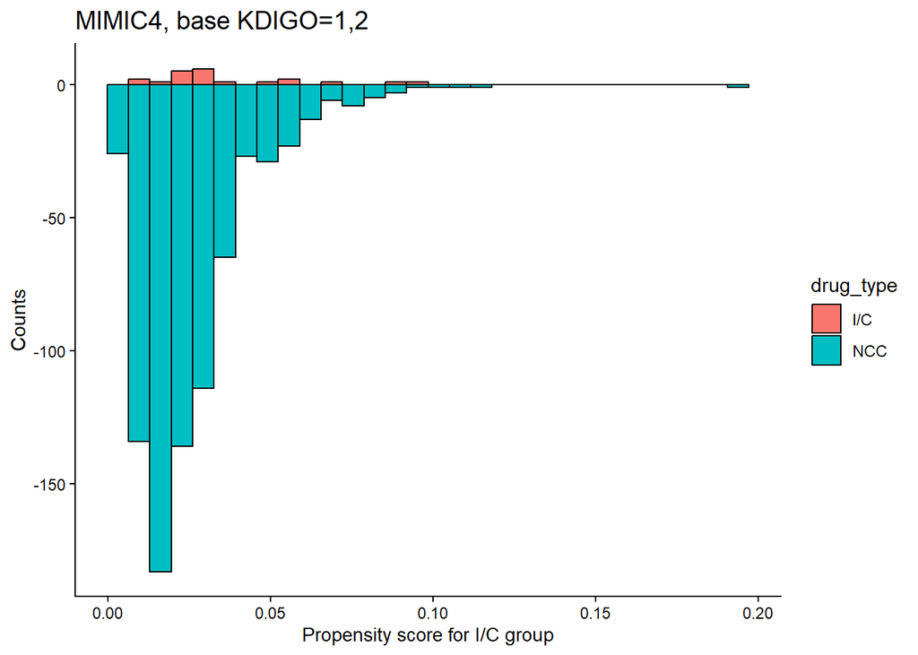

```r
#ROC
#roc(readRDS("wgt_man_Ovlp_MIMIC3_base12.rds")$treat, readRDS("wgt_man_Ovlp_MIMIC3_base12.rds")$ps_for_IMI)%>%auc()%>%round(.,digits = 2)%>%paste0("ovlp_AUC base 1,2 (MIMIC3) = ", .)
#roc(readRDS("wgt_man_Ovlp_MIMIC4_base12.rds")$treat, readRDS("wgt_man_Ovlp_MIMIC4_base12.rds")$ps_for_IMI)%>%auc()%>%round(.,digits = 2)%>%paste0("ovlp_AUC base 1,2 (MIMIC4) = ", .)
#roc(readRDS("wgt_man_Ovlp_AUMC_base12.rds")$treat, readRDS("wgt_man_Ovlp_AUMC_base12.rds")$ps_for_IMI) %>%auc()%>%round(., digits = 2)%>%paste0("ovlp_AUC base 1,2 (AUMC) = ", .)

#histogram
HISTO(readRDS("wgt_man_Ovlp_MIMIC4_base12.rds"), "MIMIC4, base KDIGO=1,2")
```

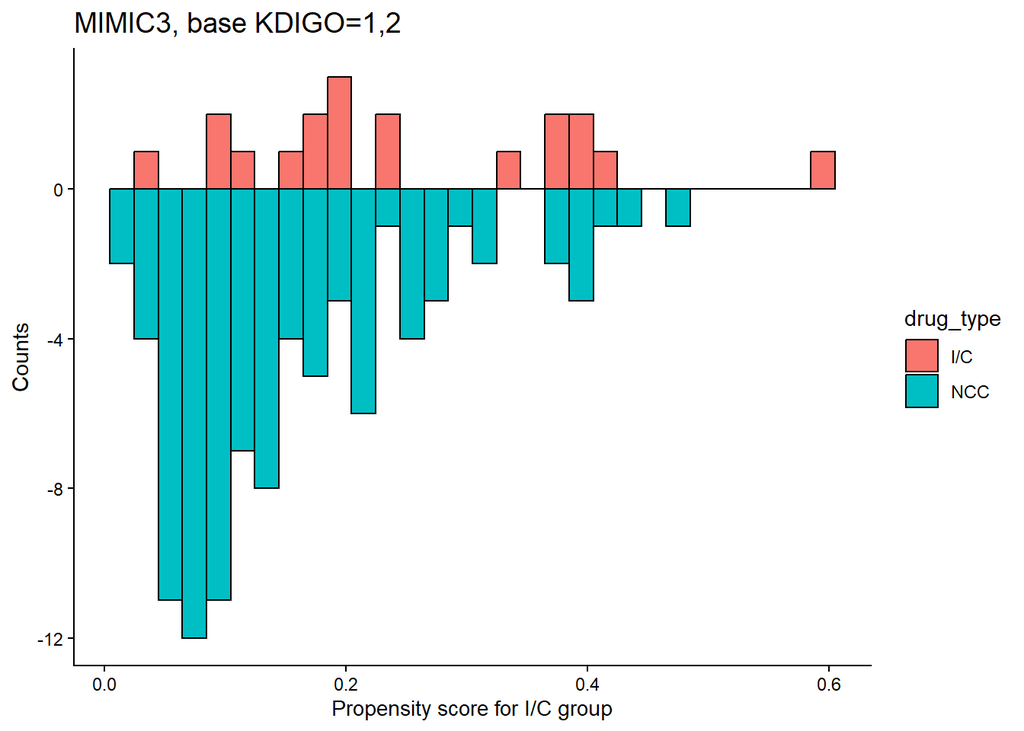

```r
HISTO(readRDS("wgt_man_Ovlp_MIMIC3_base12.rds"), "MIMIC3, base KDIGO=1,2")
```

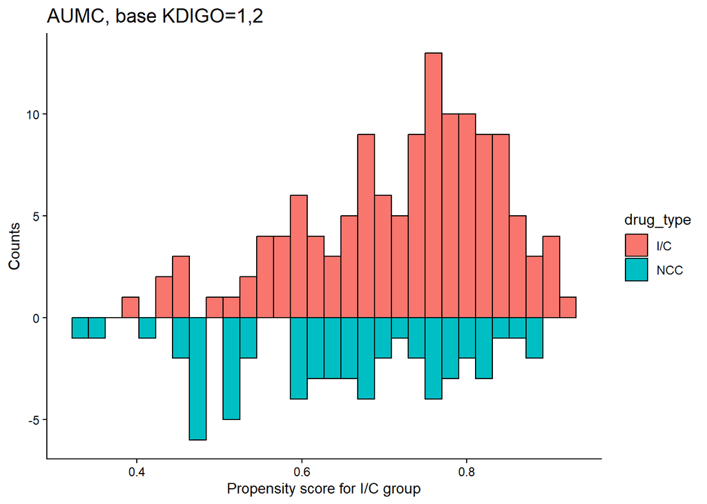

```r
HISTO(readRDS("wgt_man_Ovlp_AUMC_base12.rds"), "AUMC, base KDIGO=1,2")
```

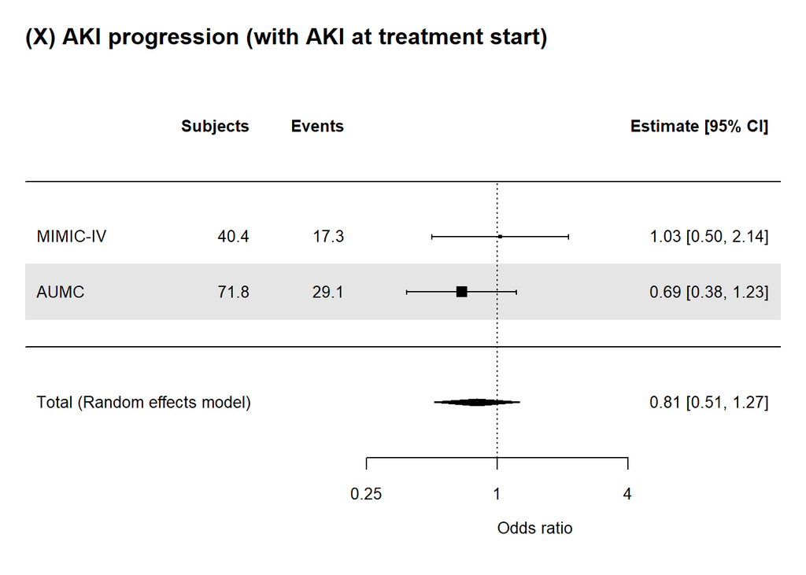

```r
FP2("wgt_man_Ovlp_MIMIC4_base12.rds", FORMULA_ovl2)
FP2("wgt_man_Ovlp_MIMIC3_base12.rds", FORMULA_ovl2)
FP2("wgt_man_Ovlp_AUMC_base12.rds", FORMULA_ovl2)

base12_METADF0 <- rbind(
  readRDS("ORRES_wgt_man_Ovlp_MIMIC3_base12.rds") %>% mutate("dataset"="MIMIC-III"),
  readRDS("ORRES_wgt_man_Ovlp_MIMIC4_base12.rds") %>% mutate("dataset"="MIMIC-IV"),
  readRDS("ORRES_wgt_man_Ovlp_AUMC_base12.rds") %>% mutate("dataset"="AUMC"))
base12_METADF_AKID <- base12_METADF0 %>% subset(outcome=="outcome_KDIGO_inc_or_death")
base12_METADF_AKI <- base12_METADF0 %>% subset(outcome=="outcome_KDIGO_inc")
base12_METADF_HD <- base12_METADF0 %>% subset(outcome=="outcome_new_dial")
base12_METADF_D <- base12_METADF0 %>% subset(outcome=="death_in_7d")
base12_METADF_HDD <- base12_METADF0 %>% subset(outcome=="outcome_HDD_in7d")

base12_METARES_AKID <- rma(yi = Estimate, sei = Std.Error, method = "REML", data = base12_METADF_AKID)
base12_METARES_AKI <-rma(yi = Estimate, sei = Std.Error, method = "REML", data = base12_METADF_AKI)
base12_METARES_HD <- rma(yi = Estimate, sei = Std.Error, method = "REML", data = base12_METADF_HD)
base12_METARES_D <- rma(yi = Estimate, sei = Std.Error, method = "REML", data = base12_METADF_D)
base12_METARES_HDD <- rma(yi = Estimate, sei = Std.Error, method = "REML", data = base12_METADF_HDD)

METAF(base12_METARES_AKI, SCALEA1, SCALEB1, SCALEC1, "(X) AKI progression (with AKI at treatment start)")
```

```r
base12_METARES_AKI
```

```
##
## Random-Effects Model (k = 2; tau^2 estimator: REML)
##
## tau^2 (estimated amount of total heterogeneity): 0 (SE = 0.1591)
## tau (square root of estimated tau^2 value):      0
## I^2 (total heterogeneity / total variability):   0.00%
## H^2 (total variability / sampling variability):  1.00
##
## Test for Heterogeneity:
## Q(df = 1) = 0.7409, p-val = 0.3894
##
## Model Results:
##
## estimate      se     zval    pval    ci.lb   ci.ub
##  -0.2154  0.2315  -0.9308  0.3520  -0.6691  0.2382
##
## ---
## Signif. codes:  0 '***' 0.001 '**' 0.01 '*' 0.05 '.' 0.1 ' ' 1
```

```r
base12_METADF_AKI %>% dplyr::select(dataset, OR, LCI, UCI, 'Pr(>|z|)') %>% remove_rownames()
```

```
##     dataset        OR       LCI      UCI  Pr(>|z|)
## 1 MIMIC-III 0.0000000       NaN      NaN       NaN
## 2  MIMIC-IV 1.0338241 0.5003979 2.135885 0.9284054
## 3      AUMC 0.6872736 0.3843242 1.229028 0.2060226
```

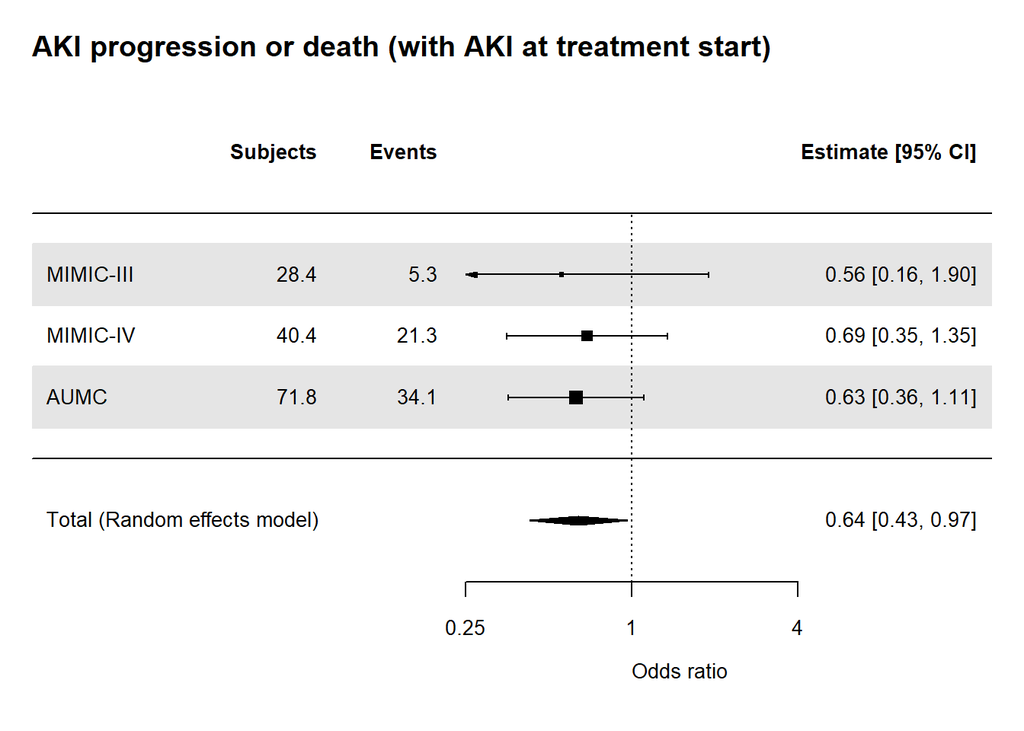

```r
METAF(base12_METARES_AKID, SCALEA1, SCALEB1, SCALEC1, "AKI progression or death (with AKI at treatment start)")
```

```r
base12_METARES_AKID
```

```
##
## Random-Effects Model (k = 3; tau^2 estimator: REML)
##
## tau^2 (estimated amount of total heterogeneity): 0 (SE = 0.1335)
## tau (square root of estimated tau^2 value):      0
## I^2 (total heterogeneity / total variability):   0.00%
## H^2 (total variability / sampling variability):  1.00
##
## Test for Heterogeneity:
## Q(df = 2) = 0.1015, p-val = 0.9505
##
## Model Results:
##
## estimate      se     zval    pval    ci.lb    ci.ub
##  -0.4422  0.2079  -2.1265  0.0335  -0.8498  -0.0346  *
##
## ---
## Signif. codes:  0 '***' 0.001 '**' 0.01 '*' 0.05 '.' 0.1 ' ' 1
```

```r
base12_METADF_AKID %>% dplyr::select(dataset, OR, LCI, UCI, 'Pr(>|z|)') %>% remove_rownames()
```

```
##     dataset        OR       LCI      UCI  Pr(>|z|)
## 1 MIMIC-III 0.5578015 0.1638887 1.898499 0.3502384
## 2  MIMIC-IV 0.6908992 0.3532492 1.351289 0.2799874
## 3      AUMC 0.6291023 0.3575151 1.107001 0.1079667
```

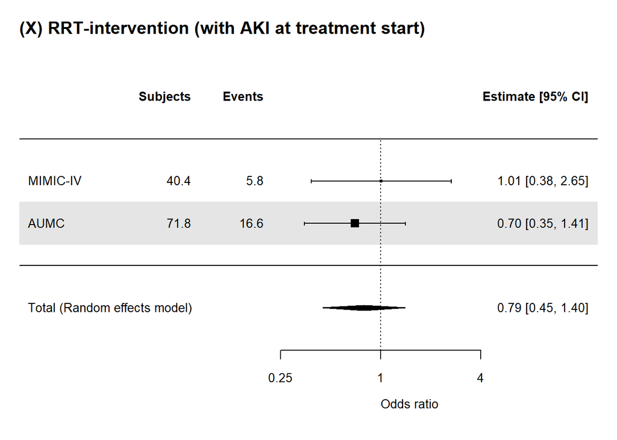

```r
METAF(base12_METARES_HD, SCALEA1, SCALEB1, SCALEC1, "(X) RRT-intervention (with AKI at treatment start)")
```

```r
base12_METARES_HD
```

```
##
## Random-Effects Model (k = 2; tau^2 estimator: REML)
##
## tau^2 (estimated amount of total heterogeneity): 0 (SE = 0.2626)
## tau (square root of estimated tau^2 value):      0
## I^2 (total heterogeneity / total variability):   0.00%
## H^2 (total variability / sampling variability):  1.00
##
## Test for Heterogeneity:
## Q(df = 1) = 0.3532, p-val = 0.5523
##
## Model Results:
##
## estimate      se     zval    pval    ci.lb   ci.ub
##  -0.2299  0.2893  -0.7948  0.4267  -0.7970  0.3371
##
## ---
## Signif. codes:  0 '***' 0.001 '**' 0.01 '*' 0.05 '.' 0.1 ' ' 1
```

```r
base12_METADF_HD %>% dplyr::select(dataset, OR, LCI, UCI, 'Pr(>|z|)') %>% remove_rownames()
```

```
##     dataset        OR       LCI      UCI  Pr(>|z|)
## 1 MIMIC-III 0.0000000       NaN      NaN       NaN
## 2  MIMIC-IV 1.0079530 0.3828866 2.653447 0.9872022
## 3      AUMC 0.7017109 0.3485711 1.412619 0.3210555
```

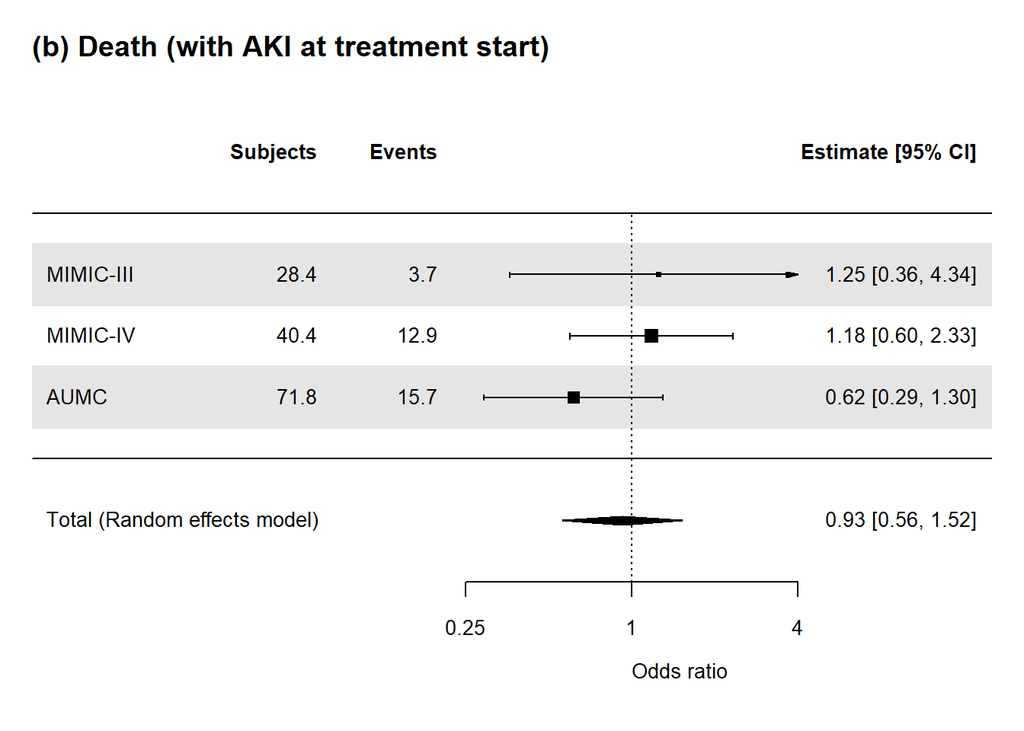

```r
METAF(base12_METARES_D, SCALEA1, SCALEB1, SCALEC1, "(b) Death (with AKI at treatment start)")
```

```r
base12_METARES_D
```

```
##
## Random-Effects Model (k = 3; tau^2 estimator: REML)
##
## tau^2 (estimated amount of total heterogeneity): 0.0197 (SE = 0.1959)
## tau (square root of estimated tau^2 value):      0.1403
## I^2 (total heterogeneity / total variability):   9.56%
## H^2 (total variability / sampling variability):  1.11
##
## Test for Heterogeneity:
## Q(df = 2) = 1.8536, p-val = 0.3958
##
## Model Results:
##
## estimate      se     zval    pval    ci.lb   ci.ub
##  -0.0778  0.2535  -0.3067  0.7591  -0.5746  0.4191
##
## ---
## Signif. codes:  0 '***' 0.001 '**' 0.01 '*' 0.05 '.' 0.1 ' ' 1
```

```r
base12_METADF_D %>% dplyr::select(dataset, OR, LCI, UCI, 'Pr(>|z|)') %>% remove_rownames()
```

```
##     dataset        OR       LCI      UCI  Pr(>|z|)
## 1 MIMIC-III 1.2535979 0.3619599 4.341663 0.7213889
## 2  MIMIC-IV 1.1802792 0.5976422 2.330925 0.6330892
## 3      AUMC 0.6166083 0.2919997 1.302076 0.2048562
```

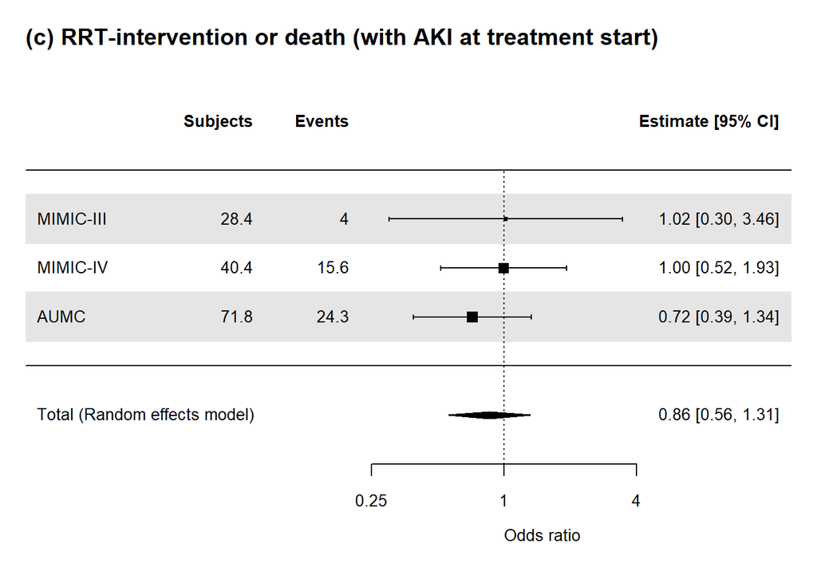

```r
METAF(base12_METARES_HDD, SCALEA1, SCALEB1, SCALEC1, "(c) RRT-intervention or death (with AKI at treatment start)")
```

```r
base12_METARES_HDD
```

```
##
## Random-Effects Model (k = 3; tau^2 estimator: REML)
##
## tau^2 (estimated amount of total heterogeneity): 0 (SE = 0.1415)
## tau (square root of estimated tau^2 value):      0
## I^2 (total heterogeneity / total variability):   0.00%
## H^2 (total variability / sampling variability):  1.00
##
## Test for Heterogeneity:
## Q(df = 2) = 0.5897, p-val = 0.7446
##
## Model Results:
##
## estimate      se     zval    pval    ci.lb   ci.ub
##  -0.1527  0.2160  -0.7071  0.4795  -0.5760  0.2706
##
## ---
## Signif. codes:  0 '***' 0.001 '**' 0.01 '*' 0.05 '.' 0.1 ' ' 1
```

```r
base12_METADF_HDD %>% dplyr::select(dataset, OR, LCI, UCI, 'Pr(>|z|)') %>% remove_rownames()
```

```
##     dataset        OR      LCI      UCI  Pr(>|z|)
## 1 MIMIC-III 1.0204629 0.300724 3.462792 0.9740781
## 2  MIMIC-IV 0.9977891 0.515739 1.930401 0.9947553
## 3      AUMC 0.7194757 0.387635 1.335394 0.2967749
```

__

#### 5c. Backgrounds, outcomes, matching quality, and forrest plot among those **males** at treatment start.

```r
FORMULA_ovl2_sex <- drug01 ~  age_cat + dep_type2 + sirs + pre_blood_culture + nt_drug + vasopressor + base_crea + near_crea +  base_KDIGO

#1. overlap-PSM using MIMIC3, "Male"
OVLP(comb_DF2ovl %>% subset(dataset=="MIMIC3"&sex=="Male"), FORMULA_ovl2_sex, "Ovlp_MIMIC3_Male", "**Ovlp, MIMIC-III, Male**")
```

| **Characteristic** | **Ovlp, MIMIC-III, Male** **I/C** N=29.9<sup>1</sup> | **Ovlp, MIMIC-III, Male** **NCC** N=29.9<sup>1</sup> | **p-value**<sup>2</sup> |  |
| --- | --- | --- | --- | --- |
| dataset |  |  |  |  |
| MIMIC3 | 29.9 (100.0%) | 29.9 (100.0%) |  |  |
| age_group |  |  | 0.79 |  |
| 18-39 | 2.5 (8.3%) | 2.4 (8.0%) |  |  |
| 40-49 | 4.3 (14.2%) | 3.3 (11.1%) |  |  |
| 50-59 | 6.1 (20.5%) | 6.3 (21.1%) |  |  |
| 60-69 | 5.4 (18.2%) | 6.0 (20.2%) |  |  |
| 70-79 | 5.3 (17.7%) | 7.9 (26.4%) |  |  |
| 80+ | 6.3 (21.1%) | 4.0 (13.2%) |  |  |
| sex |  |  |  |  |
| Male | 29.9 (100.0%) | 29.9 (100.0%) |  |  |
| bmi | 27.6 (24.9, 29.2) | 28.5 (23.6, 33.1) | 0.48 |  |
| Unknown | 11 | 13 |  |  |
| weight | 84.2 (75.0, 95.0) | 81.2 (65.5, 102.2) | 0.50 |  |
| Unknown | 4 | 4 |  |  |
| ICU type |  |  | >0.99 |  |
| Non-surgery | 16.1 (54.0%) | 16.1 (54.0%) |  |  |
| Surgery | 13.7 (46.0%) | 13.7 (46.0%) |  |  |
| drug_name |  |  |  |  |
| Imipenem/cilastatin | 29.9 (100.0%) | 0.0 (0.0%) |  |  |
| Imipenem/cilastatin/relebactam | 0.0 (0.0%) | 0.0 (0.0%) |  |  |
| Meropenem | 0.0 (0.0%) | 29.9 (100.0%) |  |  |
| Doripenem | 0.0 (0.0%) | 0.0 (0.0%) |  |  |
| Ertapenem | 0.0 (0.0%) | 0.0 (0.0%) |  |  |
| Overdose in first 24h |  |  | 0.23 |  |
| not_over | 29.9 (100.0%) | 29.5 (98.9%) |  |  |
| over | 0.0 (0.0%) | 0.3 (1.1%) |  |  |
| Relative initiation dose (with near eGFR) | 0.3 (0.2, 0.5) | 0.3 (0.3, 0.5) | 0.15 |  |
| sofa | 5.0 (3.0, 8.0) | 4.0 (2.0, 7.0) | 0.38 |  |
| qsofa | 1.0 (0.0, 1.0) | 1.0 (0.0, 1.0) | 0.35 |  |
| Unknown | 0 | 1 |  |  |
| sirs | 2.0 (1.0, 3.0) | 2.0 (1.0, 3.0) | 0.88 |  |
| pre_blood_culture | 22.9 (76.6%) | 22.9 (76.6%) | >0.99 |  |
| pre nephrotoxic drugs use | 17.9 (59.8%) | 17.9 (59.8%) | >0.99 |  |
| pre vancomycin use | 15.2 (51.0%) | 16.7 (55.9%) | 0.60 |  |
| pre aminoglycosied use | 2.6 (8.7%) | 2.0 (6.8%) | 0.68 |  |
| pre NSAIDs use | 3.3 (11.1%) | 3.8 (12.8%) | 0.77 |  |
| pre contrast agent use | 0.0 (0.0%) | 0.0 (0.0%) |  |  |
| pre vasopressor use | 11.9 (39.9%) | 11.9 (39.9%) | >0.99 |  |
| pre ventilation | 23.0 (77.2%) | 20.7 (69.3%) | 0.35 |  |
| Baseline sCr | 0.9 (0.7, 1.4) | 1.0 (0.6, 1.5) | 0.87 |  |
| sCr at treatment start | 1.1 (0.8, 1.7) | 1.1 (0.7, 1.7) | 0.82 |  |
| AKI stage at treatment start |  |  | 0.41 |  |
| 0 | 23.6 (79.2%) | 24.1 (80.7%) |  |  |
| 1 | 6.2 (20.8%) | 5.3 (17.8%) |  |  |
| 2 | 0.0 (0.0%) | 0.5 (1.5%) |  |  |
| near_eGFR | 74.5 (47.0, 98.2) | 74.5 (41.3, 100.7) | 0.85 |  |
| observation time | 168.0 (168.0, 168.0) | 168.0 (168.0, 168.0) | 0.77 |  |
| Cencsored with drug change | 1.4 (4.8%) | 0.1 (0.5%) | 0.022 |  |
| RRT at treatment start | 0.0 (0.0%) | 0.0 (0.0%) |  |  |
| O, AKI develop/progress | 8.9 (29.8%) | 13.1 (43.7%) | 0.13 |  |
| O, Death | 2.9 (9.6%) | 5.2 (17.4%) | 0.24 |  |
| O, AKI d/p or death | 10.4 (34.7%) | 14.6 (48.9%) | 0.13 |  |
| O, RRT-intervention | 1.4 (4.6%) | 1.9 (6.2%) | 0.71 |  |
| O, Death or RRT-intervention | 3.7 (12.5%) | 6.6 (22.1%) | 0.19 |  |
| total_dose_ICM | 2,500.0 (1,500.0, 3,500.0) | 4,077.5 (2,500.0, 7,000.0) | <0.001 |  |
| total_dose_recabrio | NA (NA, NA) | NA (NA, NA) |  |  |
| Unknown | 30 | 30 |  |  |
| total_dose_erta | NA (NA, NA) | NA (NA, NA) |  |  |
| Unknown | 30 | 30 |  |  |
| total_dose_dori | NA (NA, NA) | NA (NA, NA) |  |  |
| Unknown | 30 | 30 |  |  |
| ini24h_dose_ICM | 500.0 (500.0, 1,000.0) | 1,000.0 (500.0, 1,000.0) | <0.001 |  |
| ini24h_dose_recabrio | NA (NA, NA) | NA (NA, NA) |  |  |
| Unknown | 30 | 30 |  |  |
| ini24h_dose_erta | NA (NA, NA) | NA (NA, NA) |  |  |
| Unknown | 30 | 30 |  |  |
| ini24h_dose_dori | NA (NA, NA) | NA (NA, NA) |  |  |
| Unknown | 30 | 30 |  |  |
| last_drug_in_obs | 96.0 (48.0, 168.0) | 168.0 (75.2, 168.0) | 0.044 |  |

<sup>1</sup> n (%); Median (Q1, Q3)  
<sup>2</sup> NA; Pearson’s X^2: Rao & Scott adjustment; Design-based KruskalWallis test

```r
#2. overlap-PSM using MIMIC4, "Male"
OVLP(comb_DF2ovl %>% subset(dataset=="miiv"&sex=="Male"), FORMULA_ovl2_sex, "Ovlp_MIMIC4_Male", "**Ovlp, MIMIC-IV, Male**")
```

| **Characteristic** | **Ovlp, MIMIC-IV, Male** **I/C** N=48.4<sup>1</sup> | **Ovlp, MIMIC-IV, Male** **NCC** N=48.4<sup>1</sup> | **p-value**<sup>2</sup> |  |
| --- | --- | --- | --- | --- |
| dataset |  |  |  |  |
| miiv | 48.4 (100.0%) | 48.4 (100.0%) |  |  |
| age_group |  |  | 0.94 |  |
| 18-39 | 4.8 (10.0%) | 4.6 (9.5%) |  |  |
| 40-49 | 4.8 (10.0%) | 4.6 (9.5%) |  |  |
| 50-59 | 8.7 (18.0%) | 10.9 (22.6%) |  |  |
| 60-69 | 15.5 (32.0%) | 12.7 (26.3%) |  |  |
| 70-79 | 7.7 (16.0%) | 9.0 (18.7%) |  |  |
| 80+ | 6.8 (14.0%) | 6.5 (13.5%) |  |  |
| sex |  |  |  |  |
| Male | 48.4 (100.0%) | 48.4 (100.0%) |  |  |
| bmi | 27.1 (25.1, 31.1) | 27.2 (23.5, 32.3) | 0.48 |  |
| Unknown | 22 | 18 |  |  |
| weight | 85.0 (75.2, 100.0) | 82.5 (70.0, 99.5) | 0.080 |  |
| Unknown | 1 | 4 |  |  |
| ICU type |  |  | >0.99 |  |
| Non-surgery | 37.7 (78.0%) | 37.7 (78.0%) |  |  |
| Surgery | 10.7 (22.0%) | 10.7 (22.0%) |  |  |
| drug_name |  |  | <0.001 |  |
| Imipenem/cilastatin | 47.4 (98.0%) | 0.0 (0.0%) |  |  |
| Imipenem/cilastatin/relebactam | 1.0 (2.0%) | 0.0 (0.0%) |  |  |
| Meropenem | 0.0 (0.0%) | 48.0 (99.2%) |  |  |
| Doripenem | 0.0 (0.0%) | 0.1 (0.2%) |  |  |
| Ertapenem | 0.0 (0.0%) | 0.3 (0.6%) |  |  |
| Overdose in first 24h |  |  | <0.001 |  |
| not_over | 48.4 (100.0%) | 47.9 (99.0%) |  |  |
| over | 0.0 (0.0%) | 0.5 (1.0%) |  |  |
| Relative initiation dose (with near eGFR) | 0.3 (0.2, 0.3) | 0.3 (0.3, 0.5) | 0.005 |  |
| sofa | 5.0 (3.0, 7.0) | 5.0 (3.0, 8.0) | 0.13 |  |
| qsofa | 1.0 (0.0, 1.0) | 1.0 (0.0, 1.0) | 0.39 |  |
| Unknown | 0 | 0 |  |  |
| sirs | 2.0 (1.0, 2.0) | 2.0 (1.0, 3.0) | 0.96 |  |
| pre_blood_culture | 35.9 (74.2%) | 35.9 (74.2%) | >0.99 |  |
| pre nephrotoxic drugs use | 39.7 (82.0%) | 39.7 (82.0%) | >0.99 |  |
| pre vancomycin use | 37.8 (78.1%) | 37.9 (78.4%) | 0.95 |  |
| pre aminoglycosied use | 4.8 (10.0%) | 4.6 (9.6%) | 0.91 |  |
| pre NSAIDs use | 2.9 (6.0%) | 4.1 (8.5%) | 0.54 |  |
| pre contrast agent use | 1.0 (2.0%) | 0.6 (1.2%) | 0.64 |  |
| pre vasopressor use | 3.9 (8.0%) | 3.9 (8.0%) | >0.99 |  |
| pre ventilation | 7.7 (16.0%) | 3.9 (8.0%) | 0.046 |  |
| Baseline sCr | 1.0 (0.7, 1.6) | 1.0 (0.7, 1.5) | 0.78 |  |
| sCr at treatment start | 1.1 (0.8, 1.9) | 1.2 (0.8, 1.8) | 0.86 |  |
| AKI stage at treatment start |  |  | >0.99 |  |
| 0 | 35.8 (73.9%) | 35.7 (73.9%) |  |  |
| 1 | 9.7 (20.0%) | 9.8 (20.2%) |  |  |
| 2 | 2.9 (6.0%) | 2.9 (5.9%) |  |  |
| near_eGFR | 73.8 (36.7, 100.9) | 67.1 (38.8, 100.7) | 0.95 |  |
| observation time | 168.0 (128.4, 168.0) | 168.0 (160.3, 168.0) | 0.39 |  |
| Cencsored with drug change | 1.9 (4.0%) | 0.0 (0.0%) | 0.15 |  |
| RRT at treatment start | 0.0 (0.0%) | 0.0 (0.0%) |  |  |
| O, AKI develop/progress | 21.3 (44.0%) | 15.4 (31.8%) | 0.071 |  |
| O, Death | 8.7 (18.0%) | 6.5 (13.4%) | 0.35 |  |
| O, AKI d/p or death | 22.3 (46.0%) | 18.2 (37.7%) | 0.23 |  |
| O, RRT-intervention | 1.0 (2.0%) | 3.2 (6.7%) | 0.19 |  |
| O, Death or RRT-intervention | 9.7 (20.0%) | 8.7 (18.1%) | 0.73 |  |
| total_dose_ICM | 1,815.3 (479.2, 3,458.3) | 2,687.5 (1,291.7, 3,979.2) | 0.004 |  |
| Unknown | 1 | 0 |  |  |
| total_dose_recabrio | NA (NA, NA) | NA (NA, NA) |  |  |
| Unknown | 47 | 48 |  |  |
| total_dose_erta | NA (NA, NA) | NA (NA, NA) |  |  |
| Unknown | 48 | 48 |  |  |
| total_dose_dori | NA (NA, NA) | NA (NA, NA) |  |  |
| Unknown | 48 | 48 |  |  |
| ini24h_dose_ICM | 500.0 (500.0, 500.0) | 1,000.0 (500.0, 1,000.0) | <0.001 |  |
| Unknown | 1 | 0 |  |  |
| ini24h_dose_recabrio | NA (NA, NA) | NA (NA, NA) |  |  |
| Unknown | 47 | 48 |  |  |
| ini24h_dose_erta | NA (NA, NA) | NA (NA, NA) |  |  |
| Unknown | 48 | 48 |  |  |
| ini24h_dose_dori | NA (NA, NA) | NA (NA, NA) |  |  |
| Unknown | 48 | 48 |  |  |
| last_drug_in_obs | 71.0 (28.0, 163.0) | 101.0 (40.0, 168.0) | 0.18 |  |

<sup>1</sup> n (%); Median (Q1, Q3)  
<sup>2</sup> NA; Pearson’s X^2: Rao & Scott adjustment; Design-based KruskalWallis test

```r
#3. overlap-PSM using AUMC, "Male"
OVLP(comb_DF2ovl %>% subset(dataset=="AUMC"&sex=="Male"), FORMULA_ovl2_sex, "Ovlp_AUMC_Male", paste0("**Ovlp, AUMC", ", Male**"))
```

| **Characteristic** | **Ovlp, AUMC, Male** **I/C** N=91.1<sup>1</sup> | **Ovlp, AUMC, Male** **NCC** N=91.1<sup>1</sup> | **p-value**<sup>2</sup> |  |
| --- | --- | --- | --- | --- |
| dataset |  |  |  |  |
| AUMC | 91.1 (100.0%) | 91.1 (100.0%) |  |  |
| age_group |  |  | 0.40 |  |
| 18-39 | 7.7 (8.5%) | 10.9 (12.0%) |  |  |
| 40-49 | 8.4 (9.2%) | 9.3 (10.2%) |  |  |
| 50-59 | 20.0 (21.9%) | 14.3 (15.7%) |  |  |
| 60-69 | 30.0 (32.9%) | 26.3 (28.8%) |  |  |
| 70-79 | 21.3 (23.4%) | 24.5 (26.9%) |  |  |
| 80+ | 3.7 (4.1%) | 5.8 (6.4%) |  |  |
| sex |  |  |  |  |
| Male | 91.1 (100.0%) | 91.1 (100.0%) |  |  |
| bmi | 24.5 (21.9, 27.8) | 24.8 (21.9, 27.8) | 0.72 |  |
| Unknown | 5 | 0 |  |  |
| weight | 85.0 (75.0, 85.0) | 85.0 (75.0, 95.0) | 0.12 |  |
| Unknown | 3 | 0 |  |  |
| ICU type |  |  | >0.99 |  |
| Non-surgery | 53.0 (58.1%) | 53.0 (58.1%) |  |  |
| Surgery | 38.2 (41.9%) | 38.2 (41.9%) |  |  |
| drug_name |  |  |  |  |
| Imipenem/cilastatin | 91.1 (100.0%) | 0.0 (0.0%) |  |  |
| Imipenem/cilastatin/relebactam | 0.0 (0.0%) | 0.0 (0.0%) |  |  |
| Meropenem | 0.0 (0.0%) | 91.1 (100.0%) |  |  |
| Doripenem | 0.0 (0.0%) | 0.0 (0.0%) |  |  |
| Ertapenem | 0.0 (0.0%) | 0.0 (0.0%) |  |  |
| Overdose in first 24h |  |  | 0.31 |  |
| not_over | 91.1 (100.0%) | 90.3 (99.1%) |  |  |
| over | 0.0 (0.0%) | 0.8 (0.9%) |  |  |
| Relative initiation dose (with near eGFR) | 0.3 (0.2, 0.3) | 0.5 (0.3, 0.7) | <0.001 |  |
| sofa | 7.0 (4.0, 9.0) | 8.0 (4.0, 10.0) | 0.86 |  |
| Unknown | 14 | 14 |  |  |
| qsofa | 1.0 (0.0, 1.0) | 1.0 (0.0, 1.0) | 0.61 |  |
| Unknown | 0 | 0 |  |  |
| sirs | 2.0 (1.0, 3.0) | 2.0 (1.0, 3.0) | 0.97 |  |
| pre_blood_culture | 12.3 (13.5%) | 12.3 (13.5%) | >0.99 |  |
| pre nephrotoxic drugs use | 56.3 (61.8%) | 56.3 (61.8%) | >0.99 |  |
| pre vancomycin use | 48.1 (52.8%) | 49.2 (54.0%) | 0.83 |  |
| pre aminoglycosied use | 14.7 (16.1%) | 7.3 (8.1%) | 0.025 |  |
| pre NSAIDs use | 2.5 (2.8%) | 8.7 (9.5%) | 0.004 |  |
| pre contrast agent use | 1.1 (1.2%) | 0.0 (0.0%) | 0.082 |  |
| pre vasopressor use | 61.2 (67.2%) | 61.2 (67.2%) | >0.99 |  |
| pre ventilation | 61.2 (67.2%) | 58.0 (63.7%) | 0.48 |  |
| Baseline sCr | 0.9 (0.7, 1.3) | 0.8 (0.6, 1.2) | 0.32 |  |
| sCr at treatment start | 1.1 (0.8, 1.6) | 1.0 (0.7, 1.6) | 0.32 |  |
| AKI stage at treatment start |  |  | 0.78 |  |
| 0 | 66.3 (72.8%) | 67.4 (74.0%) |  |  |
| 1 | 20.0 (21.9%) | 17.7 (19.5%) |  |  |
| 2 | 4.8 (5.3%) | 5.9 (6.5%) |  |  |
| near_eGFR | 74.8 (50.7, 102.3) | 82.6 (47.9, 106.6) | 0.31 |  |
| observation time | 168.0 (68.8, 168.0) | 146.0 (56.4, 168.0) | 0.16 |  |
| Cencsored with drug change | 3.3 (3.6%) | 0.7 (0.8%) | 0.11 |  |
| RRT at treatment start | 0.0 (0.0%) | 0.0 (0.0%) |  |  |
| O, AKI develop/progress | 25.9 (28.4%) | 28.5 (31.3%) | 0.54 |  |
| O, Death | 13.5 (14.8%) | 13.5 (14.8%) | >0.99 |  |
| O, AKI d/p or death | 32.1 (35.2%) | 34.7 (38.1%) | 0.57 |  |
| O, RRT-intervention | 8.4 (9.2%) | 12.2 (13.4%) | 0.20 |  |
| O, Death or RRT-intervention | 19.2 (21.1%) | 19.8 (21.7%) | 0.89 |  |
| total_dose_ICM | 8,400.0 (3,500.0, 16,000.0) | 10,500.0 (5,000.0, 23,000.0) | 0.019 |  |
| total_dose_recabrio | NA (NA, NA) | NA (NA, NA) |  |  |
| Unknown | 91 | 91 |  |  |
| total_dose_erta | NA (NA, NA) | NA (NA, NA) |  |  |
| Unknown | 91 | 91 |  |  |
| total_dose_dori | NA (NA, NA) | NA (NA, NA) |  |  |
| Unknown | 91 | 91 |  |  |
| ini24h_dose_ICM | 500.0 (500.0, 500.0) | 1,000.0 (1,000.0, 2,000.0) | <0.001 |  |
| ini24h_dose_recabrio | NA (NA, NA) | NA (NA, NA) |  |  |
| Unknown | 91 | 91 |  |  |
| ini24h_dose_erta | NA (NA, NA) | NA (NA, NA) |  |  |
| Unknown | 91 | 91 |  |  |
| ini24h_dose_dori | NA (NA, NA) | NA (NA, NA) |  |  |
| Unknown | 91 | 91 |  |  |
| last_drug_in_obs | 110.0 (41.6, 168.0) | 72.0 (31.9, 168.0) | 0.018 |  |

<sup>1</sup> n (%); Median (Q1, Q3)  
<sup>2</sup> NA; Pearson’s X^2: Rao & Scott adjustment; Design-based KruskalWallis test

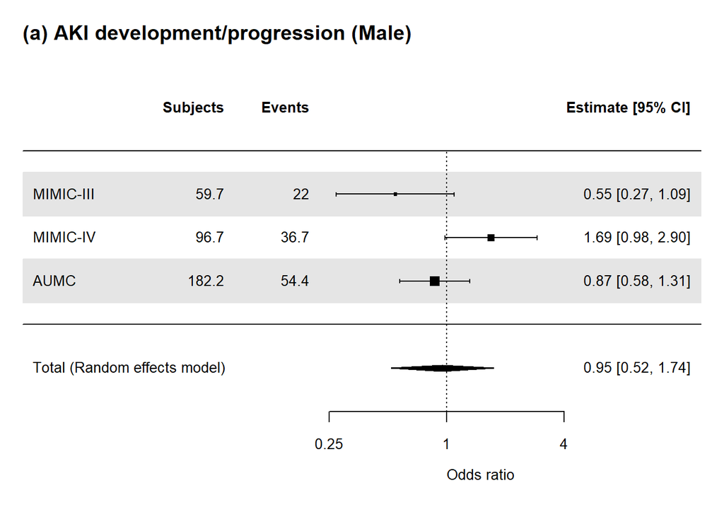

```r
#Forrestplot
FP2("wgt_man_Ovlp_MIMIC3_Male.rds", FORMULA_ovl2_sex)
FP2("wgt_man_Ovlp_MIMIC4_Male.rds", FORMULA_ovl2_sex)
FP2("wgt_man_Ovlp_AUMC_Male.rds", FORMULA_ovl2_sex)

Male_METADF0 <- rbind(
  readRDS("ORRES_wgt_man_Ovlp_MIMIC3_Male.rds") %>% mutate("dataset"="MIMIC-III"),
  readRDS("ORRES_wgt_man_Ovlp_MIMIC4_Male.rds") %>% mutate("dataset"="MIMIC-IV"),
  readRDS("ORRES_wgt_man_Ovlp_AUMC_Male.rds") %>% mutate("dataset"="AUMC"))
Male_METADF_AKID <- Male_METADF0 %>% subset(outcome=="outcome_KDIGO_inc_or_death")
Male_METADF_AKI <- Male_METADF0 %>% subset(outcome=="outcome_KDIGO_inc")
Male_METADF_HD <- Male_METADF0 %>% subset(outcome=="outcome_new_dial")
Male_METADF_D <- Male_METADF0 %>% subset(outcome=="death_in_7d")
Male_METADF_HDD <- Male_METADF0 %>% subset(outcome=="outcome_HDD_in7d")
Male_METARES_AKID <- rma(yi = Estimate, sei = Std.Error, method = "REML", data = Male_METADF_AKID)
Male_METARES_AKI<-rma(yi = Estimate, sei = Std.Error, method = "REML", data = Male_METADF_AKI)
Male_METARES_HD<-rma(yi = Estimate, sei = Std.Error, method = "REML", data = Male_METADF_HD)
Male_METARES_D<-rma(yi = Estimate, sei = Std.Error, method = "REML", data = Male_METADF_D)
Male_METARES_HDD<-rma(yi = Estimate, sei = Std.Error, method = "REML", data = Male_METADF_HDD)

METAF(Male_METARES_AKI, SCALEA1, SCALEB1, SCALEC1, "(a) AKI development/progression (Male)")
```

```r
Male_METARES_AKI
```

```
##
## Random-Effects Model (k = 3; tau^2 estimator: REML)
##
## tau^2 (estimated amount of total heterogeneity): 0.2088 (SE = 0.2881)
## tau (square root of estimated tau^2 value):      0.4569
## I^2 (total heterogeneity / total variability):   73.49%
## H^2 (total variability / sampling variability):  3.77
##
## Test for Heterogeneity:
## Q(df = 2) = 6.9061, p-val = 0.0316
##
## Model Results:
##
## estimate      se     zval    pval    ci.lb   ci.ub
##  -0.0505  0.3094  -0.1632  0.8704  -0.6569  0.5559
##
## ---
## Signif. codes:  0 '***' 0.001 '**' 0.01 '*' 0.05 '.' 0.1 ' ' 1
```

```r
Male_METADF_AKI %>% dplyr::select(dataset, OR, LCI, UCI, 'Pr(>|z|)') %>% remove_rownames()
```

```
##     dataset        OR       LCI      UCI   Pr(>|z|)
## 1 MIMIC-III 0.5458902 0.2721779 1.094858 0.08824136
## 2  MIMIC-IV 1.6876684 0.9816561 2.901448 0.05835836
## 3      AUMC 0.8691155 0.5757618 1.311934 0.50433200
```

__

#### 5d. Backgrounds, outcomes, matching quality, and forest plot among those **Female**

```r
#1. overlap-PSM using MIMIC3, Female
OVLP(comb_DF2ovl %>% subset(dataset=="MIMIC3"&sex=="Female"), FORMULA_ovl2_sex, "Ovlp_MIMIC3_Female", "**Ovlp, MIMIC-III, Female**")
```

| **Characteristic** | **Ovlp, MIMIC-III, Female** **I/C** N=28.9<sup>1</sup> | **Ovlp, MIMIC-III, Female** **NCC** N=28.9<sup>1</sup> | **p-value**<sup>2</sup> |  |
| --- | --- | --- | --- | --- |
| dataset |  |  |  |  |
| MIMIC3 | 28.9 (100.0%) | 28.9 (100.0%) |  |  |
| age_group |  |  | 0.93 |  |
| 18-39 | 0.8 (2.8%) | 1.8 (6.1%) |  |  |
| 40-49 | 1.7 (6.0%) | 1.7 (6.0%) |  |  |
| 50-59 | 4.2 (14.5%) | 3.1 (10.7%) |  |  |
| 60-69 | 7.7 (26.5%) | 6.6 (22.7%) |  |  |
| 70-79 | 8.5 (29.5%) | 8.6 (29.9%) |  |  |
| 80+ | 6.0 (20.8%) | 7.1 (24.5%) |  |  |
| sex |  |  |  |  |
| Female | 28.9 (100.0%) | 28.9 (100.0%) |  |  |
| bmi | 26.3 (23.6, 34.6) | 26.4 (22.7, 33.9) | 0.37 |  |
| Unknown | 17 | 17 |  |  |
| weight | 70.0 (61.0, 79.9) | 69.0 (58.0, 88.0) | >0.99 |  |
| Unknown | 4 | 5 |  |  |
| ICU type |  |  | >0.99 |  |
| Non-surgery | 19.6 (67.7%) | 19.6 (67.7%) |  |  |
| Surgery | 9.3 (32.3%) | 9.3 (32.3%) |  |  |
| drug_name |  |  |  |  |
| Imipenem/cilastatin | 28.9 (100.0%) | 0.0 (0.0%) |  |  |
| Imipenem/cilastatin/relebactam | 0.0 (0.0%) | 0.0 (0.0%) |  |  |
| Meropenem | 0.0 (0.0%) | 28.9 (100.0%) |  |  |
| Doripenem | 0.0 (0.0%) | 0.0 (0.0%) |  |  |
| Ertapenem | 0.0 (0.0%) | 0.0 (0.0%) |  |  |
| Overdose in first 24h |  |  | 0.77 |  |
| not_over | 28.1 (97.2%) | 28.3 (98.0%) |  |  |
| over | 0.8 (2.8%) | 0.6 (2.0%) |  |  |
| Relative initiation dose (with near eGFR) | 0.3 (0.2, 0.5) | 0.3 (0.3, 0.5) | 0.23 |  |
| sofa | 4.0 (3.0, 8.0) | 4.0 (2.0, 7.0) | 0.45 |  |
| qsofa | 1.0 (0.0, 1.0) | 1.0 (0.0, 1.0) | 0.34 |  |
| Unknown | 0 | 1 |  |  |
| sirs | 2.0 (1.0, 3.0) | 2.0 (1.0, 3.0) | 0.87 |  |
| pre_blood_culture | 24.1 (83.4%) | 24.1 (83.4%) | >0.99 |  |
| pre nephrotoxic drugs use | 17.9 (61.8%) | 17.9 (61.8%) | >0.99 |  |
| pre vancomycin use | 15.5 (53.8%) | 15.3 (52.9%) | 0.93 |  |
| pre aminoglycosied use | 4.1 (14.1%) | 2.9 (10.0%) | 0.48 |  |
| pre NSAIDs use | 2.5 (8.5%) | 2.9 (10.0%) | 0.80 |  |
| pre contrast agent use | 0.0 (0.0%) | 0.0 (0.0%) |  |  |
| pre vasopressor use | 12.5 (43.1%) | 12.5 (43.1%) | >0.99 |  |
| pre ventilation | 16.6 (57.3%) | 19.1 (66.2%) | 0.33 |  |
| Baseline sCr | 1.0 (0.5, 1.4) | 0.8 (0.6, 1.4) | >0.99 |  |
| sCr at treatment start | 1.1 (0.7, 1.7) | 1.0 (0.7, 1.7) | 0.76 |  |
| AKI stage at treatment start |  |  | 0.94 |  |
| 0 | 20.4 (70.6%) | 20.1 (69.6%) |  |  |
| 1 | 7.1 (24.5%) | 7.7 (26.5%) |  |  |
| 2 | 1.4 (5.0%) | 1.1 (3.9%) |  |  |
| near_eGFR | 50.2 (31.4, 91.9) | 58.8 (31.4, 90.1) | 0.74 |  |
| observation time | 168.0 (166.5, 168.0) | 168.0 (168.0, 168.0) | 0.58 |  |
| Cencsored with drug change | 0.8 (2.8%) | 0.0 (0.0%) | 0.31 |  |
| RRT at treatment start | 0.0 (0.0%) | 0.0 (0.0%) |  |  |
| O, AKI develop/progress | 6.4 (22.0%) | 10.9 (37.8%) | 0.081 |  |
| O, Death | 4.5 (15.5%) | 4.2 (14.6%) | 0.89 |  |
| O, AKI d/p or death | 8.5 (29.5%) | 12.5 (43.2%) | 0.14 |  |
| O, RRT-intervention | 0.0 (0.0%) | 1.2 (4.1%) | 0.018 |  |
| O, Death or RRT-intervention | 4.5 (15.5%) | 5.2 (17.9%) | 0.73 |  |
| total_dose_ICM | 3,000.0 (1,000.0, 4,000.0) | 3,500.0 (2,500.0, 7,000.0) | <0.001 |  |
| total_dose_recabrio | NA (NA, NA) | NA (NA, NA) |  |  |
| Unknown | 29 | 29 |  |  |
| total_dose_erta | NA (NA, NA) | NA (NA, NA) |  |  |
| Unknown | 29 | 29 |  |  |
| total_dose_dori | NA (NA, NA) | NA (NA, NA) |  |  |
| Unknown | 29 | 29 |  |  |
| ini24h_dose_ICM | 500.0 (500.0, 500.0) | 1,000.0 (500.0, 1,000.0) | <0.001 |  |
| ini24h_dose_recabrio | NA (NA, NA) | NA (NA, NA) |  |  |
| Unknown | 29 | 29 |  |  |
| ini24h_dose_erta | NA (NA, NA) | NA (NA, NA) |  |  |
| Unknown | 29 | 29 |  |  |
| ini24h_dose_dori | NA (NA, NA) | NA (NA, NA) |  |  |
| Unknown | 29 | 29 |  |  |
| last_drug_in_obs | 122.3 (48.0, 168.0) | 167.3 (72.0, 168.0) | 0.17 |  |

<sup>1</sup> n (%); Median (Q1, Q3)  
<sup>2</sup> NA; Pearson’s X^2: Rao & Scott adjustment; Design-based KruskalWallis test

```r
#2. overlap-PSM using MIMIC4, Female
OVLP(comb_DF2ovl %>% subset(dataset=="miiv"&sex=="Female"), FORMULA_ovl2_sex, "Ovlp_MIMIC4_Female", "**Ovlp, MIMIC-IV, Female**")
```

| **Characteristic** | **Ovlp, MIMIC-IV, Female** **I/C** N=36.6<sup>1</sup> | **Ovlp, MIMIC-IV, Female** **NCC** N=36.6<sup>1</sup> | **p-value**<sup>2</sup> |  |
| --- | --- | --- | --- | --- |
| dataset |  |  |  |  |
| miiv | 36.6 (100.0%) | 36.6 (100.0%) |  |  |
| age_group |  |  | 0.40 |  |
| 18-39 | 2.9 (8.0%) | 2.4 (6.6%) |  |  |
| 40-49 | 4.9 (13.4%) | 3.1 (8.6%) |  |  |
| 50-59 | 1.9 (5.3%) | 5.7 (15.6%) |  |  |
| 60-69 | 8.6 (23.6%) | 9.2 (25.0%) |  |  |
| 70-79 | 10.6 (28.9%) | 8.2 (22.4%) |  |  |
| 80+ | 7.6 (20.8%) | 8.0 (21.8%) |  |  |
| sex |  |  |  |  |
| Female | 36.6 (100.0%) | 36.6 (100.0%) |  |  |
| bmi | 30.0 (25.1, 36.1) | 28.0 (23.5, 34.2) | 0.68 |  |
| Unknown | 20 | 13 |  |  |
| weight | 72.1 (57.6, 86.1) | 72.0 (59.9, 88.8) | 0.95 |  |
| Unknown | 5 | 3 |  |  |
| ICU type |  |  | >0.99 |  |
| Non-surgery | 32.7 (89.2%) | 32.7 (89.2%) |  |  |
| Surgery | 3.9 (10.8%) | 3.9 (10.8%) |  |  |
| drug_name |  |  |  |  |
| Imipenem/cilastatin | 36.6 (100.0%) | 0.0 (0.0%) |  |  |
| Imipenem/cilastatin/relebactam | 0.0 (0.0%) | 0.0 (0.0%) |  |  |
| Meropenem | 0.0 (0.0%) | 36.4 (99.4%) |  |  |
| Doripenem | 0.0 (0.0%) | 0.1 (0.2%) |  |  |
| Ertapenem | 0.0 (0.0%) | 0.1 (0.3%) |  |  |
| Overdose in first 24h |  |  | 0.54 |  |
| not_over | 35.6 (97.3%) | 36.1 (98.6%) |  |  |
| over | 1.0 (2.7%) | 0.5 (1.4%) |  |  |
| Relative initiation dose (with near eGFR) | 0.3 (0.2, 0.5) | 0.3 (0.3, 0.5) | 0.020 |  |
| sofa | 4.0 (3.0, 9.0) | 5.0 (3.0, 8.0) | 0.79 |  |
| qsofa | 1.0 (0.0, 1.0) | 1.0 (0.0, 1.0) | 0.79 |  |
| Unknown | 0 | 0 |  |  |
| sirs | 2.0 (1.0, 3.0) | 2.0 (1.0, 3.0) | 0.91 |  |
| pre_blood_culture | 29.8 (81.3%) | 29.8 (81.3%) | >0.99 |  |
| pre nephrotoxic drugs use | 27.1 (73.9%) | 27.1 (73.9%) | >0.99 |  |
| pre vancomycin use | 23.2 (63.4%) | 26.2 (71.7%) | 0.27 |  |
| pre aminoglycosied use | 3.8 (10.5%) | 2.2 (6.0%) | 0.26 |  |
| pre NSAIDs use | 2.9 (7.9%) | 2.8 (7.6%) | 0.96 |  |
| pre contrast agent use | 0.0 (0.0%) | 0.3 (0.8%) | <0.001 |  |
| pre vasopressor use | 3.8 (10.5%) | 3.8 (10.5%) | >0.99 |  |
| pre ventilation | 3.8 (10.5%) | 3.4 (9.3%) | 0.80 |  |
| Baseline sCr | 1.0 (0.5, 1.5) | 0.9 (0.6, 1.4) | 0.75 |  |
| sCr at treatment start | 1.0 (0.6, 2.0) | 1.0 (0.6, 1.7) | 0.68 |  |
| AKI stage at treatment start |  |  | 0.95 |  |
| 0 | 28.8 (78.8%) | 28.6 (78.1%) |  |  |
| 1 | 5.8 (15.9%) | 6.4 (17.4%) |  |  |
| 2 | 1.9 (5.3%) | 1.7 (4.5%) |  |  |
| near_eGFR | 58.8 (24.0, 99.5) | 62.5 (31.4, 95.9) | 0.75 |  |
| observation time | 168.0 (116.3, 168.0) | 168.0 (138.4, 168.0) | 0.78 |  |
| Cencsored with drug change | 1.9 (5.2%) | 0.0 (0.0%) | 0.15 |  |
| RRT at treatment start | 0.0 (0.0%) | 0.0 (0.0%) |  |  |
| O, AKI develop/progress | 9.6 (26.3%) | 11.5 (31.3%) | 0.51 |  |
| O, Death | 4.8 (13.2%) | 5.9 (16.2%) | 0.62 |  |
| O, AKI d/p or death | 10.6 (29.0%) | 13.9 (37.9%) | 0.27 |  |
| O, RRT-intervention | 1.9 (5.3%) | 2.4 (6.6%) | 0.75 |  |
| O, Death or RRT-intervention | 4.8 (13.2%) | 7.4 (20.3%) | 0.28 |  |
| total_dose_ICM | 1,562.5 (520.8, 3,479.2) | 2,291.7 (1,062.5, 3,812.5) | 0.032 |  |
| Unknown | 0 | 0 |  |  |
| total_dose_recabrio | NA (NA, NA) | NA (NA, NA) |  |  |
| Unknown | 37 | 37 |  |  |
| total_dose_erta | NA (NA, NA) | NA (NA, NA) |  |  |
| Unknown | 37 | 36 |  |  |
| total_dose_dori | NA (NA, NA) | NA (NA, NA) |  |  |
| Unknown | 37 | 37 |  |  |
| ini24h_dose_ICM | 500.0 (500.0, 500.0) | 1,000.0 (500.0, 1,000.0) | <0.001 |  |
| Unknown | 0 | 0 |  |  |
| ini24h_dose_recabrio | NA (NA, NA) | NA (NA, NA) |  |  |
| Unknown | 37 | 37 |  |  |
| ini24h_dose_erta | NA (NA, NA) | NA (NA, NA) |  |  |
| Unknown | 37 | 36 |  |  |
| ini24h_dose_dori | NA (NA, NA) | NA (NA, NA) |  |  |
| Unknown | 37 | 37 |  |  |
| last_drug_in_obs | 42.0 (25.0, 168.0) | 84.0 (30.0, 168.0) | 0.29 |  |

<sup>1</sup> n (%); Median (Q1, Q3)  
<sup>2</sup> NA; Pearson’s X^2: Rao & Scott adjustment; Design-based KruskalWallis test

```r
#3. overlap-PSM using AUMC, Female
OVLP(comb_DF2ovl %>% subset(dataset=="AUMC"&sex=="Female"), FORMULA_ovl2_sex, "Ovlp_AUMC_Female", "**Ovlp, AUMC, Female**")
```

| **Characteristic** | **Ovlp, AUMC, Female** **I/C** N=50.2<sup>1</sup> | **Ovlp, AUMC, Female** **NCC** N=50.2<sup>1</sup> | **p-value**<sup>2</sup> |  |
| --- | --- | --- | --- | --- |
| dataset |  |  |  |  |
| AUMC | 50.2 (100.0%) | 50.2 (100.0%) |  |  |
| age_group |  |  | 0.64 |  |
| 18-39 | 7.2 (14.4%) | 8.8 (17.5%) |  |  |
| 40-49 | 6.6 (13.1%) | 5.3 (10.5%) |  |  |
| 50-59 | 12.7 (25.3%) | 10.9 (21.8%) |  |  |
| 60-69 | 14.8 (29.6%) | 14.0 (27.9%) |  |  |
| 70-79 | 7.0 (14.0%) | 10.5 (21.0%) |  |  |
| 80+ | 1.8 (3.6%) | 0.6 (1.2%) |  |  |
| sex |  |  |  |  |
| Female | 50.2 (100.0%) | 50.2 (100.0%) |  |  |
| bmi | 23.9 (21.2, 27.8) | 24.5 (21.9, 31.0) | 0.26 |  |
| Unknown | 3 | 3 |  |  |
| weight | 65.0 (65.0, 85.0) | 75.0 (65.0, 75.0) | 0.49 |  |
| Unknown | 3 | 3 |  |  |
| ICU type |  |  | >0.99 |  |
| Non-surgery | 31.0 (61.7%) | 31.0 (61.7%) |  |  |
| Surgery | 19.2 (38.3%) | 19.2 (38.3%) |  |  |
| drug_name |  |  |  |  |
| Imipenem/cilastatin | 50.2 (100.0%) | 0.0 (0.0%) |  |  |
| Imipenem/cilastatin/relebactam | 0.0 (0.0%) | 0.0 (0.0%) |  |  |
| Meropenem | 0.0 (0.0%) | 50.2 (100.0%) |  |  |
| Doripenem | 0.0 (0.0%) | 0.0 (0.0%) |  |  |
| Ertapenem | 0.0 (0.0%) | 0.0 (0.0%) |  |  |
| Overdose in first 24h |  |  | 0.13 |  |
| not_over | 49.3 (98.2%) | 50.2 (100.0%) |  |  |
| over | 0.9 (1.8%) | 0.0 (0.0%) |  |  |
| Relative initiation dose (with near eGFR) | 0.3 (0.2, 0.3) | 0.5 (0.3, 0.7) | <0.001 |  |
| sofa | 7.0 (5.0, 9.0) | 6.0 (4.0, 9.0) | 0.42 |  |
| Unknown | 6 | 11 |  |  |
| qsofa | 1.0 (0.0, 1.0) | 1.0 (0.0, 1.0) | 0.75 |  |
| sirs | 2.0 (2.0, 3.0) | 2.0 (2.0, 3.0) | 0.96 |  |
| pre_blood_culture | 9.0 (18.0%) | 9.0 (18.0%) | >0.99 |  |
| pre nephrotoxic drugs use | 25.7 (51.2%) | 25.7 (51.2%) | >0.99 |  |
| pre vancomycin use | 21.2 (42.3%) | 22.9 (45.7%) | 0.63 |  |
| pre aminoglycosied use | 6.6 (13.2%) | 4.0 (7.9%) | 0.24 |  |
| pre NSAIDs use | 0.6 (1.1%) | 2.0 (4.0%) | 0.14 |  |
| pre contrast agent use | 1.2 (2.4%) | 0.0 (0.0%) | 0.041 |  |
| pre vasopressor use | 28.5 (56.7%) | 28.5 (56.7%) | >0.99 |  |
| pre ventilation | 31.9 (63.6%) | 27.0 (53.7%) | 0.16 |  |
| Baseline sCr | 0.7 (0.5, 1.0) | 0.7 (0.5, 1.0) | 0.48 |  |
| sCr at treatment start | 0.9 (0.6, 1.3) | 0.8 (0.5, 1.5) | 0.49 |  |
| AKI stage at treatment start |  |  | 0.83 |  |
| 0 | 37.5 (74.8%) | 36.8 (73.4%) |  |  |
| 1 | 9.1 (18.2%) | 10.5 (20.9%) |  |  |
| 2 | 3.5 (7.1%) | 2.9 (5.7%) |  |  |
| near_eGFR | 79.3 (46.1, 102.7) | 83.5 (43.3, 107.9) | 0.77 |  |
| observation time | 149.3 (40.3, 168.0) | 168.0 (67.0, 168.0) | 0.25 |  |
| Cencsored with drug change | 0.9 (1.8%) | 0.6 (1.3%) | 0.77 |  |
| RRT at treatment start | 0.0 (0.0%) | 0.0 (0.0%) |  |  |
| O, AKI develop/progress | 16.7 (33.2%) | 11.8 (23.5%) | 0.13 |  |
| O, Death | 5.6 (11.2%) | 5.1 (10.2%) | 0.80 |  |
| O, AKI d/p or death | 17.2 (34.3%) | 14.6 (29.1%) | 0.42 |  |
| O, RRT-intervention | 5.7 (11.3%) | 3.8 (7.6%) | 0.38 |  |
| O, Death or RRT-intervention | 8.8 (17.6%) | 7.7 (15.4%) | 0.68 |  |
| total_dose_ICM | 6,500.0 (2,500.0, 15,500.0) | 14,000.0 (6,500.0, 28,000.0) | <0.001 |  |
| total_dose_recabrio | NA (NA, NA) | NA (NA, NA) |  |  |
| Unknown | 50 | 50 |  |  |
| total_dose_erta | NA (NA, NA) | NA (NA, NA) |  |  |
| Unknown | 50 | 50 |  |  |
| total_dose_dori | NA (NA, NA) | NA (NA, NA) |  |  |
| Unknown | 50 | 50 |  |  |
| ini24h_dose_ICM | 500.0 (500.0, 500.0) | 1,000.0 (1,000.0, 1,000.0) | <0.001 |  |
| ini24h_dose_recabrio | NA (NA, NA) | NA (NA, NA) |  |  |
| Unknown | 50 | 50 |  |  |
| ini24h_dose_erta | NA (NA, NA) | NA (NA, NA) |  |  |
| Unknown | 50 | 50 |  |  |
| ini24h_dose_dori | NA (NA, NA) | NA (NA, NA) |  |  |
| Unknown | 50 | 50 |  |  |
| last_drug_in_obs | 84.0 (24.0, 168.0) | 99.2 (39.7, 168.0) | 0.31 |  |

<sup>1</sup> n (%); Median (Q1, Q3)  
<sup>2</sup> NA; Pearson’s X^2: Rao & Scott adjustment; Design-based KruskalWallis test

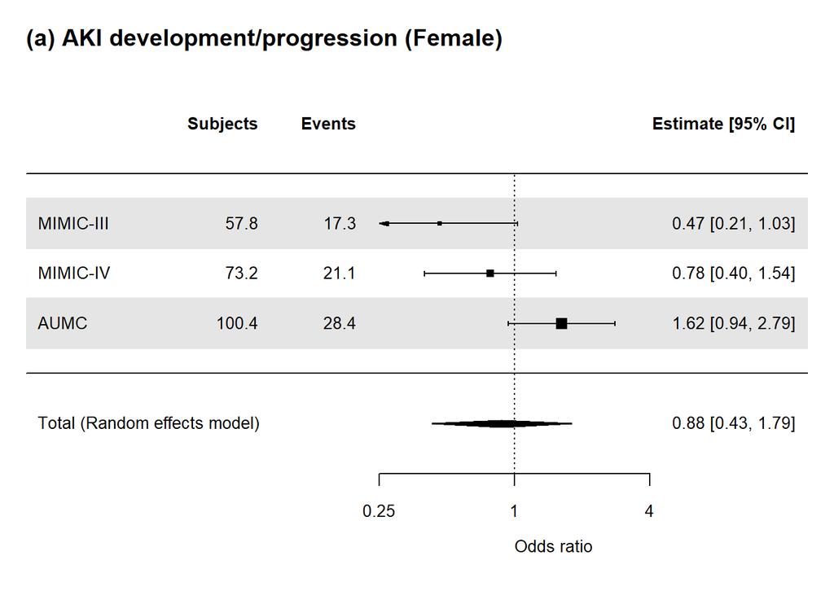

```r
FP2("wgt_man_Ovlp_MIMIC4_Female.rds", FORMULA_ovl2_sex)
FP2("wgt_man_Ovlp_MIMIC3_Female.rds", FORMULA_ovl2_sex)
FP2("wgt_man_Ovlp_AUMC_Female.rds", FORMULA_ovl2_sex)

Female_METADF0 <- rbind(
  readRDS("ORRES_wgt_man_Ovlp_MIMIC3_Female.rds") %>% mutate("dataset"="MIMIC-III"),
  readRDS("ORRES_wgt_man_Ovlp_MIMIC4_Female.rds") %>% mutate("dataset"="MIMIC-IV"),
  readRDS("ORRES_wgt_man_Ovlp_AUMC_Female.rds") %>% mutate("dataset"="AUMC"))
Female_METADF_AKID <- Female_METADF0 %>% subset(outcome=="outcome_KDIGO_inc_or_death")
Female_METADF_AKI <- Female_METADF0 %>% subset(outcome=="outcome_KDIGO_inc")
Female_METADF_HD <- Female_METADF0 %>% subset(outcome=="outcome_new_dial")
Female_METADF_D <- Female_METADF0 %>% subset(outcome=="death_in_7d")
Female_METADF_HDD <- Female_METADF0 %>% subset(outcome=="outcome_HDD_in7d")

Female_METARES_AKID <- rma(yi = Estimate, sei = Std.Error, method = "REML", data = Female_METADF_AKID)
Female_METARES_AKI <-rma(yi = Estimate, sei = Std.Error, method = "REML", data = Female_METADF_AKI)
Female_METARES_HD <- rma(yi = Estimate, sei = Std.Error, method = "REML", data = Female_METADF_HD)
Female_METARES_D <- rma(yi = Estimate, sei = Std.Error, method = "REML", data = Female_METADF_D)
Female_METARES_HDD <- rma(yi = Estimate, sei = Std.Error, method = "REML", data = Female_METADF_HDD)

METAF(Female_METARES_AKI, SCALEA1, SCALEB1, SCALEC1, "(a) AKI development/progression (Female)")
```

```r
Female_METARES_AKI
```

```
##
## Random-Effects Model (k = 3; tau^2 estimator: REML)
##
## tau^2 (estimated amount of total heterogeneity): 0.2823 (SE = 0.4001)
## tau (square root of estimated tau^2 value):      0.5313
## I^2 (total heterogeneity / total variability):   71.09%
## H^2 (total variability / sampling variability):  3.46
##
## Test for Heterogeneity:
## Q(df = 2) = 7.0420, p-val = 0.0296
##
## Model Results:
##
## estimate      se     zval    pval    ci.lb   ci.ub
##  -0.1311  0.3648  -0.3593  0.7194  -0.8461  0.5840
##
## ---
## Signif. codes:  0 '***' 0.001 '**' 0.01 '*' 0.05 '.' 0.1 ' ' 1
```

```r
Female_METADF_AKI %>% dplyr::select(dataset, OR, LCI, UCI, 'Pr(>|z|)') %>% remove_rownames()
```

```
##     dataset        OR       LCI      UCI   Pr(>|z|)
## 1 MIMIC-III 0.4654176 0.2101928 1.030547 0.05932552
## 2  MIMIC-IV 0.7829004 0.3991481 1.535603 0.47642294
## 3      AUMC 1.6186136 0.9376158 2.794226 0.08385772
```

__

#### 6c. Backgrounds, outcomes, matching quality, and forrest plot among those **younger** at treatment start.

```r
FORMULA_ovl2_age <- drug01 ~  sex + dep_type2 + sirs + pre_blood_culture + nt_drug + vasopressor + base_crea + near_crea +  base_KDIGO
comb_DF2ovl %>%dplyr::select(age_cat, age_group) %>% unique()
```

```
##    age_cat age_group
## 1       30     18-39
## 2       75     70-79
## 3       85       80+
## 6       45     40-49
## 13      55     50-59
## 38      65     60-69
```

```r
#1. overlap-PSM using MIMIC3, "Young"
OVLP(comb_DF2ovl %>% subset(dataset=="MIMIC3"&age_cat<59), FORMULA_ovl2_age, "Ovlp_MIMIC3_Young", "**Ovlp, MIMIC-III, Young**")
```

| **Characteristic** | **Ovlp, MIMIC-III, Young** **I/C** N=19.5<sup>1</sup> | **Ovlp, MIMIC-III, Young** **NCC** N=19.5<sup>1</sup> | **p-value**<sup>2</sup> |  |
| --- | --- | --- | --- | --- |
| dataset |  |  |  |  |
| MIMIC3 | 19.5 (100.0%) | 19.5 (100.0%) |  |  |
| age_group |  |  | 0.77 |  |
| 18-39 | 3.1 (15.7%) | 4.3 (21.9%) |  |  |
| 40-49 | 6.0 (30.5%) | 5.1 (26.3%) |  |  |
| 50-59 | 10.5 (53.8%) | 10.1 (51.8%) |  |  |
| sex |  |  | >0.99 |  |
| Female | 6.7 (34.1%) | 6.7 (34.1%) |  |  |
| Male | 12.9 (65.9%) | 12.9 (65.9%) |  |  |
| bmi | 28.7 (24.3, 31.6) | 28.3 (22.7, 35.7) | 0.81 |  |
| Unknown | 6 | 9 |  |  |
| weight | 83.9 (70.0, 97.0) | 80.0 (65.1, 103.0) | 0.53 |  |
| Unknown | 1 | 3 |  |  |
| ICU type |  |  | >0.99 |  |
| Non-surgery | 12.3 (63.1%) | 12.3 (63.1%) |  |  |
| Surgery | 7.2 (36.9%) | 7.2 (36.9%) |  |  |
| drug_name |  |  |  |  |
| Imipenem/cilastatin | 19.5 (100.0%) | 0.0 (0.0%) |  |  |
| Imipenem/cilastatin/relebactam | 0.0 (0.0%) | 0.0 (0.0%) |  |  |
| Meropenem | 0.0 (0.0%) | 19.5 (100.0%) |  |  |
| Doripenem | 0.0 (0.0%) | 0.0 (0.0%) |  |  |
| Ertapenem | 0.0 (0.0%) | 0.0 (0.0%) |  |  |
| Overdose in first 24h |  |  | 0.11 |  |
| not_over | 19.5 (100.0%) | 18.9 (96.6%) |  |  |
| over | 0.0 (0.0%) | 0.7 (3.4%) |  |  |
| Relative initiation dose (with near eGFR) | 0.3 (0.2, 0.5) | 0.3 (0.3, 0.5) | 0.55 |  |
| sofa | 5.0 (3.0, 9.0) | 5.0 (2.0, 9.0) | 0.45 |  |
| qsofa | 1.0 (0.0, 1.0) | 1.0 (0.0, 1.0) | 0.60 |  |
| Unknown | 0 | 1 |  |  |
| sirs | 2.0 (1.0, 3.0) | 2.0 (1.0, 3.0) | 0.96 |  |
| pre_blood_culture | 16.7 (85.2%) | 16.7 (85.2%) | >0.99 |  |
| pre nephrotoxic drugs use | 11.8 (60.2%) | 11.8 (60.2%) | >0.99 |  |
| pre vancomycin use | 10.1 (51.8%) | 11.3 (57.6%) | 0.61 |  |
| pre aminoglycosied use | 2.5 (12.8%) | 1.2 (6.2%) | 0.25 |  |
| pre NSAIDs use | 1.7 (8.7%) | 1.8 (9.0%) | 0.96 |  |
| pre contrast agent use | 0.0 (0.0%) | 0.0 (0.0%) |  |  |
| pre vasopressor use | 6.8 (34.7%) | 6.8 (34.7%) | >0.99 |  |
| pre ventilation | 12.9 (66.0%) | 13.1 (67.0%) | 0.93 |  |
| Baseline sCr | 0.8 (0.5, 1.1) | 0.7 (0.5, 1.5) | 0.83 |  |
| sCr at treatment start | 0.9 (0.7, 1.4) | 0.9 (0.6, 1.7) | 0.86 |  |
| AKI stage at treatment start |  |  | 0.28 |  |
| 0 | 15.4 (78.6%) | 15.9 (81.3%) |  |  |
| 1 | 4.2 (21.4%) | 3.1 (16.0%) |  |  |
| 2 | 0.0 (0.0%) | 0.5 (2.7%) |  |  |
| near_eGFR | 87.0 (59.3, 112.7) | 94.6 (43.9, 116.8) | 0.70 |  |
| observation time | 168.0 (168.0, 168.0) | 168.0 (168.0, 168.0) | 0.98 |  |
| Cencsored with drug change | 1.4 (7.1%) | 0.0 (0.0%) | 0.15 |  |
| RRT at treatment start | 0.0 (0.0%) | 0.0 (0.0%) |  |  |
| O, AKI develop/progress | 5.9 (30.0%) | 10.5 (53.8%) | 0.038 |  |
| O, Death | 1.2 (6.2%) | 2.5 (12.9%) | 0.33 |  |
| O, AKI d/p or death | 5.9 (30.0%) | 10.8 (55.4%) | 0.027 |  |
| O, RRT-intervention | 1.1 (5.5%) | 1.8 (9.3%) | 0.50 |  |
| O, Death or RRT-intervention | 1.9 (9.6%) | 4.1 (21.2%) | 0.17 |  |
| total_dose_ICM | 3,048.7 (2,000.0, 4,500.0) | 4,500.0 (3,370.7, 7,000.0) | 0.002 |  |
| total_dose_recabrio | NA (NA, NA) | NA (NA, NA) |  |  |
| Unknown | 20 | 20 |  |  |
| total_dose_erta | NA (NA, NA) | NA (NA, NA) |  |  |
| Unknown | 20 | 20 |  |  |
| total_dose_dori | NA (NA, NA) | NA (NA, NA) |  |  |
| Unknown | 20 | 20 |  |  |
| ini24h_dose_ICM | 500.0 (500.0, 1,000.0) | 1,000.0 (500.0, 1,000.0) | 0.008 |  |
| ini24h_dose_recabrio | NA (NA, NA) | NA (NA, NA) |  |  |
| Unknown | 20 | 20 |  |  |
| ini24h_dose_erta | NA (NA, NA) | NA (NA, NA) |  |  |
| Unknown | 20 | 20 |  |  |
| ini24h_dose_dori | NA (NA, NA) | NA (NA, NA) |  |  |
| Unknown | 20 | 20 |  |  |
| last_drug_in_obs | 168.0 (72.0, 168.0) | 168.0 (96.0, 168.0) | 0.37 |  |

<sup>1</sup> n (%); Median (Q1, Q3)  
<sup>2</sup> NA; Pearson’s X^2: Rao & Scott adjustment; Design-based KruskalWallis test

```r
#2. overlap-PSM using MIMIC4, "Young"
OVLP(comb_DF2ovl %>% subset(dataset=="miiv"&age_cat<59), FORMULA_ovl2_age, "Ovlp_MIMIC4_Young", "**Ovlp, MIMIC-IV, Young**")
```

| **Characteristic** | **Ovlp, MIMIC-IV, Young** **I/C** N=28.0<sup>1</sup> | **Ovlp, MIMIC-IV, Young** **NCC** N=28.0<sup>1</sup> | **p-value**<sup>2</sup> |  |
| --- | --- | --- | --- | --- |
| dataset |  |  |  |  |
| miiv | 28.0 (100.0%) | 28.0 (100.0%) |  |  |
| age_group |  |  | 0.30 |  |
| 18-39 | 7.7 (27.6%) | 7.1 (25.5%) |  |  |
| 40-49 | 9.7 (34.6%) | 6.6 (23.6%) |  |  |
| 50-59 | 10.6 (37.8%) | 14.3 (50.9%) |  |  |
| sex |  |  | >0.99 |  |
| Female | 9.7 (34.6%) | 9.7 (34.6%) |  |  |
| Male | 18.3 (65.4%) | 18.3 (65.4%) |  |  |
| bmi | 28.2 (25.1, 31.1) | 27.8 (23.9, 33.6) | 0.79 |  |
| Unknown | 15 | 11 |  |  |
| weight | 89.8 (72.1, 100.0) | 80.0 (67.0, 100.0) | 0.26 |  |
| Unknown | 1 | 2 |  |  |
| ICU type |  |  | >0.99 |  |
| Non-surgery | 21.3 (75.9%) | 21.3 (75.9%) |  |  |
| Surgery | 6.8 (24.1%) | 6.8 (24.1%) |  |  |
| drug_name |  |  |  |  |
| Imipenem/cilastatin | 28.0 (100.0%) | 0.0 (0.0%) |  |  |
| Imipenem/cilastatin/relebactam | 0.0 (0.0%) | 0.0 (0.0%) |  |  |
| Meropenem | 0.0 (0.0%) | 27.8 (99.3%) |  |  |
| Doripenem | 0.0 (0.0%) | 0.1 (0.3%) |  |  |
| Ertapenem | 0.0 (0.0%) | 0.1 (0.5%) |  |  |
| Overdose in first 24h |  |  | 0.16 |  |
| not_over | 27.1 (96.6%) | 27.8 (99.1%) |  |  |
| over | 1.0 (3.4%) | 0.2 (0.9%) |  |  |
| Relative initiation dose (with near eGFR) | 0.2 (0.2, 0.3) | 0.3 (0.2, 0.3) | <0.001 |  |
| sofa | 4.0 (3.0, 5.0) | 5.0 (3.0, 7.0) | 0.18 |  |
| qsofa | 1.0 (0.0, 1.0) | 1.0 (0.0, 1.0) | 0.40 |  |
| Unknown | 0 | 0 |  |  |
| sirs | 2.0 (1.0, 2.0) | 2.0 (1.0, 3.0) | 0.93 |  |
| pre_blood_culture | 18.5 (66.1%) | 18.5 (66.1%) | >0.99 |  |
| pre nephrotoxic drugs use | 22.2 (79.4%) | 22.2 (79.4%) | >0.99 |  |
| pre vancomycin use | 22.2 (79.4%) | 21.4 (76.3%) | 0.70 |  |
| pre aminoglycosied use | 0.9 (3.4%) | 2.8 (9.9%) | 0.24 |  |
| pre NSAIDs use | 2.0 (7.0%) | 2.1 (7.3%) | 0.95 |  |
| pre contrast agent use | 0.0 (0.0%) | 0.2 (0.7%) | 0.002 |  |
| pre vasopressor use | 1.0 (3.5%) | 1.0 (3.5%) | >0.99 |  |
| pre ventilation | 3.9 (14.0%) | 1.1 (4.0%) | 0.010 |  |
| Baseline sCr | 0.8 (0.5, 1.1) | 0.8 (0.5, 1.2) | 0.63 |  |
| sCr at treatment start | 0.8 (0.5, 1.5) | 0.9 (0.6, 1.3) | 0.62 |  |
| AKI stage at treatment start |  |  | 0.78 |  |
| 0 | 25.1 (89.5%) | 24.7 (88.1%) |  |  |
| 1 | 2.0 (7.1%) | 2.8 (9.8%) |  |  |
| 2 | 1.0 (3.5%) | 0.6 (2.1%) |  |  |
| near_eGFR | 111.2 (47.0, 122.1) | 102.1 (59.3, 119.2) | 0.47 |  |
| observation time | 168.0 (134.1, 168.0) | 168.0 (155.3, 168.0) | 0.24 |  |
| Cencsored with drug change | 0.0 (0.0%) | 0.0 (0.0%) |  |  |
| RRT at treatment start | 0.0 (0.0%) | 0.0 (0.0%) |  |  |
| O, AKI develop/progress | 7.8 (27.8%) | 8.0 (28.6%) | 0.92 |  |
| O, Death | 3.9 (14.0%) | 2.0 (7.2%) | 0.17 |  |
| O, AKI d/p or death | 7.8 (27.8%) | 8.8 (31.4%) | 0.68 |  |
| O, RRT-intervention | 0.0 (0.0%) | 1.3 (4.7%) | <0.001 |  |
| O, Death or RRT-intervention | 3.9 (14.0%) | 3.0 (10.7%) | 0.58 |  |
| total_dose_ICM | 1,562.5 (479.2, 3,416.7) | 2,708.3 (1,229.2, 4,166.7) | 0.003 |  |
| Unknown | 0 | 0 |  |  |
| total_dose_recabrio | NA (NA, NA) | NA (NA, NA) |  |  |
| Unknown | 28 | 28 |  |  |
| total_dose_erta | NA (NA, NA) | NA (NA, NA) |  |  |
| Unknown | 28 | 28 |  |  |
| total_dose_dori | NA (NA, NA) | NA (NA, NA) |  |  |
| Unknown | 28 | 28 |  |  |
| ini24h_dose_ICM | 500.0 (500.0, 500.0) | 1,000.0 (500.0, 1,000.0) | <0.001 |  |
| Unknown | 0 | 0 |  |  |
| ini24h_dose_recabrio | NA (NA, NA) | NA (NA, NA) |  |  |
| Unknown | 28 | 28 |  |  |
| ini24h_dose_erta | NA (NA, NA) | NA (NA, NA) |  |  |
| Unknown | 28 | 28 |  |  |
| ini24h_dose_dori | NA (NA, NA) | NA (NA, NA) |  |  |
| Unknown | 28 | 28 |  |  |
| last_drug_in_obs | 42.5 (23.0, 168.0) | 99.1 (37.0, 168.0) | 0.18 |  |

<sup>1</sup> n (%); Median (Q1, Q3)  
<sup>2</sup> NA; Pearson’s X^2: Rao & Scott adjustment; Design-based KruskalWallis test

```r
#3. overlap-PSM using AUMC, "Young"
OVLP(comb_DF2ovl %>% subset(dataset=="AUMC"&age_cat<59), FORMULA_ovl2_age, "Ovlp_AUMC_Young", paste0("**Ovlp, AUMC, Young**"))
```

| **Characteristic** | **Ovlp, AUMC, Young** **I/C** N=60.0<sup>1</sup> | **Ovlp, AUMC, Young** **NCC** N=60.0<sup>1</sup> | **p-value**<sup>2</sup> |  |
| --- | --- | --- | --- | --- |
| dataset |  |  |  |  |
| AUMC | 60.0 (100.0%) | 60.0 (100.0%) |  |  |
| age_group |  |  | 0.28 |  |
| 18-39 | 14.7 (24.4%) | 19.6 (32.8%) |  |  |
| 40-49 | 14.6 (24.4%) | 15.0 (25.1%) |  |  |
| 50-59 | 30.7 (51.1%) | 25.3 (42.1%) |  |  |
| sex |  |  | >0.99 |  |
| Female | 25.9 (43.1%) | 25.9 (43.1%) |  |  |
| Male | 34.1 (56.9%) | 34.1 (56.9%) |  |  |
| bmi | 24.5 (21.9, 27.8) | 24.5 (21.9, 27.8) | 0.39 |  |
| Unknown | 4 | 2 |  |  |
| weight | 75.0 (65.0, 85.0) | 75.0 (75.0, 95.0) | 0.50 |  |
| Unknown | 3 | 2 |  |  |
| ICU type |  |  | >0.99 |  |
| Non-surgery | 38.2 (63.8%) | 38.2 (63.8%) |  |  |
| Surgery | 21.7 (36.2%) | 21.7 (36.2%) |  |  |
| drug_name |  |  |  |  |
| Imipenem/cilastatin | 60.0 (100.0%) | 0.0 (0.0%) |  |  |
| Imipenem/cilastatin/relebactam | 0.0 (0.0%) | 0.0 (0.0%) |  |  |
| Meropenem | 0.0 (0.0%) | 60.0 (100.0%) |  |  |
| Doripenem | 0.0 (0.0%) | 0.0 (0.0%) |  |  |
| Ertapenem | 0.0 (0.0%) | 0.0 (0.0%) |  |  |
| Overdose in first 24h |  |  |  |  |
| not_over | 60.0 (100.0%) | 60.0 (100.0%) |  |  |
| Relative initiation dose (with near eGFR) | 0.2 (0.2, 0.3) | 0.5 (0.3, 0.7) | <0.001 |  |
| sofa | 7.0 (4.0, 9.0) | 6.0 (4.0, 9.0) | 0.38 |  |
| Unknown | 7 | 10 |  |  |
| qsofa | 1.0 (0.0, 1.0) | 1.0 (0.0, 1.0) | 0.56 |  |
| sirs | 2.0 (2.0, 3.0) | 2.0 (1.0, 3.0) | 0.98 |  |
| pre_blood_culture | 9.0 (14.9%) | 9.0 (14.9%) | >0.99 |  |
| pre nephrotoxic drugs use | 32.9 (55.0%) | 32.9 (55.0%) | >0.99 |  |
| pre vancomycin use | 28.8 (48.1%) | 31.7 (52.8%) | 0.46 |  |
| pre aminoglycosied use | 8.7 (14.6%) | 3.5 (5.8%) | 0.037 |  |
| pre NSAIDs use | 0.8 (1.3%) | 1.3 (2.2%) | 0.62 |  |
| pre contrast agent use | 1.0 (1.6%) | 0.0 (0.0%) | 0.089 |  |
| pre vasopressor use | 34.3 (57.3%) | 34.3 (57.3%) | >0.99 |  |
| pre ventilation | 38.8 (64.7%) | 36.4 (60.7%) | 0.52 |  |
| Baseline sCr | 0.7 (0.5, 1.0) | 0.7 (0.5, 1.1) | 0.72 |  |
| sCr at treatment start | 0.9 (0.6, 1.3) | 0.8 (0.6, 1.3) | 0.65 |  |
| AKI stage at treatment start |  |  | 0.79 |  |
| 0 | 47.8 (79.7%) | 47.0 (78.4%) |  |  |
| 1 | 9.0 (15.1%) | 10.6 (17.7%) |  |  |
| 2 | 3.1 (5.3%) | 2.4 (3.9%) |  |  |
| near_eGFR | 96.3 (61.8, 116.9) | 102.9 (66.2, 122.2) | 0.34 |  |
| observation time | 168.0 (65.8, 168.0) | 162.0 (60.0, 168.0) | 0.55 |  |
| Cencsored with drug change | 1.1 (1.9%) | 0.6 (1.0%) | 0.59 |  |
| RRT at treatment start | 0.0 (0.0%) | 0.0 (0.0%) |  |  |
| O, AKI develop/progress | 16.4 (27.4%) | 13.0 (21.6%) | 0.32 |  |
| O, Death | 5.3 (8.8%) | 7.9 (13.1%) | 0.25 |  |
| O, AKI d/p or death | 18.9 (31.5%) | 18.0 (30.0%) | 0.81 |  |
| O, RRT-intervention | 5.5 (9.1%) | 4.5 (7.5%) | 0.66 |  |
| O, Death or RRT-intervention | 8.9 (14.9%) | 10.8 (18.1%) | 0.50 |  |
| total_dose_ICM | 8,000.0 (3,500.0, 17,000.0) | 12,750.0 (5,000.0, 27,000.0) | 0.008 |  |
| total_dose_recabrio | NA (NA, NA) | NA (NA, NA) |  |  |
| Unknown | 60 | 60 |  |  |
| total_dose_erta | NA (NA, NA) | NA (NA, NA) |  |  |
| Unknown | 60 | 60 |  |  |
| total_dose_dori | NA (NA, NA) | NA (NA, NA) |  |  |
| Unknown | 60 | 60 |  |  |
| ini24h_dose_ICM | 500.0 (500.0, 500.0) | 1,000.0 (1,000.0, 2,000.0) | <0.001 |  |
| ini24h_dose_recabrio | NA (NA, NA) | NA (NA, NA) |  |  |
| Unknown | 60 | 60 |  |  |
| ini24h_dose_erta | NA (NA, NA) | NA (NA, NA) |  |  |
| Unknown | 60 | 60 |  |  |
| ini24h_dose_dori | NA (NA, NA) | NA (NA, NA) |  |  |
| Unknown | 60 | 60 |  |  |
| last_drug_in_obs | 91.2 (36.0, 168.0) | 88.9 (32.0, 168.0) | 0.34 |  |

<sup>1</sup> n (%); Median (Q1, Q3)  
<sup>2</sup> NA; Pearson’s X^2: Rao & Scott adjustment; Design-based KruskalWallis test

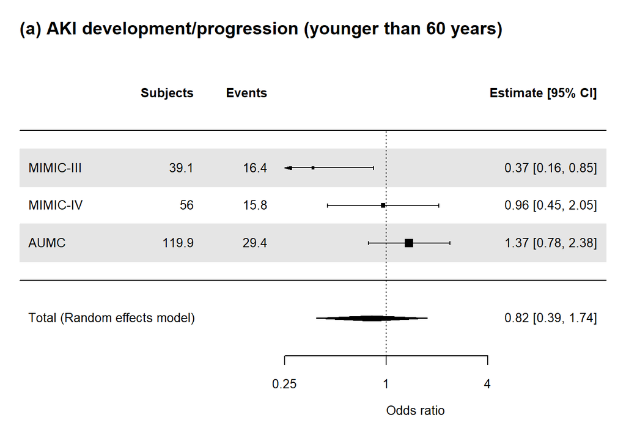

```r
#Forrestplot
FP2("wgt_man_Ovlp_MIMIC3_Young.rds", FORMULA_ovl2_age)
FP2("wgt_man_Ovlp_MIMIC4_Young.rds", FORMULA_ovl2_age)
FP2("wgt_man_Ovlp_AUMC_Young.rds", FORMULA_ovl2_age)

Young_METADF0 <- rbind(
  readRDS("ORRES_wgt_man_Ovlp_MIMIC3_Young.rds") %>% mutate("dataset"="MIMIC-III"),
  readRDS("ORRES_wgt_man_Ovlp_MIMIC4_Young.rds") %>% mutate("dataset"="MIMIC-IV"),
  readRDS("ORRES_wgt_man_Ovlp_AUMC_Young.rds") %>% mutate("dataset"="AUMC"))
Young_METADF_AKID <- Young_METADF0 %>% subset(outcome=="outcome_KDIGO_inc_or_death")
Young_METADF_AKI <- Young_METADF0 %>% subset(outcome=="outcome_KDIGO_inc")
Young_METADF_HD <- Young_METADF0 %>% subset(outcome=="outcome_new_dial")
Young_METADF_D <- Young_METADF0 %>% subset(outcome=="death_in_7d")
Young_METADF_HDD <- Young_METADF0 %>% subset(outcome=="outcome_HDD_in7d")
Young_METARES_AKID <- rma(yi = Estimate, sei = Std.Error, method = "REML", data = Young_METADF_AKID)
Young_METARES_AKI<-rma(yi = Estimate, sei = Std.Error, method = "REML", data = Young_METADF_AKI)
Young_METARES_HD<-rma(yi = Estimate, sei = Std.Error, method = "REML", data = Young_METADF_HD)
Young_METARES_D<-rma(yi = Estimate, sei = Std.Error, method = "REML", data = Young_METADF_D)
Young_METARES_HDD<-rma(yi = Estimate, sei = Std.Error, method = "REML", data = Young_METADF_HDD)

METAF(Young_METARES_AKI, SCALEA1, SCALEB1, SCALEC1, "(a) AKI development/progression (younger than 60 years)")
```

```r
Young_METARES_AKI
```

```
##
## Random-Effects Model (k = 3; tau^2 estimator: REML)
##
## tau^2 (estimated amount of total heterogeneity): 0.3101 (SE = 0.4438)
## tau (square root of estimated tau^2 value):      0.5568
## I^2 (total heterogeneity / total variability):   70.41%
## H^2 (total variability / sampling variability):  3.38
##
## Test for Heterogeneity:
## Q(df = 2) = 6.6244, p-val = 0.0364
##
## Model Results:
##
## estimate      se     zval    pval    ci.lb   ci.ub
##  -0.1967  0.3841  -0.5119  0.6087  -0.9495  0.5562
##
## ---
## Signif. codes:  0 '***' 0.001 '**' 0.01 '*' 0.05 '.' 0.1 ' ' 1
```

```r
Young_METADF_AKI %>% dplyr::select(dataset, OR, LCI, UCI, 'Pr(>|z|)') %>% remove_rownames()
```

```
##     dataset        OR       LCI       UCI  Pr(>|z|)
## 1 MIMIC-III 0.3681454 0.1603863 0.8450289 0.0184153
## 2  MIMIC-IV 0.9584982 0.4489137 2.0465377 0.9127867
## 3      AUMC 1.3665598 0.7837680 2.3827019 0.2708956
```

__

__

#### 6d. Backgrounds, outcomes, matching quality, and forest plot among those **Older**

```r
#1. overlap-PSM using MIMIC3, Older
OVLP(comb_DF2ovl %>% subset(dataset=="MIMIC3"&age_cat>58), FORMULA_ovl2_age, "Ovlp_MIMIC3_Old", "**Ovlp, MIMIC-III, Old**")
```

| **Characteristic** | **Ovlp, MIMIC-III, Old** **I/C** N=39.4<sup>1</sup> | **Ovlp, MIMIC-III, Old** **NCC** N=39.4<sup>1</sup> | **p-value**<sup>2</sup> |  |
| --- | --- | --- | --- | --- |
| dataset |  |  |  |  |
| MIMIC3 | 39.4 (100.0%) | 39.4 (100.0%) |  |  |
| age_group |  |  | 0.61 |  |
| 60-69 | 12.9 (32.8%) | 12.7 (32.3%) |  |  |
| 70-79 | 13.9 (35.3%) | 16.5 (41.9%) |  |  |
| 80+ | 12.6 (31.9%) | 10.2 (25.8%) |  |  |
| sex |  |  | >0.99 |  |
| Female | 22.0 (55.8%) | 22.0 (55.8%) |  |  |
| Male | 17.4 (44.2%) | 17.4 (44.2%) |  |  |
| bmi | 26.0 (24.9, 29.7) | 27.5 (23.1, 33.3) | 0.84 |  |
| Unknown | 21 | 21 |  |  |
| weight | 72.0 (62.6, 84.2) | 73.0 (60.7, 90.4) | 0.64 |  |
| Unknown | 7 | 7 |  |  |
| ICU type |  |  | >0.99 |  |
| Non-surgery | 23.4 (59.5%) | 23.4 (59.5%) |  |  |
| Surgery | 16.0 (40.5%) | 16.0 (40.5%) |  |  |
| drug_name |  |  |  |  |
| Imipenem/cilastatin | 39.4 (100.0%) | 0.0 (0.0%) |  |  |
| Imipenem/cilastatin/relebactam | 0.0 (0.0%) | 0.0 (0.0%) |  |  |
| Meropenem | 0.0 (0.0%) | 39.4 (100.0%) |  |  |
| Doripenem | 0.0 (0.0%) | 0.0 (0.0%) |  |  |
| Ertapenem | 0.0 (0.0%) | 0.0 (0.0%) |  |  |
| Overdose in first 24h |  |  | 0.79 |  |
| not_over | 38.6 (97.9%) | 38.8 (98.5%) |  |  |
| over | 0.8 (2.1%) | 0.6 (1.5%) |  |  |
| Relative initiation dose (with near eGFR) | 0.3 (0.3, 0.5) | 0.3 (0.3, 0.5) | 0.040 |  |
| sofa | 4.0 (3.0, 7.0) | 4.0 (2.0, 7.0) | 0.53 |  |
| qsofa | 1.0 (0.0, 1.0) | 1.0 (0.0, 1.0) | 0.92 |  |
| Unknown | 0 | 1 |  |  |
| sirs | 2.0 (1.0, 3.0) | 2.0 (1.0, 2.0) | 0.85 |  |
| pre_blood_culture | 30.6 (77.7%) | 30.6 (77.7%) | >0.99 |  |
| pre nephrotoxic drugs use | 24.3 (61.6%) | 24.3 (61.6%) | >0.99 |  |
| pre vancomycin use | 21.0 (53.2%) | 21.2 (53.8%) | 0.94 |  |
| pre aminoglycosied use | 4.2 (10.8%) | 3.4 (8.6%) | 0.64 |  |
| pre NSAIDs use | 4.2 (10.6%) | 5.4 (13.7%) | 0.57 |  |
| pre contrast agent use | 0.0 (0.0%) | 0.0 (0.0%) |  |  |
| pre vasopressor use | 17.5 (44.3%) | 17.5 (44.3%) | >0.99 |  |
| pre ventilation | 27.1 (68.7%) | 26.9 (68.3%) | 0.96 |  |
| Baseline sCr | 1.0 (0.6, 1.4) | 0.9 (0.6, 1.4) | 0.88 |  |
| sCr at treatment start | 1.1 (0.9, 1.8) | 1.1 (0.8, 1.7) | 0.69 |  |
| AKI stage at treatment start |  |  | 0.85 |  |
| 0 | 28.6 (72.7%) | 28.1 (71.4%) |  |  |
| 1 | 9.3 (23.5%) | 10.3 (26.1%) |  |  |
| 2 | 1.5 (3.8%) | 1.0 (2.6%) |  |  |
| near_eGFR | 58.8 (31.4, 83.5) | 59.3 (36.1, 87.9) | 0.69 |  |
| observation time | 168.0 (153.8, 168.0) | 168.0 (168.0, 168.0) | 0.40 |  |
| Cencsored with drug change | 0.8 (2.1%) | 0.1 (0.3%) | 0.13 |  |
| RRT at treatment start | 0.0 (0.0%) | 0.0 (0.0%) |  |  |
| O, AKI develop/progress | 8.8 (22.3%) | 12.7 (32.2%) | 0.18 |  |
| O, Death | 6.2 (15.7%) | 6.4 (16.3%) | 0.92 |  |
| O, AKI d/p or death | 12.7 (32.2%) | 15.5 (39.4%) | 0.36 |  |
| O, RRT-intervention | 0.0 (0.0%) | 1.2 (3.0%) | 0.006 |  |
| O, Death or RRT-intervention | 6.2 (15.7%) | 7.2 (18.4%) | 0.66 |  |
| total_dose_ICM | 2,500.0 (1,000.0, 3,500.0) | 4,000.0 (2,871.8, 7,000.0) | <0.001 |  |
| total_dose_recabrio | NA (NA, NA) | NA (NA, NA) |  |  |
| Unknown | 39 | 39 |  |  |
| total_dose_erta | NA (NA, NA) | NA (NA, NA) |  |  |
| Unknown | 39 | 39 |  |  |
| total_dose_dori | NA (NA, NA) | NA (NA, NA) |  |  |
| Unknown | 39 | 39 |  |  |
| ini24h_dose_ICM | 500.0 (500.0, 500.0) | 1,000.0 (500.0, 1,000.0) | <0.001 |  |
| ini24h_dose_recabrio | NA (NA, NA) | NA (NA, NA) |  |  |
| Unknown | 39 | 39 |  |  |
| ini24h_dose_erta | NA (NA, NA) | NA (NA, NA) |  |  |
| Unknown | 39 | 39 |  |  |
| ini24h_dose_dori | NA (NA, NA) | NA (NA, NA) |  |  |
| Unknown | 39 | 39 |  |  |
| last_drug_in_obs | 96.0 (48.0, 168.0) | 168.0 (72.0, 168.0) | 0.008 |  |

<sup>1</sup> n (%); Median (Q1, Q3)  
<sup>2</sup> NA; Pearson’s X^2: Rao & Scott adjustment; Design-based KruskalWallis test

```r
#2. overlap-PSM using MIMIC4, Older
OVLP(comb_DF2ovl %>% subset(dataset=="miiv"&age_cat>58), FORMULA_ovl2_age, "Ovlp_MIMIC4_Old", "**Ovlp, MIMIC-IV, Old**")
```

| **Characteristic** | **Ovlp, MIMIC-IV, Old** **I/C** N=56.7<sup>1</sup> | **Ovlp, MIMIC-IV, Old** **NCC** N=56.7<sup>1</sup> | **p-value**<sup>2</sup> |  |
| --- | --- | --- | --- | --- |
| dataset |  |  |  |  |
| miiv | 56.7 (100.0%) | 56.7 (100.0%) |  |  |
| age_group |  |  | 0.92 |  |
| 60-69 | 24.0 (42.3%) | 25.3 (44.6%) |  |  |
| 70-79 | 18.2 (32.2%) | 18.1 (31.9%) |  |  |
| 80+ | 14.5 (25.5%) | 13.3 (23.5%) |  |  |
| sex |  |  | >0.99 |  |
| Female | 26.8 (47.3%) | 26.8 (47.3%) |  |  |
| Male | 29.9 (52.7%) | 29.9 (52.7%) |  |  |
| bmi | 27.2 (25.1, 33.6) | 27.3 (23.5, 32.7) | 0.44 |  |
| Unknown | 27 | 21 |  |  |
| weight | 78.0 (68.4, 91.0) | 77.1 (63.7, 92.3) | 0.35 |  |
| Unknown | 5 | 5 |  |  |
| ICU type |  |  | >0.99 |  |
| Non-surgery | 48.8 (86.1%) | 48.8 (86.1%) |  |  |
| Surgery | 7.8 (13.9%) | 7.8 (13.9%) |  |  |
| drug_name |  |  | <0.001 |  |
| Imipenem/cilastatin | 55.7 (98.3%) | 0.0 (0.0%) |  |  |
| Imipenem/cilastatin/relebactam | 1.0 (1.7%) | 0.0 (0.0%) |  |  |
| Meropenem | 0.0 (0.0%) | 56.4 (99.5%) |  |  |
| Doripenem | 0.0 (0.0%) | 0.1 (0.2%) |  |  |
| Ertapenem | 0.0 (0.0%) | 0.2 (0.4%) |  |  |
| Overdose in first 24h |  |  | <0.001 |  |
| not_over | 56.7 (100.0%) | 56.0 (98.8%) |  |  |
| over | 0.0 (0.0%) | 0.7 (1.2%) |  |  |
| Relative initiation dose (with near eGFR) | 0.3 (0.3, 0.5) | 0.3 (0.3, 0.5) | 0.019 |  |
| sofa | 5.0 (4.0, 9.0) | 6.0 (3.0, 9.0) | 0.70 |  |
| qsofa | 1.0 (0.0, 1.0) | 1.0 (0.0, 1.0) | 0.97 |  |
| Unknown | 0 | 0 |  |  |
| sirs | 2.0 (1.0, 3.0) | 2.0 (1.0, 3.0) | 0.96 |  |
| pre_blood_culture | 46.9 (82.8%) | 46.9 (82.8%) | >0.99 |  |
| pre nephrotoxic drugs use | 44.2 (78.1%) | 44.2 (78.1%) | >0.99 |  |
| pre vancomycin use | 38.5 (67.9%) | 42.8 (75.6%) | 0.18 |  |
| pre aminoglycosied use | 7.7 (13.5%) | 3.9 (6.9%) | 0.055 |  |
| pre NSAIDs use | 3.9 (6.8%) | 4.8 (8.4%) | 0.66 |  |
| pre contrast agent use | 1.0 (1.7%) | 0.6 (1.0%) | 0.62 |  |
| pre vasopressor use | 6.7 (11.8%) | 6.7 (11.8%) | >0.99 |  |
| pre ventilation | 7.6 (13.5%) | 6.0 (10.5%) | 0.47 |  |
| Baseline sCr | 1.0 (0.7, 1.6) | 1.1 (0.7, 1.6) | 0.78 |  |
| sCr at treatment start | 1.3 (0.8, 2.3) | 1.3 (0.8, 2.0) | 0.85 |  |
| AKI stage at treatment start |  |  | >0.99 |  |
| 0 | 39.4 (69.5%) | 39.6 (69.8%) |  |  |
| 1 | 13.5 (23.8%) | 13.1 (23.2%) |  |  |
| 2 | 3.8 (6.7%) | 4.0 (7.0%) |  |  |
| near_eGFR | 55.2 (27.3, 84.7) | 52.4 (30.3, 84.7) | 0.89 |  |
| observation time | 168.0 (122.5, 168.0) | 168.0 (147.7, 168.0) | 0.91 |  |
| Cencsored with drug change | 3.9 (6.8%) | 0.0 (0.0%) | 0.038 |  |
| RRT at treatment start | 0.0 (0.0%) | 0.0 (0.0%) |  |  |
| O, AKI develop/progress | 23.0 (40.5%) | 18.6 (32.9%) | 0.22 |  |
| O, Death | 9.6 (16.9%) | 10.5 (18.6%) | 0.74 |  |
| O, AKI d/p or death | 24.9 (44.0%) | 23.3 (41.1%) | 0.66 |  |
| O, RRT-intervention | 2.8 (5.0%) | 4.0 (7.1%) | 0.53 |  |
| O, Death or RRT-intervention | 10.5 (18.5%) | 12.9 (22.7%) | 0.45 |  |
| total_dose_ICM | 1,815.3 (520.8, 3,479.2) | 2,479.2 (1,208.3, 3,812.5) | 0.015 |  |
| Unknown | 1 | 0 |  |  |
| total_dose_recabrio | NA (NA, NA) | NA (NA, NA) |  |  |
| Unknown | 56 | 57 |  |  |
| total_dose_erta | NA (NA, NA) | NA (NA, NA) |  |  |
| Unknown | 57 | 56 |  |  |
| total_dose_dori | NA (NA, NA) | NA (NA, NA) |  |  |
| Unknown | 57 | 57 |  |  |
| ini24h_dose_ICM | 500.0 (500.0, 500.0) | 1,000.0 (500.0, 1,000.0) | <0.001 |  |
| Unknown | 1 | 0 |  |  |
| ini24h_dose_recabrio | NA (NA, NA) | NA (NA, NA) |  |  |
| Unknown | 56 | 57 |  |  |
| ini24h_dose_erta | NA (NA, NA) | NA (NA, NA) |  |  |
| Unknown | 57 | 56 |  |  |
| ini24h_dose_dori | NA (NA, NA) | NA (NA, NA) |  |  |
| Unknown | 57 | 57 |  |  |
| last_drug_in_obs | 71.0 (26.0, 168.0) | 94.0 (37.0, 168.0) | 0.22 |  |

<sup>1</sup> n (%); Median (Q1, Q3)  
<sup>2</sup> NA; Pearson’s X^2: Rao & Scott adjustment; Design-based KruskalWallis test

```r
#3. overlap-PSM using AUMC, Older
OVLP(comb_DF2ovl %>% subset(dataset=="AUMC"&age_cat>58), FORMULA_ovl2_age, "Ovlp_AUMC_Old", "**Ovlp, AUMC, Old**")
```

| **Characteristic** | **Ovlp, AUMC, Old** **I/C** N=82.1<sup>1</sup> | **Ovlp, AUMC, Old** **NCC** N=82.1<sup>1</sup> | **p-value**<sup>2</sup> |  |
| --- | --- | --- | --- | --- |
| dataset |  |  |  |  |
| AUMC | 82.1 (100.0%) | 82.1 (100.0%) |  |  |
| age_group |  |  | 0.46 |  |
| 60-69 | 46.0 (56.0%) | 40.4 (49.2%) |  |  |
| 70-79 | 30.2 (36.8%) | 35.3 (43.0%) |  |  |
| 80+ | 5.9 (7.2%) | 6.4 (7.8%) |  |  |
| sex |  |  | >0.99 |  |
| Female | 26.1 (31.8%) | 26.1 (31.8%) |  |  |
| Male | 55.9 (68.2%) | 55.9 (68.2%) |  |  |
| bmi | 24.5 (21.9, 27.8) | 24.5 (21.3, 27.8) | 0.57 |  |
| Unknown | 4 | 1 |  |  |
| weight | 75.0 (65.0, 85.0) | 75.0 (65.0, 85.0) | 0.17 |  |
| Unknown | 3 | 1 |  |  |
| ICU type |  |  | >0.99 |  |
| Non-surgery | 46.6 (56.8%) | 46.6 (56.8%) |  |  |
| Surgery | 35.4 (43.2%) | 35.4 (43.2%) |  |  |
| drug_name |  |  |  |  |
| Imipenem/cilastatin | 82.1 (100.0%) | 0.0 (0.0%) |  |  |
| Imipenem/cilastatin/relebactam | 0.0 (0.0%) | 0.0 (0.0%) |  |  |
| Meropenem | 0.0 (0.0%) | 82.1 (100.0%) |  |  |
| Doripenem | 0.0 (0.0%) | 0.0 (0.0%) |  |  |
| Ertapenem | 0.0 (0.0%) | 0.0 (0.0%) |  |  |
| Overdose in first 24h |  |  | 0.74 |  |
| not_over | 80.7 (98.4%) | 81.2 (98.9%) |  |  |
| over | 1.3 (1.6%) | 0.9 (1.1%) |  |  |
| Relative initiation dose (with near eGFR) | 0.3 (0.2, 0.3) | 0.3 (0.3, 0.7) | <0.001 |  |
| sofa | 8.0 (5.0, 9.0) | 8.0 (5.0, 10.0) | 0.61 |  |
| Unknown | 13 | 15 |  |  |
| qsofa | 1.0 (0.0, 1.0) | 1.0 (0.0, 1.0) | 0.54 |  |
| Unknown | 0 | 0 |  |  |
| sirs | 2.0 (1.0, 3.0) | 2.0 (1.0, 3.0) | 0.92 |  |
| pre_blood_culture | 12.1 (14.8%) | 12.1 (14.8%) | >0.99 |  |
| pre nephrotoxic drugs use | 49.0 (59.7%) | 49.0 (59.7%) | >0.99 |  |
| pre vancomycin use | 40.2 (49.0%) | 40.3 (49.2%) | 0.98 |  |
| pre aminoglycosied use | 12.6 (15.4%) | 8.0 (9.7%) | 0.13 |  |
| pre NSAIDs use | 2.4 (2.9%) | 9.2 (11.2%) | 0.001 |  |
| pre contrast agent use | 1.5 (1.8%) | 0.0 (0.0%) | 0.028 |  |
| pre vasopressor use | 56.0 (68.2%) | 56.0 (68.2%) | >0.99 |  |
| pre ventilation | 56.5 (68.9%) | 47.8 (58.3%) | 0.045 |  |
| Baseline sCr | 0.9 (0.7, 1.3) | 0.8 (0.6, 1.2) | 0.32 |  |
| sCr at treatment start | 1.1 (0.8, 1.6) | 1.0 (0.7, 1.7) | 0.46 |  |
| AKI stage at treatment start |  |  | 0.52 |  |
| 0 | 55.8 (68.0%) | 57.6 (70.2%) |  |  |
| 1 | 21.8 (26.5%) | 18.1 (22.1%) |  |  |
| 2 | 4.5 (5.5%) | 6.3 (7.7%) |  |  |
| near_eGFR | 65.7 (40.9, 93.6) | 71.6 (37.7, 96.5) | 0.60 |  |
| observation time | 168.0 (64.0, 168.0) | 162.0 (63.3, 168.0) | 0.86 |  |
| Cencsored with drug change | 3.3 (4.0%) | 0.8 (0.9%) | 0.13 |  |
| RRT at treatment start | 0.0 (0.0%) | 0.0 (0.0%) |  |  |
| O, AKI develop/progress | 26.3 (32.0%) | 28.0 (34.1%) | 0.69 |  |
| O, Death | 13.9 (16.9%) | 10.6 (12.9%) | 0.32 |  |
| O, AKI d/p or death | 30.6 (37.3%) | 31.9 (38.8%) | 0.78 |  |
| O, RRT-intervention | 8.5 (10.3%) | 11.3 (13.8%) | 0.34 |  |
| O, Death or RRT-intervention | 19.2 (23.4%) | 16.5 (20.1%) | 0.48 |  |
| total_dose_ICM | 8,000.0 (3,000.0, 15,000.0) | 10,500.0 (5,000.0, 24,000.0) | <0.001 |  |
| total_dose_recabrio | NA (NA, NA) | NA (NA, NA) |  |  |
| Unknown | 82 | 82 |  |  |
| total_dose_erta | NA (NA, NA) | NA (NA, NA) |  |  |
| Unknown | 82 | 82 |  |  |
| total_dose_dori | NA (NA, NA) | NA (NA, NA) |  |  |
| Unknown | 82 | 82 |  |  |
| ini24h_dose_ICM | 500.0 (500.0, 500.0) | 1,000.0 (1,000.0, 1,000.0) | <0.001 |  |
| ini24h_dose_recabrio | NA (NA, NA) | NA (NA, NA) |  |  |
| Unknown | 82 | 82 |  |  |
| ini24h_dose_erta | NA (NA, NA) | NA (NA, NA) |  |  |
| Unknown | 82 | 82 |  |  |
| ini24h_dose_dori | NA (NA, NA) | NA (NA, NA) |  |  |
| Unknown | 82 | 82 |  |  |
| last_drug_in_obs | 111.0 (36.0, 168.0) | 80.0 (35.1, 168.0) | 0.35 |  |

<sup>1</sup> n (%); Median (Q1, Q3)  
<sup>2</sup> NA; Pearson’s X^2: Rao & Scott adjustment; Design-based KruskalWallis test

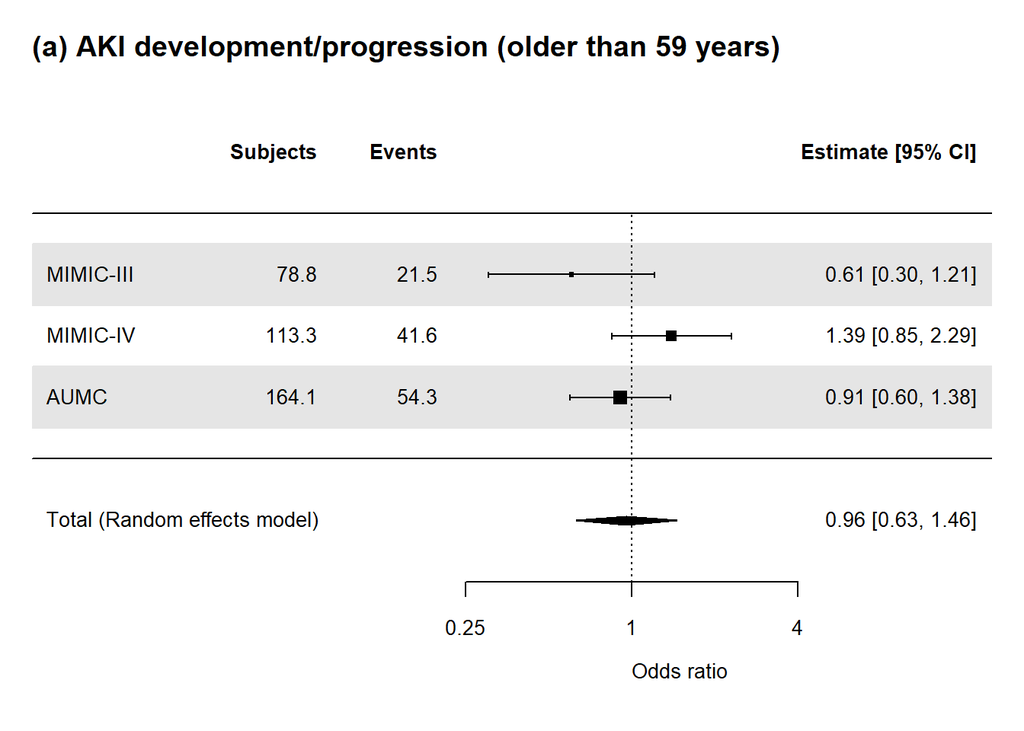

```r
FP2("wgt_man_Ovlp_MIMIC4_Old.rds", FORMULA_ovl2_age)
FP2("wgt_man_Ovlp_MIMIC3_Old.rds", FORMULA_ovl2_age)
FP2("wgt_man_Ovlp_AUMC_Old.rds", FORMULA_ovl2_age)

Old_METADF0 <- rbind(
  readRDS("ORRES_wgt_man_Ovlp_MIMIC3_Old.rds") %>% mutate("dataset"="MIMIC-III"),
  readRDS("ORRES_wgt_man_Ovlp_MIMIC4_Old.rds") %>% mutate("dataset"="MIMIC-IV"),
  readRDS("ORRES_wgt_man_Ovlp_AUMC_Old.rds") %>% mutate("dataset"="AUMC"))
Old_METADF_AKID <- Old_METADF0 %>% subset(outcome=="outcome_KDIGO_inc_or_death")
Old_METADF_AKI <- Old_METADF0 %>% subset(outcome=="outcome_KDIGO_inc")
Old_METADF_HD <- Old_METADF0 %>% subset(outcome=="outcome_new_dial")
Old_METADF_D <- Old_METADF0 %>% subset(outcome=="death_in_7d")
Old_METADF_HDD <- Old_METADF0 %>% subset(outcome=="outcome_HDD_in7d")

Old_METARES_AKID <- rma(yi = Estimate, sei = Std.Error, method = "REML", data = Old_METADF_AKID)
Old_METARES_AKI <-rma(yi = Estimate, sei = Std.Error, method = "REML", data = Old_METADF_AKI)
Old_METARES_HD <- rma(yi = Estimate, sei = Std.Error, method = "REML", data = Old_METADF_HD)
Old_METARES_D <- rma(yi = Estimate, sei = Std.Error, method = "REML", data = Old_METADF_D)
Old_METARES_HDD <- rma(yi = Estimate, sei = Std.Error, method = "REML", data = Old_METADF_HDD)

METAF(Old_METARES_AKI, SCALEA1, SCALEB1, SCALEC1, "(a) AKI development/progression (older than 59 years)")
```

```r
Old_METARES_AKI
```

```
##
## Random-Effects Model (k = 3; tau^2 estimator: REML)
##
## tau^2 (estimated amount of total heterogeneity): 0.0659 (SE = 0.1382)
## tau (square root of estimated tau^2 value):      0.2566
## I^2 (total heterogeneity / total variability):   48.14%
## H^2 (total variability / sampling variability):  1.93
##
## Test for Heterogeneity:
## Q(df = 2) = 3.9016, p-val = 0.1422
##
## Model Results:
##
## estimate      se     zval    pval    ci.lb   ci.ub
##  -0.0435  0.2137  -0.2037  0.8386  -0.4623  0.3752
##
## ---
## Signif. codes:  0 '***' 0.001 '**' 0.01 '*' 0.05 '.' 0.1 ' ' 1
```

```r
Old_METADF_AKI %>% dplyr::select(dataset, OR, LCI, UCI, 'Pr(>|z|)') %>% remove_rownames()
```

```
##     dataset        OR       LCI      UCI  Pr(>|z|)
## 1 MIMIC-III 0.6052945 0.3034113 1.207540 0.1542247
## 2  MIMIC-IV 1.3933005 0.8459307 2.294853 0.1926544
## 3      AUMC 0.9098103 0.5992460 1.381327 0.6572926
```

__

#### 7c. Backgrounds, outcomes, matching quality, and forrest plot among those **with Nephrotoxic drug** at treatment start.

```r
FORMULA_ovl2_nt <- drug01 ~  age_cat + sex + dep_type2 + sirs + pre_blood_culture + vasopressor + base_crea + near_crea +  base_KDIGO

#1. overlap-PSM using MIMIC3, "Young"
OVLP(comb_DF2ovl %>% subset(dataset=="MIMIC3"&nt_drug==T), FORMULA_ovl2_nt, "Ovlp_MIMIC3_nt", "**Ovlp, MIMIC-III, Nephrotoxic drug treated**")
```

| **Characteristic** | **Ovlp, MIMIC-III, Nephrotoxic drug treated** **I/C** N=35.9<sup>1</sup> | **Ovlp, MIMIC-III, Nephrotoxic drug treated** **NCC** N=35.9<sup>1</sup> | **p-value**<sup>2</sup> |  |
| --- | --- | --- | --- | --- |
| dataset |  |  |  |  |
| MIMIC3 | 35.9 (100.0%) | 35.9 (100.0%) |  |  |
| age_group |  |  | 0.90 |  |
| 18-39 | 1.7 (4.9%) | 2.5 (7.0%) |  |  |
| 40-49 | 3.4 (9.5%) | 3.0 (8.4%) |  |  |
| 50-59 | 6.9 (19.3%) | 4.7 (13.2%) |  |  |
| 60-69 | 6.6 (18.5%) | 8.2 (22.9%) |  |  |
| 70-79 | 9.9 (27.6%) | 10.6 (29.7%) |  |  |
| 80+ | 7.2 (20.2%) | 6.7 (18.8%) |  |  |
| sex |  |  | >0.99 |  |
| Female | 17.9 (49.8%) | 17.9 (49.8%) |  |  |
| Male | 18.0 (50.2%) | 18.0 (50.2%) |  |  |
| bmi | 27.6 (24.9, 30.6) | 27.5 (23.8, 32.0) | >0.99 |  |
| Unknown | 17 | 19 |  |  |
| weight | 78.7 (66.3, 90.8) | 75.0 (63.1, 90.0) | 0.42 |  |
| Unknown | 6 | 6 |  |  |
| ICU type |  |  | >0.99 |  |
| Non-surgery | 22.9 (64.0%) | 22.9 (64.0%) |  |  |
| Surgery | 12.9 (36.0%) | 12.9 (36.0%) |  |  |
| drug_name |  |  |  |  |
| Imipenem/cilastatin | 35.9 (100.0%) | 0.0 (0.0%) |  |  |
| Imipenem/cilastatin/relebactam | 0.0 (0.0%) | 0.0 (0.0%) |  |  |
| Meropenem | 0.0 (0.0%) | 35.9 (100.0%) |  |  |
| Doripenem | 0.0 (0.0%) | 0.0 (0.0%) |  |  |
| Ertapenem | 0.0 (0.0%) | 0.0 (0.0%) |  |  |
| Overdose in first 24h |  |  | 0.51 |  |
| not_over | 35.2 (98.1%) | 35.6 (99.1%) |  |  |
| over | 0.7 (1.9%) | 0.3 (0.9%) |  |  |
| Relative initiation dose (with near eGFR) | 0.3 (0.3, 0.5) | 0.3 (0.3, 0.5) | 0.16 |  |
| sofa | 5.0 (3.0, 9.0) | 5.0 (3.0, 8.0) | 0.56 |  |
| qsofa | 1.0 (0.0, 1.0) | 1.0 (0.0, 1.0) | 0.97 |  |
| Unknown | 0 | 0 |  |  |
| sirs | 2.0 (1.0, 3.0) | 2.0 (1.0, 3.0) | 0.91 |  |
| pre_blood_culture | 29.7 (82.7%) | 29.7 (82.7%) | >0.99 |  |
| pre nephrotoxic drugs use | 35.9 (100.0%) | 35.9 (100.0%) |  |  |
| pre vancomycin use | 30.8 (86.0%) | 32.2 (89.7%) | 0.49 |  |
| pre aminoglycosied use | 6.6 (18.5%) | 4.7 (13.1%) | 0.35 |  |
| pre NSAIDs use | 5.8 (16.1%) | 6.8 (18.9%) | 0.66 |  |
| pre contrast agent use | 0.0 (0.0%) | 0.0 (0.0%) |  |  |
| pre vasopressor use | 17.4 (48.6%) | 17.4 (48.6%) | >0.99 |  |
| pre ventilation | 25.2 (70.3%) | 25.0 (69.7%) | 0.94 |  |
| Baseline sCr | 0.9 (0.6, 1.4) | 0.9 (0.6, 1.6) | 0.93 |  |
| sCr at treatment start | 1.1 (0.8, 1.6) | 1.1 (0.7, 1.8) | 0.77 |  |
| AKI stage at treatment start |  |  | >0.99 |  |
| 0 | 27.4 (76.4%) | 27.4 (76.4%) |  |  |
| 1 | 7.6 (21.2%) | 7.6 (21.3%) |  |  |
| 2 | 0.9 (2.4%) | 0.8 (2.3%) |  |  |
| near_eGFR | 62.5 (36.1, 87.0) | 58.8 (34.1, 94.6) | 0.91 |  |
| observation time | 168.0 (166.5, 168.0) | 168.0 (168.0, 168.0) | 0.44 |  |
| Cencsored with drug change | 1.7 (4.6%) | 0.1 (0.4%) | 0.010 |  |
| RRT at treatment start | 0.0 (0.0%) | 0.0 (0.0%) |  |  |
| O, AKI develop/progress | 11.4 (31.7%) | 13.9 (38.7%) | 0.39 |  |
| O, Death | 4.8 (13.4%) | 6.0 (16.6%) | 0.59 |  |
| O, AKI d/p or death | 13.8 (38.4%) | 15.8 (44.1%) | 0.49 |  |
| O, RRT-intervention | 0.8 (2.4%) | 2.2 (6.1%) | 0.33 |  |
| O, Death or RRT-intervention | 5.6 (15.7%) | 7.6 (21.1%) | 0.42 |  |
| total_dose_ICM | 2,500.0 (1,000.0, 3,500.0) | 4,000.0 (2,386.0, 7,000.0) | <0.001 |  |
| total_dose_recabrio | NA (NA, NA) | NA (NA, NA) |  |  |
| Unknown | 36 | 36 |  |  |
| total_dose_erta | NA (NA, NA) | NA (NA, NA) |  |  |
| Unknown | 36 | 36 |  |  |
| total_dose_dori | NA (NA, NA) | NA (NA, NA) |  |  |
| Unknown | 36 | 36 |  |  |
| ini24h_dose_ICM | 500.0 (500.0, 750.0) | 1,000.0 (500.0, 1,000.0) | <0.001 |  |
| ini24h_dose_recabrio | NA (NA, NA) | NA (NA, NA) |  |  |
| Unknown | 36 | 36 |  |  |
| ini24h_dose_erta | NA (NA, NA) | NA (NA, NA) |  |  |
| Unknown | 36 | 36 |  |  |
| ini24h_dose_dori | NA (NA, NA) | NA (NA, NA) |  |  |
| Unknown | 36 | 36 |  |  |
| last_drug_in_obs | 72.0 (48.0, 168.0) | 168.0 (96.0, 168.0) | 0.009 |  |

<sup>1</sup> n (%); Median (Q1, Q3)  
<sup>2</sup> NA; Pearson’s X^2: Rao & Scott adjustment; Design-based KruskalWallis test

```r
#2. overlap-PSM using MIMIC4, "Young"
OVLP(comb_DF2ovl %>% subset(dataset=="miiv"&nt_drug==T), FORMULA_ovl2_nt, "Ovlp_MIMIC4_nt", "**Ovlp, MIMIC-IV, Nephrotoxic drug treated**")
```

| **Characteristic** | **Ovlp, MIMIC-IV, Nephrotoxic drug treated** **I/C** N=66.8<sup>1</sup> | **Ovlp, MIMIC-IV, Nephrotoxic drug treated** **NCC** N=66.8<sup>1</sup> | **p-value**<sup>2</sup> |  |
| --- | --- | --- | --- | --- |
| dataset |  |  |  |  |
| miiv | 66.8 (100.0%) | 66.8 (100.0%) |  |  |
| age_group |  |  | 0.59 |  |
| 18-39 | 5.8 (8.7%) | 5.0 (7.6%) |  |  |
| 40-49 | 7.8 (11.7%) | 6.2 (9.3%) |  |  |
| 50-59 | 8.7 (13.0%) | 14.0 (20.9%) |  |  |
| 60-69 | 18.4 (27.5%) | 17.2 (25.8%) |  |  |
| 70-79 | 16.4 (24.6%) | 13.5 (20.2%) |  |  |
| 80+ | 9.6 (14.4%) | 10.8 (16.2%) |  |  |
| sex |  |  | >0.99 |  |
| Female | 27.1 (40.6%) | 27.1 (40.6%) |  |  |
| Male | 39.7 (59.4%) | 39.7 (59.4%) |  |  |
| bmi | 28.2 (25.1, 36.1) | 27.4 (23.7, 33.2) | 0.31 |  |
| Unknown | 36 | 25 |  |  |
| weight | 84.0 (68.4, 100.0) | 78.4 (65.7, 95.2) | 0.16 |  |
| Unknown | 5 | 5 |  |  |
| ICU type |  |  | >0.99 |  |
| Non-surgery | 56.0 (83.9%) | 56.0 (83.9%) |  |  |
| Surgery | 10.8 (16.1%) | 10.8 (16.1%) |  |  |
| drug_name |  |  | <0.001 |  |
| Imipenem/cilastatin | 65.8 (98.5%) | 0.0 (0.0%) |  |  |
| Imipenem/cilastatin/relebactam | 1.0 (1.5%) | 0.0 (0.0%) |  |  |
| Meropenem | 0.0 (0.0%) | 66.3 (99.3%) |  |  |
| Doripenem | 0.0 (0.0%) | 0.1 (0.2%) |  |  |
| Ertapenem | 0.0 (0.0%) | 0.4 (0.5%) |  |  |
| Overdose in first 24h |  |  | 0.78 |  |
| not_over | 65.8 (98.5%) | 66.0 (98.9%) |  |  |
| over | 1.0 (1.5%) | 0.7 (1.1%) |  |  |
| Relative initiation dose (with near eGFR) | 0.3 (0.2, 0.3) | 0.3 (0.3, 0.5) | 0.002 |  |
| sofa | 5.0 (4.0, 8.0) | 6.0 (3.0, 9.0) | 0.45 |  |
| qsofa | 1.0 (0.0, 1.0) | 1.0 (0.0, 1.0) | 0.74 |  |
| Unknown | 0 | 0 |  |  |
| sirs | 2.0 (1.0, 3.0) | 2.0 (1.0, 3.0) | >0.99 |  |
| pre_blood_culture | 52.3 (78.3%) | 52.3 (78.3%) | >0.99 |  |
| pre nephrotoxic drugs use | 66.8 (100.0%) | 66.8 (100.0%) |  |  |
| pre vancomycin use | 61.0 (91.4%) | 64.2 (96.1%) | 0.052 |  |
| pre aminoglycosied use | 8.7 (13.0%) | 6.9 (10.4%) | 0.48 |  |
| pre NSAIDs use | 5.8 (8.7%) | 7.0 (10.4%) | 0.64 |  |
| pre contrast agent use | 0.9 (1.4%) | 0.9 (1.3%) | 0.95 |  |
| pre vasopressor use | 7.7 (11.5%) | 7.7 (11.5%) | >0.99 |  |
| pre ventilation | 10.6 (15.8%) | 6.9 (10.3%) | 0.14 |  |
| Baseline sCr | 1.0 (0.7, 1.5) | 1.0 (0.7, 1.5) | 0.89 |  |
| sCr at treatment start | 1.1 (0.7, 1.9) | 1.1 (0.8, 1.8) | 0.85 |  |
| AKI stage at treatment start |  |  | 0.92 |  |
| 0 | 51.2 (76.7%) | 50.7 (76.0%) |  |  |
| 1 | 11.7 (17.5%) | 12.7 (18.9%) |  |  |
| 2 | 3.9 (5.8%) | 3.4 (5.1%) |  |  |
| near_eGFR | 66.5 (36.5, 99.5) | 64.9 (36.4, 96.1) | 0.79 |  |
| observation time | 168.0 (101.0, 168.0) | 168.0 (147.8, 168.0) | 0.11 |  |
| Cencsored with drug change | 3.9 (5.8%) | 0.0 (0.0%) | 0.039 |  |
| RRT at treatment start | 0.0 (0.0%) | 0.0 (0.0%) |  |  |
| O, AKI develop/progress | 28.0 (41.9%) | 22.4 (33.6%) | 0.15 |  |
| O, Death | 12.5 (18.8%) | 11.5 (17.2%) | 0.74 |  |
| O, AKI d/p or death | 29.9 (44.8%) | 27.2 (40.8%) | 0.51 |  |
| O, RRT-intervention | 2.9 (4.3%) | 4.7 (7.1%) | 0.38 |  |
| O, Death or RRT-intervention | 13.5 (20.2%) | 14.4 (21.5%) | 0.80 |  |
| total_dose_ICM | 1,562.5 (468.8, 3,416.7) | 2,583.3 (1,187.5, 3,916.7) | <0.001 |  |
| Unknown | 1 | 0 |  |  |
| total_dose_recabrio | NA (NA, NA) | NA (NA, NA) |  |  |
| Unknown | 66 | 67 |  |  |
| total_dose_erta | NA (NA, NA) | NA (NA, NA) |  |  |
| Unknown | 67 | 66 |  |  |
| total_dose_dori | NA (NA, NA) | NA (NA, NA) |  |  |
| Unknown | 67 | 67 |  |  |
| ini24h_dose_ICM | 500.0 (500.0, 500.0) | 1,000.0 (500.0, 1,000.0) | <0.001 |  |
| Unknown | 1 | 0 |  |  |
| ini24h_dose_recabrio | NA (NA, NA) | NA (NA, NA) |  |  |
| Unknown | 66 | 67 |  |  |
| ini24h_dose_erta | NA (NA, NA) | NA (NA, NA) |  |  |
| Unknown | 67 | 66 |  |  |
| ini24h_dose_dori | NA (NA, NA) | NA (NA, NA) |  |  |
| Unknown | 67 | 67 |  |  |
| last_drug_in_obs | 46.0 (25.0, 162.0) | 94.0 (36.0, 168.0) | 0.037 |  |

<sup>1</sup> n (%); Median (Q1, Q3)  
<sup>2</sup> NA; Pearson’s X^2: Rao & Scott adjustment; Design-based KruskalWallis test

```r
#3. overlap-PSM using AUMC, "Young"
OVLP(comb_DF2ovl %>% subset(dataset=="AUMC"&nt_drug==T), FORMULA_ovl2_nt, "Ovlp_AUMC_nt", paste0("**Ovlp, AUMC, Nephrotoxic drug treated**"))
```

| **Characteristic** | **Ovlp, AUMC, Nephrotoxic drug treated** **I/C** N=81.7<sup>1</sup> | **Ovlp, AUMC, Nephrotoxic drug treated** **NCC** N=81.7<sup>1</sup> | **p-value**<sup>2</sup> |  |
| --- | --- | --- | --- | --- |
| dataset |  |  |  |  |
| AUMC | 81.7 (100.0%) | 81.7 (100.0%) |  |  |
| age_group |  |  | 0.81 |  |
| 18-39 | 7.7 (9.5%) | 9.7 (11.9%) |  |  |
| 40-49 | 9.8 (12.0%) | 7.7 (9.4%) |  |  |
| 50-59 | 17.4 (21.3%) | 15.0 (18.4%) |  |  |
| 60-69 | 24.2 (29.6%) | 25.0 (30.6%) |  |  |
| 70-79 | 19.5 (23.9%) | 22.3 (27.3%) |  |  |
| 80+ | 3.1 (3.8%) | 1.9 (2.4%) |  |  |
| sex |  |  | >0.99 |  |
| Female | 25.9 (31.8%) | 25.9 (31.8%) |  |  |
| Male | 55.8 (68.2%) | 55.8 (68.2%) |  |  |
| bmi | 24.8 (21.9, 27.8) | 24.8 (21.9, 27.8) | 0.95 |  |
| Unknown | 3 | 1 |  |  |
| weight | 75.0 (75.0, 85.0) | 85.0 (65.0, 95.0) | 0.53 |  |
| Unknown | 3 | 1 |  |  |
| ICU type |  |  | >0.99 |  |
| Non-surgery | 44.6 (54.5%) | 44.6 (54.5%) |  |  |
| Surgery | 37.2 (45.5%) | 37.2 (45.5%) |  |  |
| drug_name |  |  |  |  |
| Imipenem/cilastatin | 81.7 (100.0%) | 0.0 (0.0%) |  |  |
| Imipenem/cilastatin/relebactam | 0.0 (0.0%) | 0.0 (0.0%) |  |  |
| Meropenem | 0.0 (0.0%) | 81.7 (100.0%) |  |  |
| Doripenem | 0.0 (0.0%) | 0.0 (0.0%) |  |  |
| Ertapenem | 0.0 (0.0%) | 0.0 (0.0%) |  |  |
| Overdose in first 24h |  |  | 0.87 |  |
| not_over | 80.9 (99.0%) | 80.8 (98.8%) |  |  |
| over | 0.8 (1.0%) | 0.9 (1.2%) |  |  |
| Relative initiation dose (with near eGFR) | 0.3 (0.2, 0.3) | 0.3 (0.3, 0.7) | <0.001 |  |
| sofa | 7.0 (4.0, 9.0) | 7.0 (4.0, 9.0) | 0.89 |  |
| Unknown | 10 | 15 |  |  |
| qsofa | 1.0 (0.0, 1.0) | 1.0 (0.0, 1.0) | 0.72 |  |
| sirs | 2.0 (1.0, 3.0) | 2.0 (1.0, 3.0) | 0.97 |  |
| pre_blood_culture | 13.3 (16.3%) | 13.3 (16.3%) | >0.99 |  |
| pre nephrotoxic drugs use | 81.7 (100.0%) | 81.7 (100.0%) |  |  |
| pre vancomycin use | 68.4 (83.8%) | 71.8 (87.9%) | 0.31 |  |
| pre aminoglycosied use | 21.7 (26.5%) | 11.2 (13.7%) | 0.006 |  |
| pre NSAIDs use | 3.3 (4.1%) | 11.0 (13.4%) | 0.002 |  |
| pre contrast agent use | 2.4 (3.0%) | 0.0 (0.0%) | 0.007 |  |
| pre vasopressor use | 54.2 (66.4%) | 54.2 (66.4%) | >0.99 |  |
| pre ventilation | 57.9 (70.9%) | 51.2 (62.7%) | 0.11 |  |
| Baseline sCr | 0.8 (0.6, 1.1) | 0.7 (0.5, 1.1) | 0.12 |  |
| sCr at treatment start | 1.0 (0.7, 1.4) | 0.9 (0.6, 1.5) | 0.14 |  |
| AKI stage at treatment start |  |  | 0.98 |  |
| 0 | 60.6 (74.2%) | 60.9 (74.5%) |  |  |
| 1 | 16.2 (19.8%) | 15.6 (19.1%) |  |  |
| 2 | 4.9 (6.0%) | 5.2 (6.4%) |  |  |
| near_eGFR | 79.6 (53.8, 101.1) | 90.7 (49.9, 108.0) | 0.18 |  |
| observation time | 168.0 (92.3, 168.0) | 168.0 (70.6, 168.0) | 0.31 |  |
| Cencsored with drug change | 2.0 (2.4%) | 0.8 (1.0%) | 0.38 |  |
| RRT at treatment start | 0.0 (0.0%) | 0.0 (0.0%) |  |  |
| O, AKI develop/progress | 27.8 (34.1%) | 25.1 (30.8%) | 0.53 |  |
| O, Death | 10.8 (13.2%) | 10.5 (12.9%) | 0.92 |  |
| O, AKI d/p or death | 32.0 (39.1%) | 28.9 (35.4%) | 0.49 |  |
| O, RRT-intervention | 8.3 (10.1%) | 9.2 (11.3%) | 0.73 |  |
| O, Death or RRT-intervention | 16.9 (20.7%) | 14.5 (17.8%) | 0.52 |  |
| total_dose_ICM | 10,000.0 (4,000.0, 18,500.0) | 13,500.0 (6,000.0, 30,000.0) | 0.001 |  |
| total_dose_recabrio | NA (NA, NA) | NA (NA, NA) |  |  |
| Unknown | 82 | 82 |  |  |
| total_dose_erta | NA (NA, NA) | NA (NA, NA) |  |  |
| Unknown | 82 | 82 |  |  |
| total_dose_dori | NA (NA, NA) | NA (NA, NA) |  |  |
| Unknown | 82 | 82 |  |  |
| ini24h_dose_ICM | 500.0 (500.0, 500.0) | 1,000.0 (1,000.0, 2,000.0) | <0.001 |  |
| ini24h_dose_recabrio | NA (NA, NA) | NA (NA, NA) |  |  |
| Unknown | 82 | 82 |  |  |
| ini24h_dose_erta | NA (NA, NA) | NA (NA, NA) |  |  |
| Unknown | 82 | 82 |  |  |
| ini24h_dose_dori | NA (NA, NA) | NA (NA, NA) |  |  |
| Unknown | 82 | 82 |  |  |
| last_drug_in_obs | 134.0 (45.7, 168.0) | 99.2 (39.7, 168.0) | 0.34 |  |

<sup>1</sup> n (%); Median (Q1, Q3)  
<sup>2</sup> NA; Pearson’s X^2: Rao & Scott adjustment; Design-based KruskalWallis test

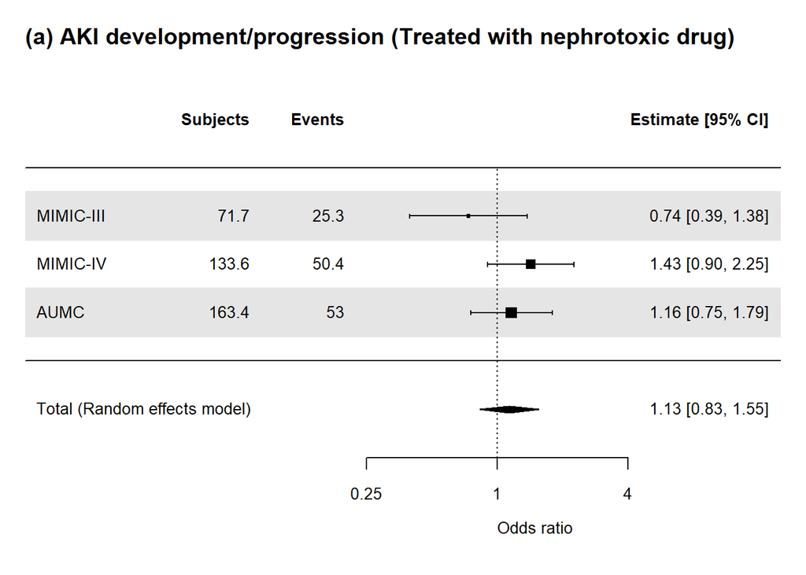

```r
#Forrestplot
FP2("wgt_man_Ovlp_MIMIC3_nt.rds", FORMULA_ovl2_nt)
FP2("wgt_man_Ovlp_MIMIC4_nt.rds", FORMULA_ovl2_nt)
FP2("wgt_man_Ovlp_AUMC_nt.rds", FORMULA_ovl2_nt)

nt_METADF0 <- rbind(
  readRDS("ORRES_wgt_man_Ovlp_MIMIC3_nt.rds") %>% mutate("dataset"="MIMIC-III"),
  readRDS("ORRES_wgt_man_Ovlp_MIMIC4_nt.rds") %>% mutate("dataset"="MIMIC-IV"),
  readRDS("ORRES_wgt_man_Ovlp_AUMC_nt.rds") %>% mutate("dataset"="AUMC"))
nt_METADF_AKID <- nt_METADF0 %>% subset(outcome=="outcome_KDIGO_inc_or_death")
nt_METADF_AKI <- nt_METADF0 %>% subset(outcome=="outcome_KDIGO_inc")
nt_METADF_HD <- nt_METADF0 %>% subset(outcome=="outcome_new_dial")
nt_METADF_D <- nt_METADF0 %>% subset(outcome=="death_in_7d")
nt_METADF_HDD <- nt_METADF0 %>% subset(outcome=="outcome_HDD_in7d")
nt_METARES_AKID <- rma(yi = Estimate, sei = Std.Error, method = "REML", data = nt_METADF_AKID)
nt_METARES_AKI<-rma(yi = Estimate, sei = Std.Error, method = "REML", data = nt_METADF_AKI)
nt_METARES_HD<-rma(yi = Estimate, sei = Std.Error, method = "REML", data = nt_METADF_HD)
nt_METARES_D<-rma(yi = Estimate, sei = Std.Error, method = "REML", data = nt_METADF_D)
nt_METARES_HDD<-rma(yi = Estimate, sei = Std.Error, method = "REML", data = nt_METADF_HDD)

METAF(nt_METARES_AKI, SCALEA1, SCALEB1, SCALEC1, "(a) AKI development/progression (Treated with nephrotoxic drug)")
```

```r
nt_METARES_AKI
```

```
##
## Random-Effects Model (k = 3; tau^2 estimator: REML)
##
## tau^2 (estimated amount of total heterogeneity): 0.0133 (SE = 0.0764)
## tau (square root of estimated tau^2 value):      0.1152
## I^2 (total heterogeneity / total variability):   17.17%
## H^2 (total variability / sampling variability):  1.21
##
## Test for Heterogeneity:
## Q(df = 2) = 2.7980, p-val = 0.2468
##
## Model Results:
##
## estimate      se    zval    pval    ci.lb   ci.ub
##   0.1260  0.1588  0.7933  0.4276  -0.1853  0.4373
##
## ---
## Signif. codes:  0 '***' 0.001 '**' 0.01 '*' 0.05 '.' 0.1 ' ' 1
```

```r
nt_METADF_AKI %>% dplyr::select(dataset, OR, LCI, UCI, 'Pr(>|z|)') %>% remove_rownames()
```

```
##     dataset        OR       LCI      UCI  Pr(>|z|)
## 1 MIMIC-III 0.7371679 0.3949887 1.375777 0.3381286
## 2  MIMIC-IV 1.4254952 0.9019654 2.252899 0.1289820
## 3      AUMC 1.1618961 0.7544672 1.789346 0.4958050
```

__

__

#### 7d. Backgrounds, outcomes, matching quality, and forest plot among those **no nephrotoxic drug**

```r
#1. overlap-PSM using MIMIC3, Older
OVLP(comb_DF2ovl %>% subset(dataset=="MIMIC3"&nt_drug==F), FORMULA_ovl2_nt, "Ovlp_MIMIC3_nont", "**Ovlp, MIMIC-III, No nephrotoxic drug**")
```

| **Characteristic** | **Ovlp, MIMIC-III, No nephrotoxic drug** **I/C** N=22.7<sup>1</sup> | **Ovlp, MIMIC-III, No nephrotoxic drug** **NCC** N=22.7<sup>1</sup> | **p-value**<sup>2</sup> |  |
| --- | --- | --- | --- | --- |
| dataset |  |  |  |  |
| MIMIC3 | 22.7 (100.0%) | 22.7 (100.0%) |  |  |
| age_group |  |  | 0.80 |  |
| 18-39 | 1.5 (6.4%) | 1.7 (7.7%) |  |  |
| 40-49 | 2.8 (12.5%) | 1.8 (7.7%) |  |  |
| 50-59 | 3.3 (14.7%) | 4.8 (21.0%) |  |  |
| 60-69 | 6.5 (28.5%) | 4.8 (21.3%) |  |  |
| 70-79 | 3.9 (17.0%) | 5.6 (24.8%) |  |  |
| 80+ | 4.7 (20.9%) | 4.0 (17.5%) |  |  |
| sex |  |  | >0.99 |  |
| Female | 10.8 (47.7%) | 10.8 (47.7%) |  |  |
| Male | 11.9 (52.3%) | 11.9 (52.3%) |  |  |
| bmi | 26.3 (24.5, 34.6) | 28.5 (21.8, 36.0) | 0.86 |  |
| Unknown | 9 | 12 |  |  |
| weight | 75.0 (65.0, 88.5) | 80.0 (61.0, 102.0) | 0.50 |  |
| Unknown | 2 | 3 |  |  |
| ICU type |  |  | >0.99 |  |
| Non-surgery | 12.9 (56.8%) | 12.9 (56.8%) |  |  |
| Surgery | 9.8 (43.2%) | 9.8 (43.2%) |  |  |
| drug_name |  |  |  |  |
| Imipenem/cilastatin | 22.7 (100.0%) | 0.0 (0.0%) |  |  |
| Imipenem/cilastatin/relebactam | 0.0 (0.0%) | 0.0 (0.0%) |  |  |
| Meropenem | 0.0 (0.0%) | 22.7 (100.0%) |  |  |
| Doripenem | 0.0 (0.0%) | 0.0 (0.0%) |  |  |
| Ertapenem | 0.0 (0.0%) | 0.0 (0.0%) |  |  |
| Overdose in first 24h |  |  | 0.12 |  |
| not_over | 22.7 (100.0%) | 22.0 (97.2%) |  |  |
| over | 0.0 (0.0%) | 0.6 (2.8%) |  |  |
| Relative initiation dose (with near eGFR) | 0.3 (0.2, 0.5) | 0.3 (0.3, 0.5) | 0.19 |  |
| sofa | 4.0 (2.0, 7.0) | 4.0 (2.0, 7.0) | 0.47 |  |
| qsofa | 1.0 (0.0, 1.0) | 1.0 (0.0, 1.0) | 0.72 |  |
| Unknown | 0 | 2 |  |  |
| sirs | 2.0 (1.0, 3.0) | 2.0 (1.0, 3.0) | 0.83 |  |
| pre_blood_culture | 16.9 (74.4%) | 16.9 (74.4%) | >0.99 |  |
| pre nephrotoxic drugs use | 0.0 (0.0%) | 0.0 (0.0%) |  |  |
| pre vancomycin use | 0.0 (0.0%) | 0.0 (0.0%) |  |  |
| pre aminoglycosied use | 0.0 (0.0%) | 0.0 (0.0%) |  |  |
| pre NSAIDs use | 0.0 (0.0%) | 0.0 (0.0%) |  |  |
| pre contrast agent use | 0.0 (0.0%) | 0.0 (0.0%) |  |  |
| pre vasopressor use | 7.2 (31.9%) | 7.2 (31.9%) | >0.99 |  |
| pre ventilation | 14.6 (64.5%) | 14.6 (64.4%) | >0.99 |  |
| Baseline sCr | 0.9 (0.5, 1.4) | 0.9 (0.6, 1.3) | 0.93 |  |
| sCr at treatment start | 1.1 (0.8, 1.8) | 1.0 (0.7, 1.6) | 0.80 |  |
| AKI stage at treatment start |  |  | 0.97 |  |
| 0 | 16.7 (73.5%) | 16.8 (74.1%) |  |  |
| 1 | 5.5 (24.3%) | 5.2 (23.1%) |  |  |
| 2 | 0.5 (2.2%) | 0.6 (2.8%) |  |  |
| near_eGFR | 66.7 (36.0, 98.2) | 70.9 (44.2, 95.9) | 0.86 |  |
| observation time | 168.0 (153.8, 168.0) | 168.0 (168.0, 168.0) | 0.83 |  |
| Cencsored with drug change | 0.6 (2.8%) | 0.0 (0.0%) | 0.32 |  |
| RRT at treatment start | 0.0 (0.0%) | 0.0 (0.0%) |  |  |
| O, AKI develop/progress | 3.7 (16.4%) | 9.9 (43.7%) | 0.010 |  |
| O, Death | 2.6 (11.5%) | 3.2 (14.2%) | 0.70 |  |
| O, AKI d/p or death | 4.9 (21.6%) | 11.0 (48.6%) | 0.012 |  |
| O, RRT-intervention | 0.8 (3.3%) | 0.9 (3.9%) | 0.90 |  |
| O, Death or RRT-intervention | 2.6 (11.5%) | 4.1 (18.1%) | 0.39 |  |
| total_dose_ICM | 3,000.0 (2,000.0, 3,500.0) | 4,940.4 (3,000.0, 7,000.0) | <0.001 |  |
| total_dose_recabrio | NA (NA, NA) | NA (NA, NA) |  |  |
| Unknown | 23 | 23 |  |  |
| total_dose_erta | NA (NA, NA) | NA (NA, NA) |  |  |
| Unknown | 23 | 23 |  |  |
| total_dose_dori | NA (NA, NA) | NA (NA, NA) |  |  |
| Unknown | 23 | 23 |  |  |
| ini24h_dose_ICM | 500.0 (500.0, 1,000.0) | 1,000.0 (500.0, 1,000.0) | <0.001 |  |
| ini24h_dose_recabrio | NA (NA, NA) | NA (NA, NA) |  |  |
| Unknown | 23 | 23 |  |  |
| ini24h_dose_erta | NA (NA, NA) | NA (NA, NA) |  |  |
| Unknown | 23 | 23 |  |  |
| ini24h_dose_dori | NA (NA, NA) | NA (NA, NA) |  |  |
| Unknown | 23 | 23 |  |  |
| last_drug_in_obs | 144.0 (72.0, 168.0) | 168.0 (76.4, 168.0) | 0.47 |  |

<sup>1</sup> n (%); Median (Q1, Q3)  
<sup>2</sup> NA; Pearson’s X^2: Rao & Scott adjustment; Design-based KruskalWallis test

```r
#2. overlap-PSM using MIMIC4, Older
OVLP(comb_DF2ovl %>% subset(dataset=="miiv"&nt_drug==F), FORMULA_ovl2_nt, "Ovlp_MIMIC4_nont", "**Ovlp, MIMIC-IV, No nephrotoxic drug**")
```

| **Characteristic** | **Ovlp, MIMIC-IV, No nephrotoxic drug** **I/C** N=18.2<sup>1</sup> | **Ovlp, MIMIC-IV, No nephrotoxic drug** **NCC** N=18.2<sup>1</sup> | **p-value**<sup>2</sup> |  |
| --- | --- | --- | --- | --- |
| dataset |  |  |  |  |
| miiv | 18.2 (100.0%) | 18.2 (100.0%) |  |  |
| age_group |  |  | 0.83 |  |
| 18-39 | 1.9 (10.6%) | 1.6 (8.7%) |  |  |
| 40-49 | 1.9 (10.7%) | 1.6 (9.0%) |  |  |
| 50-59 | 1.9 (10.7%) | 2.8 (15.2%) |  |  |
| 60-69 | 5.7 (31.4%) | 5.2 (28.3%) |  |  |
| 70-79 | 1.9 (10.4%) | 3.7 (20.4%) |  |  |
| 80+ | 4.8 (26.1%) | 3.3 (18.3%) |  |  |
| sex |  |  | >0.99 |  |
| Female | 9.5 (52.2%) | 9.5 (52.2%) |  |  |
| Male | 8.7 (47.8%) | 8.7 (47.8%) |  |  |
| bmi | 26.4 (25.3, 30.0) | 27.5 (22.6, 32.4) | 0.96 |  |
| Unknown | 7 | 7 |  |  |
| weight | 78.5 (71.0, 89.8) | 76.2 (61.7, 94.1) | 0.61 |  |
| Unknown | 1 | 2 |  |  |
| ICU type |  |  | >0.99 |  |
| Non-surgery | 14.3 (78.8%) | 14.3 (78.8%) |  |  |
| Surgery | 3.9 (21.2%) | 3.9 (21.2%) |  |  |
| drug_name |  |  |  |  |
| Imipenem/cilastatin | 18.2 (100.0%) | 0.0 (0.0%) |  |  |
| Imipenem/cilastatin/relebactam | 0.0 (0.0%) | 0.0 (0.0%) |  |  |
| Meropenem | 0.0 (0.0%) | 18.1 (99.6%) |  |  |
| Doripenem | 0.0 (0.0%) | 0.0 (0.0%) |  |  |
| Ertapenem | 0.0 (0.0%) | 0.1 (0.4%) |  |  |
| Overdose in first 24h |  |  | 0.035 |  |
| not_over | 18.2 (100.0%) | 18.0 (99.1%) |  |  |
| over | 0.0 (0.0%) | 0.2 (0.9%) |  |  |
| Relative initiation dose (with near eGFR) | 0.3 (0.2, 0.3) | 0.3 (0.2, 0.5) | 0.075 |  |
| sofa | 4.0 (2.0, 5.0) | 4.0 (3.0, 7.0) | 0.14 |  |
| qsofa | 1.0 (0.0, 1.0) | 1.0 (0.0, 1.0) | 0.75 |  |
| sirs | 2.0 (1.0, 3.0) | 2.0 (1.0, 3.0) | 0.88 |  |
| pre_blood_culture | 13.3 (73.3%) | 13.3 (73.3%) | >0.99 |  |
| pre nephrotoxic drugs use | 0.0 (0.0%) | 0.0 (0.0%) |  |  |
| pre vancomycin use | 0.0 (0.0%) | 0.0 (0.0%) |  |  |
| pre aminoglycosied use | 0.0 (0.0%) | 0.0 (0.0%) |  |  |
| pre NSAIDs use | 0.0 (0.0%) | 0.0 (0.0%) |  |  |
| pre contrast agent use | 0.0 (0.0%) | 0.0 (0.0%) |  |  |
| pre vasopressor use | 0.0 (0.0%) | 0.0 (0.0%) | <0.001 |  |
| pre ventilation | 1.0 (5.3%) | 0.3 (1.8%) | 0.28 |  |
| Baseline sCr | 1.0 (0.5, 1.7) | 0.9 (0.6, 1.4) | 0.89 |  |
| sCr at treatment start | 1.1 (0.6, 2.0) | 1.0 (0.6, 1.7) | 0.99 |  |
| AKI stage at treatment start |  |  | 0.98 |  |
| 0 | 13.4 (73.7%) | 13.5 (74.4%) |  |  |
| 1 | 3.8 (21.0%) | 3.6 (19.6%) |  |  |
| 2 | 1.0 (5.3%) | 1.1 (5.9%) |  |  |
| near_eGFR | 62.5 (32.4, 99.5) | 72.2 (35.2, 99.5) | >0.99 |  |
| observation time | 168.0 (168.0, 168.0) | 168.0 (160.9, 168.0) | 0.030 |  |
| Cencsored with drug change | 0.0 (0.0%) | 0.0 (0.0%) |  |  |
| RRT at treatment start | 0.0 (0.0%) | 0.0 (0.0%) |  |  |
| O, AKI develop/progress | 2.9 (15.8%) | 4.6 (25.0%) | 0.36 |  |
| O, Death | 1.0 (5.3%) | 0.9 (5.1%) | 0.97 |  |
| O, AKI d/p or death | 2.9 (15.8%) | 5.0 (27.7%) | 0.26 |  |
| O, RRT-intervention | 0.0 (0.0%) | 0.9 (5.1%) | <0.001 |  |
| O, Death or RRT-intervention | 1.0 (5.3%) | 1.7 (9.5%) | 0.54 |  |
| total_dose_ICM | 2,958.3 (729.2, 3,500.0) | 2,312.5 (1,250.0, 3,854.2) | 0.39 |  |
| Unknown | 0 | 0 |  |  |
| total_dose_recabrio | NA (NA, NA) | NA (NA, NA) |  |  |
| Unknown | 18 | 18 |  |  |
| total_dose_erta | NA (NA, NA) | NA (NA, NA) |  |  |
| Unknown | 18 | 18 |  |  |
| total_dose_dori | NA (NA, NA) | NA (NA, NA) |  |  |
| Unknown | 18 | 18 |  |  |
| ini24h_dose_ICM | 500.0 (500.0, 500.0) | 1,000.0 (500.0, 1,000.0) | <0.001 |  |
| Unknown | 0 | 0 |  |  |
| ini24h_dose_recabrio | NA (NA, NA) | NA (NA, NA) |  |  |
| Unknown | 18 | 18 |  |  |
| ini24h_dose_erta | NA (NA, NA) | NA (NA, NA) |  |  |
| Unknown | 18 | 18 |  |  |
| ini24h_dose_dori | NA (NA, NA) | NA (NA, NA) |  |  |
| Unknown | 18 | 18 |  |  |
| last_drug_in_obs | 142.0 (35.0, 168.0) | 94.0 (41.0, 168.0) | 0.83 |  |

<sup>1</sup> n (%); Median (Q1, Q3)  
<sup>2</sup> NA; Pearson’s X^2: Rao & Scott adjustment; Design-based KruskalWallis test

```r
#3. overlap-PSM using AUMC, Older
OVLP(comb_DF2ovl %>% subset(dataset=="AUMC"&nt_drug==F), FORMULA_ovl2_nt, "Ovlp_AUMC_nont", "**Ovlp, AUMC, No nephrotoxic drug**")
```

| **Characteristic** | **Ovlp, AUMC, No nephrotoxic drug** **I/C** N=59.8<sup>1</sup> | **Ovlp, AUMC, No nephrotoxic drug** **NCC** N=59.8<sup>1</sup> | **p-value**<sup>2</sup> |  |
| --- | --- | --- | --- | --- |
| dataset |  |  |  |  |
| AUMC | 59.8 (100.0%) | 59.8 (100.0%) |  |  |
| age_group |  |  | 0.16 |  |
| 18-39 | 7.5 (12.6%) | 10.3 (17.2%) |  |  |
| 40-49 | 5.1 (8.6%) | 6.9 (11.6%) |  |  |
| 50-59 | 14.8 (24.7%) | 9.6 (16.0%) |  |  |
| 60-69 | 20.3 (33.9%) | 14.9 (25.0%) |  |  |
| 70-79 | 9.5 (15.9%) | 13.6 (22.8%) |  |  |
| 80+ | 2.6 (4.3%) | 4.5 (7.5%) |  |  |
| sex |  |  | >0.99 |  |
| Female | 24.9 (41.6%) | 24.9 (41.6%) |  |  |
| Male | 35.0 (58.4%) | 35.0 (58.4%) |  |  |
| bmi | 24.5 (21.2, 27.5) | 24.5 (21.9, 27.8) | 0.17 |  |
| Unknown | 5 | 2 |  |  |
| weight | 75.0 (65.0, 85.0) | 75.0 (65.0, 85.0) | 0.25 |  |
| Unknown | 3 | 2 |  |  |
| ICU type |  |  | >0.99 |  |
| Non-surgery | 39.6 (66.2%) | 39.6 (66.2%) |  |  |
| Surgery | 20.2 (33.8%) | 20.2 (33.8%) |  |  |
| drug_name |  |  |  |  |
| Imipenem/cilastatin | 59.8 (100.0%) | 0.0 (0.0%) |  |  |
| Imipenem/cilastatin/relebactam | 0.0 (0.0%) | 0.0 (0.0%) |  |  |
| Meropenem | 0.0 (0.0%) | 59.8 (100.0%) |  |  |
| Doripenem | 0.0 (0.0%) | 0.0 (0.0%) |  |  |
| Ertapenem | 0.0 (0.0%) | 0.0 (0.0%) |  |  |
| Overdose in first 24h |  |  |  |  |
| not_over | 59.8 (100.0%) | 59.8 (100.0%) |  |  |
| Relative initiation dose (with near eGFR) | 0.3 (0.2, 0.3) | 0.5 (0.3, 0.7) | <0.001 |  |
| sofa | 7.0 (5.0, 10.0) | 7.0 (4.0, 9.0) | 0.62 |  |
| Unknown | 10 | 10 |  |  |
| qsofa | 1.0 (0.0, 1.0) | 1.0 (0.0, 1.0) | 0.78 |  |
| Unknown | 0 | 0 |  |  |
| sirs | 2.0 (2.0, 3.0) | 2.0 (1.0, 3.0) | 0.93 |  |
| pre_blood_culture | 7.8 (13.0%) | 7.8 (13.0%) | >0.99 |  |
| pre nephrotoxic drugs use | 0.0 (0.0%) | 0.0 (0.0%) |  |  |
| pre vancomycin use | 0.0 (0.0%) | 0.0 (0.0%) |  |  |
| pre aminoglycosied use | 0.0 (0.0%) | 0.0 (0.0%) |  |  |
| pre NSAIDs use | 0.0 (0.0%) | 0.0 (0.0%) |  |  |
| pre contrast agent use | 0.0 (0.0%) | 0.0 (0.0%) |  |  |
| pre vasopressor use | 36.2 (60.5%) | 36.2 (60.5%) | >0.99 |  |
| pre ventilation | 36.5 (61.0%) | 33.5 (56.1%) | 0.43 |  |
| Baseline sCr | 0.9 (0.6, 1.3) | 0.8 (0.6, 1.2) | 0.76 |  |
| sCr at treatment start | 1.1 (0.7, 1.6) | 1.0 (0.7, 1.6) | 0.92 |  |
| AKI stage at treatment start |  |  | 0.92 |  |
| 0 | 43.2 (72.3%) | 43.7 (73.1%) |  |  |
| 1 | 13.6 (22.8%) | 12.6 (21.1%) |  |  |
| 2 | 3.0 (5.0%) | 3.5 (5.8%) |  |  |
| near_eGFR | 72.9 (42.1, 103.8) | 75.0 (40.1, 107.3) | 0.85 |  |
| observation time | 98.7 (39.7, 168.0) | 116.0 (45.5, 168.0) | 0.61 |  |
| Cencsored with drug change | 2.0 (3.4%) | 0.6 (1.0%) | 0.22 |  |
| RRT at treatment start | 0.0 (0.0%) | 0.0 (0.0%) |  |  |
| O, AKI develop/progress | 15.1 (25.3%) | 15.8 (26.5%) | 0.83 |  |
| O, Death | 8.8 (14.8%) | 8.5 (14.2%) | 0.90 |  |
| O, AKI d/p or death | 18.0 (30.0%) | 21.1 (35.3%) | 0.38 |  |
| O, RRT-intervention | 5.3 (8.9%) | 6.7 (11.1%) | 0.57 |  |
| O, Death or RRT-intervention | 11.3 (19.0%) | 13.2 (22.1%) | 0.55 |  |
| total_dose_ICM | 6,000.0 (2,500.0, 11,500.0) | 8,000.0 (4,000.0, 18,000.0) | 0.001 |  |
| total_dose_recabrio | NA (NA, NA) | NA (NA, NA) |  |  |
| Unknown | 60 | 60 |  |  |
| total_dose_erta | NA (NA, NA) | NA (NA, NA) |  |  |
| Unknown | 60 | 60 |  |  |
| total_dose_dori | NA (NA, NA) | NA (NA, NA) |  |  |
| Unknown | 60 | 60 |  |  |
| ini24h_dose_ICM | 500.0 (500.0, 500.0) | 1,000.0 (1,000.0, 1,000.0) | <0.001 |  |
| ini24h_dose_recabrio | NA (NA, NA) | NA (NA, NA) |  |  |
| Unknown | 60 | 60 |  |  |
| ini24h_dose_erta | NA (NA, NA) | NA (NA, NA) |  |  |
| Unknown | 60 | 60 |  |  |
| ini24h_dose_dori | NA (NA, NA) | NA (NA, NA) |  |  |
| Unknown | 60 | 60 |  |  |
| last_drug_in_obs | 66.0 (32.0, 162.0) | 63.0 (27.5, 136.0) | 0.46 |  |

<sup>1</sup> n (%); Median (Q1, Q3)  
<sup>2</sup> NA; Pearson’s X^2: Rao & Scott adjustment; Design-based KruskalWallis test

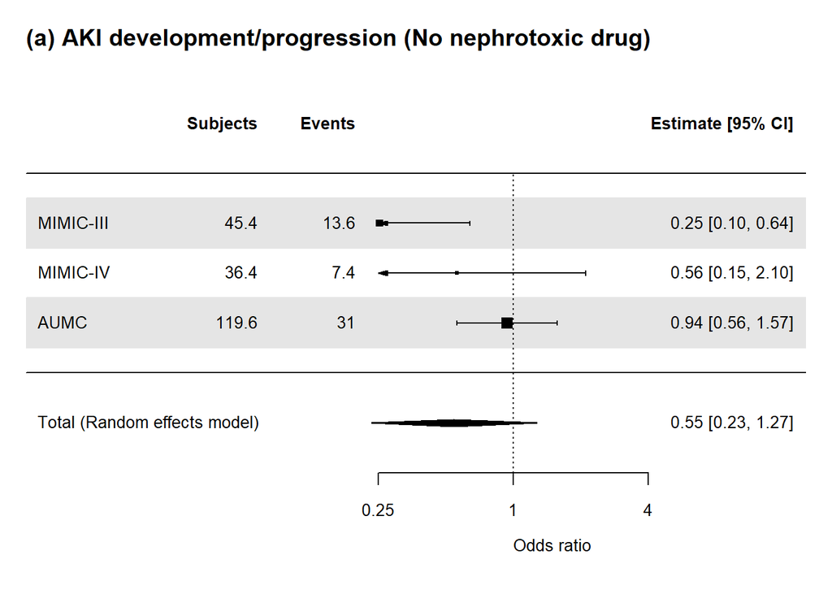

```r
FP2("wgt_man_Ovlp_MIMIC4_nont.rds", FORMULA_ovl2_nt)
FP2("wgt_man_Ovlp_MIMIC3_nont.rds", FORMULA_ovl2_nt)
FP2("wgt_man_Ovlp_AUMC_nont.rds", FORMULA_ovl2_nt)

nont_METADF0 <- rbind(
  readRDS("ORRES_wgt_man_Ovlp_MIMIC3_nont.rds") %>% mutate("dataset"="MIMIC-III"),
  readRDS("ORRES_wgt_man_Ovlp_MIMIC4_nont.rds") %>% mutate("dataset"="MIMIC-IV"),
  readRDS("ORRES_wgt_man_Ovlp_AUMC_nont.rds") %>% mutate("dataset"="AUMC"))
nont_METADF_AKID <- nont_METADF0 %>% subset(outcome=="outcome_KDIGO_inc_or_death")
nont_METADF_AKI <- nont_METADF0 %>% subset(outcome=="outcome_KDIGO_inc")
nont_METADF_HD <- nont_METADF0 %>% subset(outcome=="outcome_new_dial")
nont_METADF_D <- nont_METADF0 %>% subset(outcome=="death_in_7d")
nont_METADF_HDD <- nont_METADF0 %>% subset(outcome=="outcome_HDD_in7d")

nont_METARES_AKID <- rma(yi = Estimate, sei = Std.Error, method = "REML", data = nont_METADF_AKID)
nont_METARES_AKI <-rma(yi = Estimate, sei = Std.Error, method = "REML", data = nont_METADF_AKI)
nont_METARES_HD <- rma(yi = Estimate, sei = Std.Error, method = "REML", data = nont_METADF_HD)
nont_METARES_D <- rma(yi = Estimate, sei = Std.Error, method = "REML", data = nont_METADF_D)
nont_METARES_HDD <- rma(yi = Estimate, sei = Std.Error, method = "REML", data = nont_METADF_HDD)

METAF(nont_METARES_AKI, SCALEA1, SCALEB1, SCALEC1, "(a) AKI development/progression (No nephrotoxic drug)")
```

```r
nont_METARES_AKI
```

```
##
## Random-Effects Model (k = 3; tau^2 estimator: REML)
##
## tau^2 (estimated amount of total heterogeneity): 0.3493 (SE = 0.5679)
## tau (square root of estimated tau^2 value):      0.5910
## I^2 (total heterogeneity / total variability):   63.69%
## H^2 (total variability / sampling variability):  2.75
##
## Test for Heterogeneity:
## Q(df = 2) = 5.9058, p-val = 0.0522
##
## Model Results:
##
## estimate      se     zval    pval    ci.lb   ci.ub
##  -0.6062  0.4312  -1.4058  0.1598  -1.4514  0.2390
##
## ---
## Signif. codes:  0 '***' 0.001 '**' 0.01 '*' 0.05 '.' 0.1 ' ' 1
```

```r
nont_METADF_AKI %>% dplyr::select(dataset, OR, LCI, UCI, 'Pr(>|z|)') %>% remove_rownames()
```

```
##     dataset        OR        LCI       UCI    Pr(>|z|)
## 1 MIMIC-III 0.2532166 0.09979942 0.6424751 0.003836645
## 2  MIMIC-IV 0.5624542 0.15031989 2.1045437 0.392701284
## 3      AUMC 0.9375569 0.56102406 1.5668009 0.805607217
```

__

#### 8c. Backgrounds, outcomes, matching quality, and forrest plot among those **Surgery care unit** at treatment start.

```r
FORMULA_ovl2_surg <- drug01 ~  age_cat + sex + sirs + pre_blood_culture + nt_drug + vasopressor + base_crea + near_crea +  base_KDIGO

#1. overlap-PSM using MIMIC3, "Young"
OVLP(comb_DF2ovl %>% subset(dataset=="MIMIC3"&dep_type2=="Surgery"), FORMULA_ovl2_surg, "Ovlp_MIMIC3_surg", "**Ovlp, MIMIC-III, Surgical unit**")
```

| **Characteristic** | **Ovlp, MIMIC-III, Surgical unit** **I/C** N=22.3<sup>1</sup> | **Ovlp, MIMIC-III, Surgical unit** **NCC** N=22.3<sup>1</sup> | **p-value**<sup>2</sup> |  |
| --- | --- | --- | --- | --- |
| dataset |  |  |  |  |
| MIMIC3 | 22.3 (100.0%) | 22.3 (100.0%) |  |  |
| age_group |  |  | 0.074 |  |
| 18-39 | 0.0 (0.0%) | 1.1 (5.1%) |  |  |
| 40-49 | 4.8 (21.3%) | 1.6 (7.3%) |  |  |
| 50-59 | 2.6 (11.7%) | 2.8 (12.6%) |  |  |
| 60-69 | 4.2 (18.9%) | 5.6 (25.3%) |  |  |
| 70-79 | 4.9 (21.8%) | 7.7 (34.7%) |  |  |
| 80+ | 5.8 (26.2%) | 3.4 (15.0%) |  |  |
| sex |  |  | >0.99 |  |
| Female | 9.0 (40.2%) | 9.0 (40.2%) |  |  |
| Male | 13.3 (59.8%) | 13.3 (59.8%) |  |  |
| bmi | 28.0 (24.9, 35.9) | 27.8 (23.4, 33.9) | 0.37 |  |
| Unknown | 9 | 7 |  |  |
| weight | 82.6 (72.0, 91.5) | 77.7 (62.7, 97.0) | 0.25 |  |
| Unknown | 3 | 2 |  |  |
| ICU type |  |  |  |  |
| Surgery | 22.3 (100.0%) | 22.3 (100.0%) |  |  |
| drug_name |  |  |  |  |
| Imipenem/cilastatin | 22.3 (100.0%) | 0.0 (0.0%) |  |  |
| Imipenem/cilastatin/relebactam | 0.0 (0.0%) | 0.0 (0.0%) |  |  |
| Meropenem | 0.0 (0.0%) | 22.3 (100.0%) |  |  |
| Doripenem | 0.0 (0.0%) | 0.0 (0.0%) |  |  |
| Ertapenem | 0.0 (0.0%) | 0.0 (0.0%) |  |  |
| Overdose in first 24h |  |  | 0.32 |  |
| not_over | 22.3 (100.0%) | 22.2 (99.4%) |  |  |
| over | 0.0 (0.0%) | 0.1 (0.6%) |  |  |
| Relative initiation dose (with near eGFR) | 0.3 (0.2, 0.5) | 0.3 (0.3, 0.5) | 0.27 |  |
| sofa | 5.0 (3.0, 9.0) | 3.0 (2.0, 6.0) | 0.062 |  |
| qsofa | 1.0 (0.0, 1.0) | 1.0 (0.0, 1.0) | 0.50 |  |
| Unknown | 0 | 0 |  |  |
| sirs | 2.0 (1.0, 3.0) | 2.0 (1.0, 3.0) | 0.90 |  |
| pre_blood_culture | 16.8 (75.5%) | 16.8 (75.5%) | >0.99 |  |
| pre nephrotoxic drugs use | 12.6 (56.5%) | 12.6 (56.5%) | >0.99 |  |
| pre vancomycin use | 11.2 (50.3%) | 11.9 (53.5%) | 0.76 |  |
| pre aminoglycosied use | 3.9 (17.5%) | 1.9 (8.6%) | 0.17 |  |
| pre NSAIDs use | 0.7 (3.1%) | 1.9 (8.5%) | 0.30 |  |
| pre contrast agent use | 0.0 (0.0%) | 0.0 (0.0%) |  |  |
| pre vasopressor use | 9.7 (43.4%) | 9.7 (43.4%) | >0.99 |  |
| pre ventilation | 16.9 (76.0%) | 16.5 (74.0%) | 0.82 |  |
| Baseline sCr | 0.9 (0.6, 1.3) | 0.8 (0.6, 1.3) | 0.69 |  |
| sCr at treatment start | 1.2 (0.7, 1.4) | 0.9 (0.7, 1.4) | 0.49 |  |
| AKI stage at treatment start |  |  | 0.083 |  |
| 0 | 20.0 (89.8%) | 19.1 (85.7%) |  |  |
| 1 | 1.3 (6.0%) | 3.2 (14.3%) |  |  |
| 2 | 0.9 (4.2%) | 0.0 (0.1%) |  |  |
| near_eGFR | 63.2 (41.1, 92.3) | 83.5 (45.6, 96.1) | 0.51 |  |
| observation time | 168.0 (168.0, 168.0) | 168.0 (168.0, 168.0) | 0.88 |  |
| Cencsored with drug change | 0.7 (3.2%) | 0.1 (0.5%) | 0.14 |  |
| RRT at treatment start | 0.0 (0.0%) | 0.0 (0.0%) |  |  |
| O, AKI develop/progress | 6.8 (30.7%) | 8.2 (36.8%) | 0.55 |  |
| O, Death | 2.0 (9.2%) | 2.4 (10.7%) | 0.81 |  |
| O, AKI d/p or death | 6.8 (30.7%) | 9.7 (43.3%) | 0.23 |  |
| O, RRT-intervention | 0.6 (2.8%) | 0.3 (1.4%) | 0.57 |  |
| O, Death or RRT-intervention | 2.0 (9.2%) | 2.7 (12.1%) | 0.66 |  |
| total_dose_ICM | 3,500.0 (1,567.9, 4,000.0) | 5,000.0 (3,500.0, 7,000.0) | <0.001 |  |
| total_dose_recabrio | NA (NA, NA) | NA (NA, NA) |  |  |
| Unknown | 22 | 22 |  |  |
| total_dose_erta | NA (NA, NA) | NA (NA, NA) |  |  |
| Unknown | 22 | 22 |  |  |
| total_dose_dori | NA (NA, NA) | NA (NA, NA) |  |  |
| Unknown | 22 | 22 |  |  |
| ini24h_dose_ICM | 500.0 (500.0, 1,000.0) | 1,000.0 (500.0, 1,000.0) | <0.001 |  |
| ini24h_dose_recabrio | NA (NA, NA) | NA (NA, NA) |  |  |
| Unknown | 22 | 22 |  |  |
| ini24h_dose_erta | NA (NA, NA) | NA (NA, NA) |  |  |
| Unknown | 22 | 22 |  |  |
| ini24h_dose_dori | NA (NA, NA) | NA (NA, NA) |  |  |
| Unknown | 22 | 22 |  |  |
| last_drug_in_obs | 168.0 (58.2, 168.0) | 168.0 (97.9, 168.0) | 0.24 |  |

<sup>1</sup> n (%); Median (Q1, Q3)  
<sup>2</sup> NA; Pearson’s X^2: Rao & Scott adjustment; Design-based KruskalWallis test

```r
#2. overlap-PSM using MIMIC4, "Young"
OVLP(comb_DF2ovl %>% subset(dataset=="miiv"&dep_type2=="Surgery"), FORMULA_ovl2_surg, "Ovlp_MIMIC4_surg", "**Ovlp, MIMIC-IV, Surgical unit**")
```

| **Characteristic** | **Ovlp, MIMIC-IV, Surgical unit** **I/C** N=14.3<sup>1</sup> | **Ovlp, MIMIC-IV, Surgical unit** **NCC** N=14.3<sup>1</sup> | **p-value**<sup>2</sup> |  |
| --- | --- | --- | --- | --- |
| dataset |  |  |  |  |
| miiv | 14.3 (100.0%) | 14.3 (100.0%) |  |  |
| age_group |  |  | 0.64 |  |
| 18-39 | 2.0 (13.7%) | 2.2 (15.3%) |  |  |
| 40-49 | 2.8 (19.5%) | 1.5 (10.3%) |  |  |
| 50-59 | 1.9 (13.4%) | 2.6 (18.0%) |  |  |
| 60-69 | 3.8 (26.8%) | 4.1 (28.5%) |  |  |
| 70-79 | 1.0 (6.9%) | 2.6 (18.0%) |  |  |
| 80+ | 2.8 (19.7%) | 1.4 (9.9%) |  |  |
| sex |  |  | >0.99 |  |
| Female | 3.9 (27.4%) | 3.9 (27.4%) |  |  |
| Male | 10.4 (72.6%) | 10.4 (72.6%) |  |  |
| bmi | 30.0 (25.2, 36.2) | 29.0 (24.7, 34.5) | 0.48 |  |
| Unknown | 4 | 4 |  |  |
| weight | 85.0 (76.7, 91.6) | 84.6 (72.4, 100.8) | 0.94 |  |
| Unknown | 1 | 2 |  |  |
| ICU type |  |  |  |  |
| Surgery | 14.3 (100.0%) | 14.3 (100.0%) |  |  |
| drug_name |  |  |  |  |
| Imipenem/cilastatin | 13.3 (93.2%) | 0.0 (0.0%) |  |  |
| Imipenem/cilastatin/relebactam | 1.0 (6.8%) | 0.0 (0.0%) |  |  |
| Meropenem | 0.0 (0.0%) | 14.3 (99.7%) |  |  |
| Doripenem | 0.0 (0.0%) | 0.0 (0.0%) |  |  |
| Ertapenem | 0.0 (0.0%) | 0.0 (0.3%) |  |  |
| Overdose in first 24h |  |  | 0.26 |  |
| not_over | 14.3 (100.0%) | 14.3 (99.9%) |  |  |
| over | 0.0 (0.0%) | 0.0 (0.1%) |  |  |
| Relative initiation dose (with near eGFR) | 0.3 (0.2, 0.3) | 0.3 (0.2, 0.5) | 0.067 |  |
| sofa | 4.0 (2.0, 6.0) | 4.0 (3.0, 7.0) | 0.47 |  |
| qsofa | 1.0 (0.0, 1.0) | 1.0 (0.0, 1.0) | 0.58 |  |
| Unknown | 0 | 0 |  |  |
| sirs | 1.0 (1.0, 2.0) | 1.0 (1.0, 2.0) | 0.79 |  |
| pre_blood_culture | 11.4 (80.0%) | 11.4 (80.0%) | >0.99 |  |
| pre nephrotoxic drugs use | 10.5 (73.2%) | 10.5 (73.2%) | >0.99 |  |
| pre vancomycin use | 10.5 (73.2%) | 10.2 (71.1%) | 0.86 |  |
| pre aminoglycosied use | 0.0 (0.0%) | 0.9 (6.6%) | <0.001 |  |
| pre NSAIDs use | 0.9 (6.5%) | 1.1 (7.5%) | 0.89 |  |
| pre contrast agent use | 0.0 (0.0%) | 0.2 (1.5%) | 0.005 |  |
| pre vasopressor use | 0.0 (0.0%) | 0.0 (0.0%) | <0.001 |  |
| pre ventilation | 0.0 (0.0%) | 0.3 (2.1%) | 0.021 |  |
| Baseline sCr | 0.7 (0.5, 1.5) | 0.8 (0.6, 1.1) | 0.98 |  |
| sCr at treatment start | 1.0 (0.6, 1.6) | 1.0 (0.7, 1.5) | 0.81 |  |
| AKI stage at treatment start |  |  | 0.76 |  |
| 0 | 9.7 (67.7%) | 9.2 (64.1%) |  |  |
| 1 | 2.9 (20.0%) | 3.9 (27.2%) |  |  |
| 2 | 1.8 (12.3%) | 1.2 (8.7%) |  |  |
| near_eGFR | 92.6 (42.0, 117.8) | 81.7 (51.3, 106.4) | 0.58 |  |
| observation time | 168.0 (148.7, 168.0) | 168.0 (168.0, 168.0) | 0.26 |  |
| Cencsored with drug change | 1.0 (6.8%) | 0.0 (0.0%) | 0.30 |  |
| RRT at treatment start | 0.0 (0.0%) | 0.0 (0.0%) |  |  |
| O, AKI develop/progress | 1.0 (6.8%) | 4.0 (28.0%) | 0.085 |  |
| O, Death | 1.0 (6.9%) | 0.5 (3.3%) | 0.46 |  |
| O, AKI d/p or death | 2.0 (13.7%) | 4.3 (29.7%) | 0.20 |  |
| O, RRT-intervention | 0.0 (0.0%) | 0.7 (5.1%) | <0.001 |  |
| O, Death or RRT-intervention | 1.0 (6.9%) | 1.1 (7.8%) | 0.91 |  |
| total_dose_ICM | 2,895.8 (1,229.2, 3,500.0) | 3,395.8 (1,520.8, 4,312.5) | 0.055 |  |
| Unknown | 1 | 0 |  |  |
| total_dose_recabrio | NA (NA, NA) | NA (NA, NA) |  |  |
| Unknown | 13 | 14 |  |  |
| total_dose_erta | NA (NA, NA) | NA (NA, NA) |  |  |
| Unknown | 14 | 14 |  |  |
| total_dose_dori | NA (NA, NA) | NA (NA, NA) |  |  |
| Unknown | 14 | 14 |  |  |
| ini24h_dose_ICM | 500.0 (500.0, 500.0) | 1,000.0 (500.0, 1,000.0) | <0.001 |  |
| Unknown | 1 | 0 |  |  |
| ini24h_dose_recabrio | NA (NA, NA) | NA (NA, NA) |  |  |
| Unknown | 13 | 14 |  |  |
| ini24h_dose_erta | NA (NA, NA) | NA (NA, NA) |  |  |
| Unknown | 14 | 14 |  |  |
| ini24h_dose_dori | NA (NA, NA) | NA (NA, NA) |  |  |
| Unknown | 14 | 14 |  |  |
| last_drug_in_obs | 139.0 (42.0, 168.0) | 146.0 (52.0, 168.0) | 0.42 |  |

<sup>1</sup> n (%); Median (Q1, Q3)  
<sup>2</sup> NA; Pearson’s X^2: Rao & Scott adjustment; Design-based KruskalWallis test